# Procesamiento y análisis de audio

## 1. Introducción

El procesamiento de audios procedentes de entornos reales presenta una elevada variabilidad en términos de calidad, formato, duración y condiciones de captura. Esta heterogeneidad introduce dificultades directas en su uso dentro de sistemas de reconocimiento automático del habla (*Automatic Speech Recognition*, ASR), que requieren señales de entrada consistentes y adecuadamente estructuradas.

Este *notebook* aborda la etapa de preprocesamiento de audio desde un enfoque adaptativo, en el que las transformaciones no se aplican de forma uniforme, sino condicionadas por la calidad acústica de cada señal. Para ello, se combina una fase de análisis, en la que se caracterizan los audios mediante métricas objetivas, con una fase de experimentación y otra de implementación, en la que se define un pipeline final reproducible basado en reglas de decisión.

### 1.1 Objetivo

El objetivo de este *notebook* es diseñar e implementar un *pipeline* de preprocesamiento de audio adaptativo que permita generar señales homogéneas y adecuadas para su uso en sistemas ASR, aplicando transformaciones de forma selectiva en función de la calidad de cada audio.

### 1.2 Contexto dentro del sistema completo

El preprocesamiento de audio constituye la primera etapa del sistema, actuando como interfaz entre los datos de entrada y el módulo de ASR. Su función es adaptar la señal a los requisitos del modelo, reduciendo la variabilidad que podría afectar negativamente al rendimiento del sistema.

El enfoque adoptado prioriza la preservación de la señal original, aplicando únicamente aquellas transformaciones que resultan necesarias según las características acústicas detectadas en cada caso.

### 1.3 Requisitos de esta fase

El desarrollo del *pipeline* de preprocesamiento se rige por una serie de requisitos técnicos que condicionan tanto la fase de análisis como la implementación final.

En primer lugar, se requiere garantizar la homogeneidad de las señales de entrada, transformando todos los audios a un formato común (WAV, mono, 16 kHz) compatible con los modelos ASR y eliminando la variabilidad derivada de los dispositivos de captura.

En segundo lugar, el sistema debe ser robusto frente a condiciones reales, lo que implica caracterizar cada señal mediante métricas objetivas (energía, proporción de silencio, variabilidad, entre otras) que permitan identificar audios problemáticos y definir estrategias de procesamiento específicas.

Asimismo, es necesario gestionar la presencia de silencios tanto en los extremos como en el interior de la señal mediante técnicas de *trimming* y modelos de detección de actividad de voz (*Voice Activity Detection*, VAD), aplicados únicamente cuando las características del audio lo requieran.

Adicionalmente, el proceso debe ser modular y reproducible, estructurando cada etapa del pipeline como componentes independientes que faciliten su análisis, validación y trazabilidad.

Por último, se establece como principio de diseño evitar el sobreprocesamiento de la señal, limitando las transformaciones a aquellas que aportan valor real. Esta decisión se fundamenta en que modelos como Whisper ya incorporan procesamiento interno, por lo que la aplicación indiscriminada de técnicas externas no solo no garantiza mejoras, sino que puede degradar el rendimiento del sistema.

## 2. Preparación del entorno de trabajo

En esta sección se define el entorno técnico necesario para el desarrollo del pipeline de preprocesamiento de audio. Se incluyen la instalación de dependencias, la importación de librerías especializadas y la configuración de rutas de trabajo.

El objetivo es garantizar un entorno reproducible y estructurado que permita ejecutar el flujo completo de procesamiento sobre diferentes conjuntos de datos sin modificaciones en la lógica del código. Asimismo, se establece una organización clara de los directorios que facilita la separación entre datos originales, datos intermedios y resultados finales.

### 2.1 Instalación de dependencias

En este apartado se especifica la instalación de las librerías necesarias para la ejecución del *notebook*. Todas las dependencias se gestionan mediante un archivo `requirements.txt`, lo que permite replicar el entorno de ejecución de forma controlada y consistente.

#### 2.1.1 Configuración del entorno

Este *notebook* requiere la instalación previa de las dependencias del proyecto.

Ejecutar en terminal:

```
pip install -r requirements.txt
```

### 2.2 Importación de librerías

Se importan las librerías necesarias para las distintas fases del procesamiento, incluyendo manipulación de señal, tratamiento de audio, modelos de detección de voz, análisis de datos y visualización.

Se organiza por bloques funcionales para permitir identificar claramente el propósito de cada conjunto de herramientas dentro del *pipeline*, facilitando la mantenibilidad y comprensión del código.

```python
# ==============================
# Manipulación numérica y señales
# ==============================
import numpy as np                          # operaciones numéricas
import librosa                              # procesamiento de audio
from scipy.signal import butter, filtfilt   # filtros de señal

# ==============================
# Procesamiento de audio
# ==============================
import soundfile as sf                      # lectura/escritura de audio
from pydub import AudioSegment              # conversión de formatos (m4a → wav)
import noisereduce as nr                    # reducción de ruido

# ==============================
# Modelos de IA (VAD)
# ==============================
import torch                                # backend para modelos
from silero_vad import load_silero_vad, get_speech_timestamps  # VAD

# ==============================
# Manejo de datos
# ==============================
import pandas as pd                         # datos tabulares

# ==============================
# Visualización y análisis
# ==============================
import matplotlib.pyplot as plt             # visualización
from IPython.display import Audio, display  # reproducción en notebook

# ==============================
# Sistema y utilidades
# ==============================
from pathlib import Path                    # gestión de rutas
import random                               # generación de números aleatorios
```

### 2.3 Gestión y configuración de rutas

En este apartado se define la estructura de directorios del proyecto, estableciendo rutas dinámicas que permiten localizar la raíz del repositorio y acceder a los distintos conjuntos de datos.

Se distinguen tres niveles principales:

- audios originales, sin procesar
- audios estandarizados, tras la unificación de formato
- audios procesados, resultado final del pipeline

Este enfoque permite mantener la trazabilidad completa de los datos a lo largo del proceso, evitando sobrescrituras y facilitando la validación de cada etapa de transformación.

```python
# =========================
# DETECCIÓN DE RAÍZ
# =========================

project_root = Path.cwd()

while not (project_root / "data").exists():
    if project_root == project_root.parent:
        raise FileNotFoundError("No se ha encontrado la carpeta 'data' en la ruta actual ni en sus directorios superiores.")
    project_root = project_root.parent


# =========================
# DIRECTORIOS
# =========================

# Ruta raíz de datos
data_dir = project_root / "data"

# -------------------------
# AUDIO
# -------------------------

audio_dir = data_dir / "audio"

# Audios originales (input)
raw_audio_dir = audio_dir / "raw"

# Audios estandarizados (baseline ASR)
standardized_audio_dir = audio_dir / "standardized"

# Audios procesados (pipeline final)
processed_audio_dir = audio_dir / "processed"

# -------------------------
# CREACIÓN DE CARPETAS
# -------------------------

standardized_audio_dir.mkdir(parents=True, exist_ok=True)
processed_audio_dir.mkdir(parents=True, exist_ok=True)

# (raw normalmente ya existe, no lo creas automáticamente)

# -------------------------
# VERIFICACIÓN
# -------------------------

print("Ruta raíz:", project_root)
print("Raw audio:", raw_audio_dir)
print("Standardized audio:", standardized_audio_dir)
print("Processed audio:", processed_audio_dir)
```

```
Ruta raíz: /Volumes/EXTENSION/GitHub/TFM
Raw audio: /Volumes/EXTENSION/GitHub/TFM/data/audio/raw
Standardized audio: /Volumes/EXTENSION/GitHub/TFM/data/audio/standardized
Processed audio: /Volumes/EXTENSION/GitHub/TFM/data/audio/processed
```

## 3. Análisis inicial del audio original

Antes de definir el *pipeline* de preprocesamiento, se realiza un análisis exploratorio de los audios originales con el objetivo de caracterizar sus propiedades y detectar fuentes de variabilidad que puedan afectar al rendimiento del sistema ASR.

Esta fase permite identificar diferencias en formato, frecuencia de muestreo, número de canales y duración, estableciendo una base objetiva sobre la que definir las transformaciones posteriores. A partir de esta caracterización, se construyen reglas de decisión que permiten adaptar el procesamiento a las necesidades específicas de cada audio.

De este modo, el preprocesamiento deja de plantearse como un conjunto de operaciones uniformes y pasa a estructurarse como un proceso condicionado por las características reales de los datos.

### 3.1 Carga de audios

En este apartado se identifican los archivos de audio disponibles en el directorio de entrada y se construye una estructura inicial basada en sus rutas.

Se adopta un enfoque de carga diferida (*lazy loading*), evitando almacenar las señales completas en memoria en esta fase. Esta decisión permite mejorar la eficiencia del sistema y facilita la escalabilidad del *pipeline* a conjuntos de datos de mayor tamaño, además de permitir aplicar distintas estrategias de carga según la etapa de procesamiento.

```python
# Extensiones válidas
VALID_EXTENSIONS = {".wav", ".mp3", ".m4a", ".flac", ".ogg"}

# Filtrado de archivos de audio
audio_files = [
    f for f in raw_audio_dir.iterdir()
    if f.is_file() and f.suffix.lower() in VALID_EXTENSIONS
]

# Verificación
if len(audio_files) == 0:
    raise FileNotFoundError("No se han encontrado audios válidos en el directorio")

print(f"Se han encontrado {len(audio_files)} audios válidos")

# Dataset
audio_dataset = [{"path": f} for f in audio_files]
```

```
Se han encontrado 200 audios válidos
```

### 3.2 Extracción de metadatos

En esta fase se extraen los metadatos fundamentales de cada archivo de audio, incluyendo frecuencia de muestreo, número de canales, duración y formato. Esta información se incorpora al *dataset* como base para la toma de decisiones posterior.

Se emplea `soundfile` como método principal por su eficiencia en la lectura de metadatos sin necesidad de cargar la señal completa. No obstante, debido a sus limitaciones en formatos comprimidos habituales (como m4a u ogg), se implementa un mecanismo de respaldo mediante `pydub`.

Este enfoque híbrido permite garantizar la compatibilidad con datos reales, manteniendo al mismo tiempo la eficiencia en el procesamiento.

```python
# Análisis inicial de los audios originales para caracterizar sus propiedades básicas
print("=== Información del audio original ===")

# Lista para almacenar la información estructurada de cada audio
rows = []

# Iteramos sobre cada audio del dataset
for item in audio_dataset:

    audio_path = item["path"]

    try:
        # Lectura eficiente de metadatos sin cargar completamente el audio
        info = sf.info(audio_path)

        samplerate = info.samplerate
        channels = info.channels
        duration = info.duration
        format_ = info.format
        subtype = info.subtype

    except:
        # Fallback para formatos no soportados directamente (ej: comprimidos)
        audio = AudioSegment.from_file(audio_path)

        samplerate = audio.frame_rate
        channels = audio.channels
        duration = len(audio) / 1000
        format_ = audio_path.suffix.replace(".", "").upper()
        subtype = "compressed"

    # Se añaden los metadatos al dataset original (enriquecimiento)
    item["samplerate"] = samplerate
    item["channels"] = channels
    item["duration_sec"] = duration
    item["format"] = format_
    item["subtype"] = subtype

    # Se construye una fila para análisis tabular
    rows.append({
        "file": audio_path.name,
        "format": format_,
        "samplerate": samplerate,
        "channels": channels,
        "duration_sec": round(duration, 2)
    })

# Conversión a DataFrame para facilitar el análisis
df_audio = pd.DataFrame(rows)

# Resumen global del dataset
print(f"\nTotal audios: {len(df_audio)}")
print(f"Duración media: {df_audio['duration_sec'].mean():.2f}s")
print(f"Sample rates: {df_audio['samplerate'].unique()}")
print(f"Formatos: {df_audio['format'].unique()}")

# Muestra representativa de los audios
print("\nEjemplo de audios:")
display(df_audio.head(5))
```

```
=== Información del audio original ===

Total audios: 200
Duración media: 14.49s
Sample rates: [48000 44100 16000]
Formatos: <ArrowStringArray>
['M4A', 'OGG']
Length: 2, dtype: str

Ejemplo de audios:
```

|  | file | format | samplerate | channels | duration_sec |
| --- | --- | --- | --- | --- | --- |
| 0 | AUDIO_00001.m4a | M4A | 48000 | 1 | 9.49 |
| 1 | AUDIO_00002.m4a | M4A | 48000 | 1 | 26.47 |
| 2 | AUDIO_00003.m4a | M4A | 48000 | 1 | 13.12 |
| 3 | AUDIO_00004.m4a | M4A | 48000 | 1 | 10.22 |
| 4 | AUDIO_00005.m4a | M4A | 48000 | 1 | 21.59 |

El conjunto de datos inicial está compuesto por un total de 200 audios, con una duración media de 14.49 segundos, lo que refleja un escenario basado en mensajes cortos de carácter conversacional. En cuanto a la frecuencia de muestreo, se observa heterogeneidad en los valores, con presencia de 16 kHz, 44.1 kHz y 48 kHz, lo que justifica la necesidad de una etapa de estandarización para garantizar la coherencia en el procesamiento.

### 3.3 Validación del audio y generación de reglas de procesamiento

Una vez caracterizados los audios, se definen reglas de decisión que permiten determinar de forma automática las transformaciones necesarias en cada caso.

Estas reglas se basan en los metadatos extraídos y constituyen el primer paso hacia un *pipeline* adaptativo, en el que las operaciones de preprocesamiento se aplican de forma selectiva en función de las características de cada señal.

#### 3.3.1 Definición de reglas de decisión

En este apartado se establecen las condiciones que determinan si un audio requiere operaciones como conversión de formato, cambio de frecuencia de muestreo o transformación a mono.

Adicionalmente, se introduce una clasificación básica de calidad basada en la duración de la señal, que permite identificar audios potencialmente problemáticos (demasiado cortos o excesivamente largos) y condiciona la aplicación de técnicas posteriores como VAD.

```python
# Aplicación de reglas de decisión basadas en los metadatos del audio

for item in audio_dataset:

    samplerate = item["samplerate"]
    channels = item["channels"]
    format_ = item["format"]
    duration = item["duration_sec"]

    # Determinación de necesidades de procesamiento
    item["needs_resample"] = samplerate != 16000
    item["needs_mono"] = channels > 1
    item["needs_conversion"] = format_ not in ["WAV", "FLAC"]

    # Clasificación básica de calidad en función de la duración
    if duration < 1:
        item["quality_flag"] = "too_short"
    elif duration > 60:
        item["quality_flag"] = "too_long"
    else:
        item["quality_flag"] = "ok"
```

#### 3.3.2 Análisis de las reglas generadas

Se realiza un análisis agregado de las reglas definidas con el objetivo de evaluar el estado global del *dataset* y cuantificar la proporción de audios que requieren cada tipo de procesamiento.

Este análisis permite validar la coherencia de las reglas establecidas y proporciona una visión general del grado de heterogeneidad del conjunto de datos, información clave para la definición del *pipeline* final.

```python
rows = []

for item in audio_dataset:

    rows.append({
        "file": item["path"].name,
        "needs_resample": item["needs_resample"],
        "needs_mono": item["needs_mono"],
        "needs_conversion": item["needs_conversion"],
        "duration_sec": item["duration_sec"],
        "quality_flag": item["quality_flag"]
    })

df_flags = pd.DataFrame(rows)

# Resumen global del estado del dataset
print("=== Resumen del pipeline ===")
print(f"Total audios: {len(df_flags)}")
print(f"Necesitan resample: {df_flags['needs_resample'].sum()}")
print(f"Necesitan mono: {df_flags['needs_mono'].sum()}")
print(f"Necesitan conversión: {df_flags['needs_conversion'].sum()}")

print("\nDistribución de calidad:")
print(df_flags["quality_flag"].value_counts())

# 🔎 Muestra útil para depuración
print("\nEjemplo de resultados:")
display(df_flags.sample(5, random_state=42))
```

```
=== Resumen del pipeline ===
Total audios: 200
Necesitan resample: 193
Necesitan mono: 2
Necesitan conversión: 200

Distribución de calidad:
quality_flag
ok          194
too_long      6
Name: count, dtype: int64

Ejemplo de resultados:
```

|  | file | needs_resample | needs_mono | needs_conversion | duration_sec | quality_flag |
| --- | --- | --- | --- | --- | --- | --- |
| 95 | AUDIO_00096.m4a | True | False | True | 9.940 | ok |
| 15 | AUDIO_00016.m4a | True | False | True | 7.807 | ok |
| 30 | AUDIO_00031.m4a | True | False | True | 15.679 | ok |
| 158 | AUDIO_00159.m4a | True | False | True | 6.825 | ok |
| 128 | AUDIO_00129.m4a | True | False | True | 11.433 | ok |

De los 200 audios, 193 requieren resampleo para adaptarse a la frecuencia objetivo, 2 necesitan conversión a mono y la totalidad del conjunto precisa conversión de formato a WAV. Estos resultados evidencian una alta heterogeneidad en las condiciones de captura originales, lo que refuerza la necesidad de una etapa de estandarización previa para garantizar una entrada consistente al sistema ASR.

En cuanto a la duración, únicamente 6 audios superan los 60 segundos, mientras que no se observan muestras inferiores a 1 segundo. Esto indica que la mayoría del *dataset* se sitúa dentro de un rango adecuado para el procesamiento, sin presencia de audios excesivamente cortos que puedan comprometer la calidad de la transcripción.

## 4. Estandarización del formato de audio para reconocimiento automático del habla (ASR)

En esta sección se implementa la fase de estandarización del audio, cuyo objetivo es garantizar que todas las señales de entrada cumplan un formato homogéneo y compatible con los sistemas de ASR.

A diferencia de etapas posteriores del *pipeline*, en esta fase las transformaciones se aplican de forma sistemática sobre todos los audios, ya que constituyen un requisito previo para asegurar la consistencia de la señal de entrada. En concreto, se normalizan tres dimensiones fundamentales:

- **Formato de archivo**, mediante conversión a WAV, eliminando dependencias de códecs comprimidos.
- **Estructura de canales**, mediante conversión a mono.
- **Frecuencia de muestreo**, mediante remuestreo a 16 kHz.

El resultado de esta etapa es un conjunto de audios estandarizados que constituyen la señal de referencia (*baseline*) para el resto del *pipeline*.

### 4.1 Conversión y unificación del formato de audio

En este apartado se aplica la transformación de los audios originales a un formato común. Para garantizar la compatibilidad con la diversidad de formatos, la conversión se realiza de forma unificada mediante `pydub`, que permite decodificar tanto formatos comprimidos como no comprimidos sin necesidad de lógica condicional adicional.

Este enfoque evita la complejidad asociada a la gestión de múltiples rutas de procesamiento en función del formato de entrada, priorizando la robustez y la consistencia del *pipeline*.

Durante este proceso, cada audio es transformado a mono, remuestreado a 16 kHz y normalizado en amplitud dentro del rango [-1, 1], generando una representación numérica homogénea adecuada para su posterior procesamiento.

Los audios resultantes se almacenan en disco en formato WAV, y su ruta se incorpora al *dataset*, garantizando la trazabilidad entre los datos originales y su versión estandarizada.

```python
standardized_count = 0
error_count = 0
error_files = []

TARGET_SR = 16000

for item in audio_dataset:

    input_path = item["path"]
    output_path = standardized_audio_dir / f"{input_path.stem}.wav"

    try:
        # Carga SIEMPRE con pydub (soporta todos los formatos)
        audio = AudioSegment.from_file(input_path)

        # Conversión uniforme
        audio = audio.set_channels(1).set_frame_rate(TARGET_SR)

        # Conversión a numpy (int → float32)
        y = np.array(audio.get_array_of_samples()).astype(np.float32)

        # Normalización consistente a [-1, 1]
        max_val = np.max(np.abs(y))
        if max_val > 0:
            y = y / max_val

        # Guardado final
        sf.write(output_path, y, TARGET_SR)

        # Guardamos ruta estandarizada
        item["standardized_path"] = output_path
        standardized_count += 1

    except Exception as e:
        error_count += 1
        error_files.append((input_path.name, str(e)))

# Resumen final
print("=== Estandarización de audio ===")
print(f"Estandarizados correctamente: {standardized_count}")
print(f"Errores: {error_count}")

if error_count > 0:
    print("\nEjemplos de errores:")
    for file, err in error_files[:5]:
        print(f"- {file}: {err}")
```

```
=== Estandarización de audio ===
Estandarizados correctamente: 200
Errores: 0
```

### 4.2 Verificación post‑estandarización

Tras la conversión, se realiza una validación sistemática de los audios generados con el objetivo de comprobar que cumplen los requisitos definidos.

Se verifican aspectos estructurales como la frecuencia de muestreo, el número de canales y el formato, así como propiedades de la señal como la ausencia de saturación (*clipping*). Este proceso permite detectar posibles errores en la transformación y asegurar la consistencia del conjunto de datos antes de aplicar etapas posteriores del *pipeline*.

```python
verification_rows = []

for item in audio_dataset:

    audio_path = item.get("standardized_path")

    try:
        info = sf.info(audio_path)

        samplerate = info.samplerate
        channels = info.channels
        format_ = info.format

        # Carga para verificar amplitud
        y, _ = sf.read(audio_path)
        max_amp = np.max(np.abs(y)) if len(y) > 0 else 0

        verification_rows.append({
            "file": audio_path.name,
            "samplerate": samplerate,
            "channels": channels,
            "format": format_,
            "is_16kHz": samplerate == 16000,
            "is_mono": channels == 1,
            "is_wav": format_ == "WAV",
            "max_amplitude": round(max_amp, 4),
            "within_range": max_amp <= 1.0
        })

    except Exception as e:
        print(f"Error verificando {audio_path.name}: {e}")

df_verification = pd.DataFrame(verification_rows)

# Resumen de cumplimiento
print("=== Verificación post-estandarización ===")
print(f"Total audios: {len(df_verification)}")
print(f"Correctos (16kHz): {df_verification['is_16kHz'].sum()}")
print(f"Correctos (mono): {df_verification['is_mono'].sum()}")
print(f"Correctos (WAV): {df_verification['is_wav'].sum()}")
print(f"Sin clipping: {df_verification['within_range'].sum()}")

# Validación global
all_ok = (
    df_verification["is_16kHz"].all() and
    df_verification["is_mono"].all() and
    df_verification["is_wav"].all() and
    df_verification["within_range"].all()
)

print(f"\nTodos los audios cumplen el formato esperado: {all_ok}")

display(df_verification.head())
```

```
=== Verificación post-estandarización ===
Total audios: 200
Correctos (16kHz): 200
Correctos (mono): 200
Correctos (WAV): 200
Sin clipping: 200

Todos los audios cumplen el formato esperado: True
```

|  | file | samplerate | channels | format | is_16kHz | is_mono | is_wav | max_amplitude | within_range |
| --- | --- | --- | --- | --- | --- | --- | --- | --- | --- |
| 0 | AUDIO_00001.wav | 16000 | 1 | WAV | True | True | True | 1.0 | True |
| 1 | AUDIO_00002.wav | 16000 | 1 | WAV | True | True | True | 1.0 | True |
| 2 | AUDIO_00003.wav | 16000 | 1 | WAV | True | True | True | 1.0 | True |
| 3 | AUDIO_00004.wav | 16000 | 1 | WAV | True | True | True | 1.0 | True |
| 4 | AUDIO_00005.wav | 16000 | 1 | WAV | True | True | True | 1.0 | True |

Tras la etapa de estandarización, la totalidad de los audios cumple con los requisitos definidos para el procesamiento: formato WAV, frecuencia de muestreo de 16 kHz y señal monofónica. Asimismo, no se detectan problemas de clipping, manteniéndose todas las señales dentro del rango dinámico esperado.

Este resultado confirma que la etapa de estandarización se ha aplicado correctamente sobre el conjunto completo de datos, garantizando una entrada homogénea y válida para las fases posteriores del *pipeline*.

### 4.3 Consideraciones sobre la profundidad de bits

Aunque la normalización de profundidad de bits puede ser relevante en determinados contextos de procesamiento de audio, en este trabajo no se considera una transformación prioritaria. Los modelos ASR empleados operan sobre representaciones normalizadas de la señal, por lo que no requieren un control explícito de este parámetro.

En consecuencia, se prioriza la homogeneidad en frecuencia de muestreo, número de canales y rango dinámico, considerados factores más determinantes para el rendimiento del sistema.

## 5. Análisis de calidad de señal (post-estandarización)

Una vez estandarizados los audios, se realiza un análisis de calidad de la señal con el objetivo de caracterizar sus propiedades acústicas reales y detectar posibles comportamientos anómalos.

A diferencia del análisis basado en metadatos, esta etapa se centra en la señal en sí misma, evaluando aspectos como la energía, la presencia de silencio, la variabilidad temporal y la estructura de la señal. Estas métricas permiten identificar audios problemáticos que no pueden detectarse únicamente a partir de información estructural.

El resultado de este análisis constituye la base para la construcción de un *pipeline* adaptativo, en el que las transformaciones de preprocesamiento se aplican de forma selectiva en función de la calidad de cada audio.

### 5.1 Definición de métricas

En este apartado se definen las métricas utilizadas para caracterizar la calidad de la señal.

Se consideran cuatro dimensiones principales:

- **Energía (RMS)**, que mide la intensidad global de la señal
- **Proporción de silencio**, que permite identificar segmentos sin información relevante
- **Tasa de cruces por cero (ZCR)**, asociada a la presencia de ruido o actividad de alta frecuencia
- **Variabilidad energética**, que captura cambios bruscos en la señal y posibles inestabilidades

Adicionalmente, se introduce una métrica específica de **silencio en los extremos**, que permite detectar pausas iniciales y finales, relevantes para la aplicación de técnicas de *trimming*.

Estas métricas permiten describir la señal desde distintas perspectivas, proporcionando una base robusta para la toma de decisiones posterior.

### 5.2 Definición de señal de referencia (*baseline*)

Se define como *baseline* la señal de audio resultante tras la etapa de estandarización, sin la aplicación de técnicas adicionales de mejora.

El objetivo de este apartado es establecer un punto de referencia común que permita evaluar de forma controlada el impacto de las distintas transformaciones aplicadas en los apartados posteriores, analizando la contribución individual de cada técnica al rendimiento del sistema *ASR*.

De este modo, se garantiza que las comparaciones se realicen sobre una entrada homogénea y reproducible, evitando la acumulación de efectos derivados de la aplicación secuencial de múltiples transformaciones.

```python
baseline_dataset = []

loaded_count = 0
error_count = 0
error_files = []

for item in audio_dataset:

    try:
        # Cargamos el audio estandarizado
        y, sr = librosa.load(item["standardized_path"], sr=None)

        baseline_dataset.append({
            "audio_id": item.get("audio_id", item["path"].stem),
            "y": y,
            "sr": sr
        })

        loaded_count += 1

    except Exception as e:
        error_count += 1
        error_files.append((item["standardized_path"].name, str(e)))

# Resumen
print("=== Carga de baseline ===")
print(f"Audios cargados: {loaded_count}")
print(f"Errores: {error_count}")

# Muestra de errores
if error_count > 0:
    print("\nEjemplos de errores:")
    for file, err in error_files[:5]:
        print(f"- {file}: {err}")
```

```
=== Carga de baseline ===
Audios cargados: 200
Errores: 0
```

### 5.3 Cálculo conjunto de métricas

En este apartado se implementa el cálculo conjunto de todas las métricas definidas previamente, aplicadas de forma uniforme sobre la señal estandarizada.

El cálculo se realiza en una única función, lo que permite garantizar coherencia en la extracción de características y evitar fragmentación del proceso. Cada audio queda representado mediante un conjunto de métricas que sintetizan su comportamiento acústico.

Este enfoque facilita el análisis posterior y permite trabajar con una representación estructurada de la señal en lugar de operar directamente sobre la forma de onda.

```python
def compute_audio_quality_metrics(audio_dataset: list[dict]) -> list[dict]:

    results = []

    for item in audio_dataset:

        y = item["y"]
        sr = item["sr"]

        if len(y) == 0:
            results.append({
                "audio_id": item["audio_id"],
                "duration_sec": 0,
                "rms": 0,
                "silence_ratio": 1.0,
                "silence_edges_ratio": 1.0,
                "zcr_mean": 0,
                "energy_var": 0
            })
            continue

        # Duración
        duration_sec = len(y) / sr

        # RMS
        rms = np.sqrt(np.mean(y**2))

        # ZCR
        zcr = librosa.feature.zero_crossing_rate(y)
        zcr_mean = np.mean(zcr)

        # Energía por frames
        frame_length = 2048
        hop_length = 512

        energy = np.array([
            np.sum(np.abs(y[i:i+frame_length])**2)
            for i in range(0, len(y), hop_length)
        ])

        energy_var = np.var(energy) if len(energy) > 0 else 0

        # Umbral de silencio
        threshold = 0.01 * np.max(energy) if len(energy) > 0 else 0
        silence_mask = energy < threshold

        # Silence ratio global
        silence_ratio = np.sum(silence_mask) / len(energy) if len(energy) > 0 else 1.0

        # Silencio en extremos
        start_silence = 0
        for val in silence_mask:
            if val:
                start_silence += 1
            else:
                break

        end_silence = 0
        for val in silence_mask[::-1]:
            if val:
                end_silence += 1
            else:
                break

        silence_edges_ratio = (start_silence + end_silence) / len(energy) if len(energy) > 0 else 1.0

        results.append({
            "audio_id": item["audio_id"],
            "duration_sec": round(duration_sec, 2),
            "rms": round(rms, 5),
            "silence_ratio": round(silence_ratio, 3),
            "silence_edges_ratio": round(silence_edges_ratio, 3),
            "zcr_mean": round(zcr_mean, 5),
            "energy_var": round(energy_var, 5)
        })

    return results
```

### 5.4 Análisis exploratorio

Una vez calculadas las métricas, se realiza un análisis exploratorio con el objetivo de comprender su distribución y detectar patrones relevantes en el conjunto de datos.

Este análisis permite identificar la presencia de valores atípicos (*outliers*), evaluar la dispersión de las métricas y analizar posibles relaciones entre ellas. De este modo, se obtiene una visión global del comportamiento acústico del dataset, fundamental para definir criterios de decisión robustos.

#### 5.4.1 Distribución de métricas

```python
# Calcular métricas sobre señal real (incluye silencio en extremos)
metrics_results = compute_audio_quality_metrics(baseline_dataset)

# Convertir a DataFrame para análisis estructurado
df_metrics = pd.DataFrame(metrics_results)

# Visualización de ejemplo
print("Ejemplo de métricas calculadas:")
display(df_metrics.head(5))

# Resumen del dataset
print("\nResumen del dataset:")
print(f"Total audios: {len(df_metrics)}")
```

```
Ejemplo de métricas calculadas:
```

|  | audio_id | duration_sec | rms | silence_ratio | silence_edges_ratio | zcr_mean | energy_var |
| --- | --- | --- | --- | --- | --- | --- | --- |
| 0 | AUDIO_00001 | 9.49 | 0.12085 | 0.286 | 0.165 | 0.11335 | 3544.248535 |
| 1 | AUDIO_00002 | 26.47 | 0.11544 | 0.338 | 0.175 | 0.10676 | 2252.943604 |
| 2 | AUDIO_00003 | 13.12 | 0.11690 | 0.315 | 0.222 | 0.11592 | 2115.289062 |
| 3 | AUDIO_00004 | 10.22 | 0.10212 | 0.284 | 0.259 | 0.12201 | 986.317017 |
| 4 | AUDIO_00005 | 21.59 | 0.11827 | 0.244 | 0.047 | 0.08194 | 1077.580933 |

```
Resumen del dataset:
Total audios: 200
```

#### 5.4.2 Distribución de métricas

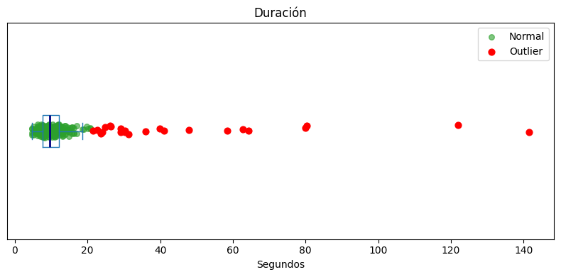

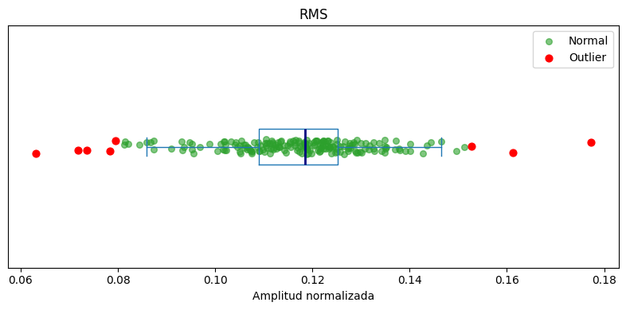

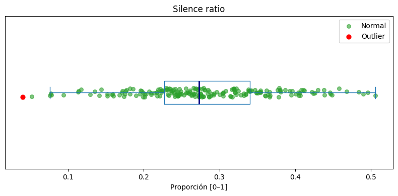

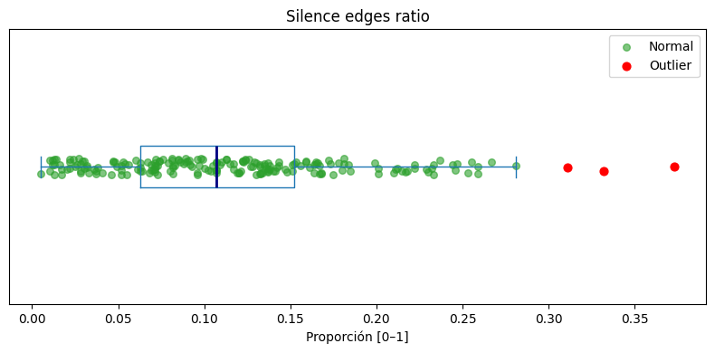

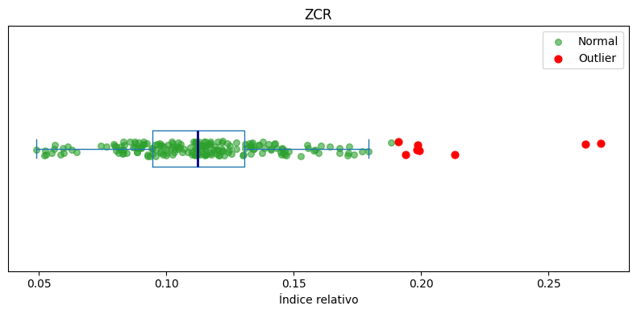

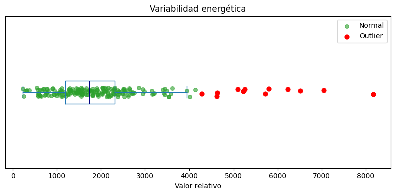

```python
# Lista de métricas a analizar
metrics = ["duration_sec", "rms", "silence_ratio", "silence_edges_ratio", "zcr_mean", "energy_var"]

# Diccionario de etiquetas (nombre + unidad)
metric_labels = {
    "duration_sec": ("Duración", "Segundos"),
    "rms": ("RMS", "Amplitud normalizada"),
    "silence_ratio": ("Silence ratio", "Proporción [0–1]"),
    "silence_edges_ratio": ("Silence edges ratio", "Proporción [0–1]"),
    "zcr_mean": ("ZCR", "Índice relativo"),
    "energy_var": ("Variabilidad energética", "Valor relativo")
}

for metric in metrics:

    data = df_metrics[metric].values

    # Cálculo de outliers (IQR)
    q1 = np.percentile(data, 25)
    q3 = np.percentile(data, 75)
    iqr = q3 - q1

    lower_bound = q1 - 1.5 * iqr
    upper_bound = q3 + 1.5 * iqr

    normal_mask = (data >= lower_bound) & (data <= upper_bound)
    outlier_mask = ~normal_mask

    normal_data = data[normal_mask]
    outlier_data = data[outlier_mask]

    plt.figure(figsize=(8, 4))

    # Boxplot sin outliers
    plt.boxplot(
        normal_data,
        vert=False,
        showfliers=False,
        patch_artist=False,
        boxprops=dict(color="tab:blue"),
        whiskerprops=dict(color="tab:blue"),
        capprops=dict(color="tab:blue"),
        medianprops=dict(color="navy", linewidth=2)
    )

    # Puntos normales
    y_normal = np.ones(len(normal_data))
    jitter_normal = np.random.uniform(-0.03, 0.03, size=len(y_normal))

    plt.scatter(
        normal_data,
        y_normal + jitter_normal,
        color="tab:green",
        alpha=0.6,
        s=30,
        label="Normal"
    )

    # Puntos outliers
    y_outliers = np.ones(len(outlier_data))
    jitter_outliers = np.random.uniform(-0.03, 0.03, size=len(y_outliers))

    plt.scatter(
        outlier_data,
        y_outliers + jitter_outliers,
        color="red",
        s=40,
        label="Outlier"
    )

    # Título y eje correctamente definidos
    title, xlabel = metric_labels[metric]
    plt.title(title)
    plt.xlabel(xlabel)

    plt.yticks([])
    plt.legend()

    plt.tight_layout()
    plt.show()
```

En primer lugar, la distribución de la duración muestra una clara concentración de los audios en torno a los 10–15 segundos, lo que confirma que el *dataset* está compuesto mayoritariamente por mensajes cortos de carácter conversacional. No obstante, se identifican varios valores atípicos con duraciones significativamente superiores, alcanzando incluso más de dos minutos. Estos casos no suponen un problema en sí mismos, pero sí justifican la necesidad de aplicar estrategias específicas, como segmentación mediante VAD, para evitar la acumulación de silencios internos en audios largos.

En cuanto a la energía de la señal, representada mediante el RMS, se observa una distribución relativamente compacta en torno a valores próximos a 0.11–0.13, lo que indica un nivel de grabación bastante homogéneo en la mayoría de los audios. Sin embargo, aparecen algunos valores extremos tanto por defecto como por exceso. Estos casos no deben interpretarse automáticamente como problemáticos, sino como posibles desviaciones respecto al patrón general, que serán tratadas de forma selectiva mediante normalización únicamente cuando exista evidencia de baja energía.

Por su parte, la métrica de silencio en los extremos (*silence edges ratio*) muestra que la mayoría de los audios presentan pausas iniciales y finales relativamente contenidas, aunque existen algunos valores atípicos con proporciones más elevadas. Estos casos justifican la aplicación de técnicas de trimming con preservación de contexto (padding), permitiendo eliminar silencios no informativos sin comprometer la integridad temporal de la señal.

En relación con la tasa de cruces por cero (ZCR), la distribución se mantiene relativamente estable en valores bajos, lo que indica una predominancia de señales limpias con baja presencia de componentes de alta frecuencia. No obstante, se identifican algunos outliers con valores elevados, que pueden estar asociados a ruido o artefactos en la señal, constituyendo candidatos a técnicas de reducción de ruido.

Finalmente, la variabilidad energética muestra una dispersión más amplia, con la mayoría de los audios concentrados en rangos moderados, pero con la presencia de valores extremos significativamente altos. Estos casos pueden indicar inestabilidad en la señal o cambios bruscos de energía, lo que justifica su consideración dentro de la lógica de exclusión o tratamiento específico del *pipeline*.

Este analisis confirma, que aunque el *dataset* presenta un comportamiento mayoritariamente homogéneo, existen casos atípicos en distintas dimensiones que no pueden ser tratados mediante un enfoque uniforme. Esto valida la necesidad del *pipeline* adaptativo, en el que las transformaciones se apliquen de forma selectiva en función de las características acústicas de cada audio.

#### 5.4.3 Relaciones entre métricas

En este apartado se analizan las relaciones entre distintas métricas con el objetivo de identificar posibles dependencias o patrones conjuntos que permitan caracterizar el comportamiento de la señal más allá de su análisis individual.

##### 5.4.3.1 Relación entre RMS y silencio (estructura energética)

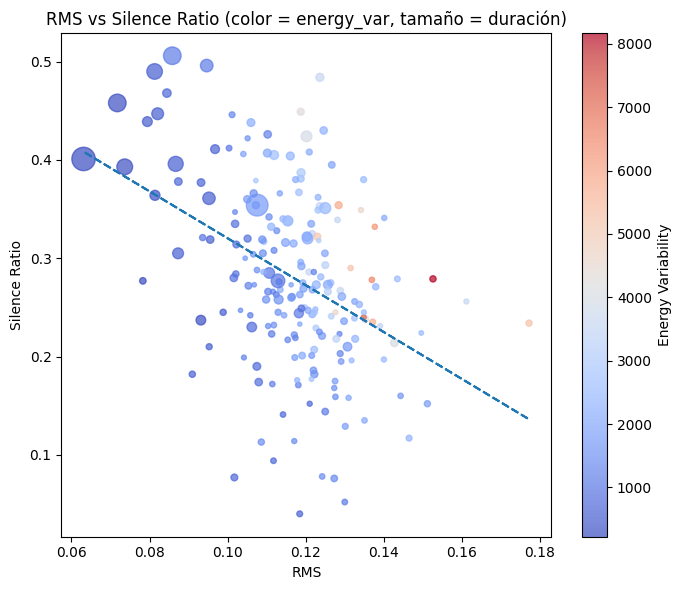

```python
plt.figure(figsize=(7, 6))

scatter = plt.scatter(
    df_metrics["rms"],
    df_metrics["silence_ratio"],
    c=df_metrics["energy_var"],
    cmap="coolwarm",   # azul → rojo
    s=df_metrics["duration_sec"] * 2,
    alpha=0.7
)

# Línea de tendencia (opcional)
z = np.polyfit(df_metrics["rms"], df_metrics["silence_ratio"], 1)
p = np.poly1d(z)
plt.plot(df_metrics["rms"], p(df_metrics["rms"]), linestyle="--")

plt.xlabel("RMS")
plt.ylabel("Silence Ratio")
plt.title("RMS vs Silence Ratio (color = energy_var, tamaño = duración)")
plt.colorbar(scatter, label="Energy Variability")

plt.tight_layout()
plt.show()
```

El análisis conjunto de la relación entre el nivel de energía (RMS) y la proporción de silencio muestra una tendencia inversa moderada entre ambas variables, de modo que los audios con menor energía tienden a presentar una mayor proporción de silencio, mientras que aquellos con mayor energía muestran una reducción de este componente.

La mayor concentración de muestras se sitúa en un rango intermedio de valores de RMS (en torno a 0.10–0.13) y proporciones de silencio moderadas, lo que confirma la existencia de un patrón dominante relativamente estable dentro del conjunto de datos. No obstante, se identifican algunos casos atípicos en regiones extremas, caracterizados por combinaciones de baja energía y alto silencio, así como por valores elevados de variabilidad energética.

La incorporación de la variabilidad energética como dimensión adicional permite observar que los audios más inestables se sitúan fuera del núcleo principal de la distribución. Además, el tamaño de los puntos indica que los audios de mayor duración tienden a concentrar mayores proporciones de silencio, lo que resulta coherente con la acumulación de pausas en grabaciones más largas.

##### 5.4.3.2 Relación entre ZCR y RMS (ruido vs señal estructurada)

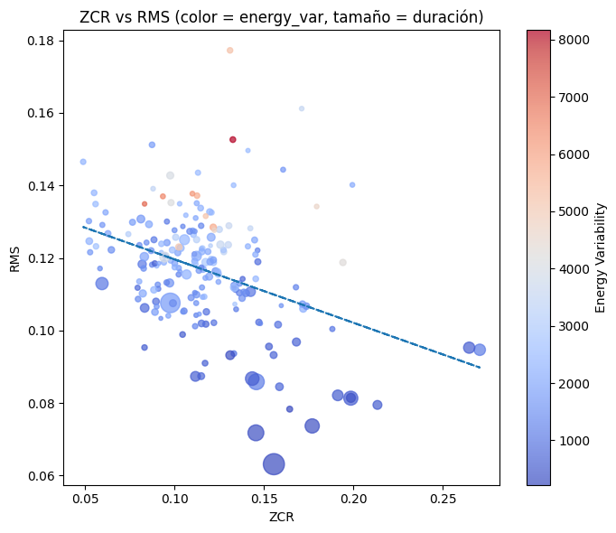

```python
plt.figure(figsize=(7, 6))

scatter = plt.scatter(
    df_metrics["zcr_mean"],
    df_metrics["rms"],
    c=df_metrics["energy_var"],
    cmap="coolwarm",
    s=df_metrics["duration_sec"] * 2,
    alpha=0.7
)

# Línea de tendencia correcta
z = np.polyfit(df_metrics["zcr_mean"], df_metrics["rms"], 1)
p = np.poly1d(z)
plt.plot(df_metrics["zcr_mean"], p(df_metrics["zcr_mean"]), linestyle="--")

plt.xlabel("ZCR")
plt.ylabel("RMS")
plt.title("ZCR vs RMS (color = energy_var, tamaño = duración)")
plt.colorbar(scatter, label="Energy Variability")

plt.tight_layout()
plt.show()
```

El análisis conjunto entre la tasa de cruces por cero (ZCR) y el nivel de energía (RMS) muestra una relación inversa clara, donde valores elevados de ZCR se asocian con niveles más bajos de energía. Este comportamiento es consistente con la presencia de ruido o componentes de alta frecuencia, que incrementan el número de cruces por cero pero no aportan energía significativa a la señal.

La mayor parte de los audios se concentra en un rango intermedio de ZCR (aproximadamente entre 0.08 y 0.13) y valores de RMS estables, lo que indica un comportamiento acústico homogéneo en la mayoría del *dataset*. Sin embargo, se identifican varios casos atípicos con valores elevados de ZCR y bajos niveles de energía, que corresponden a señales potencialmente degradadas o con presencia de ruido.

La dimensión de variabilidad energética permite observar que los audios más inestables no siguen un patrón único, tendiendo a situarse fuera del núcleo principal de la distribución. En cuanto a la duración, no se aprecia una relación claramente definida con el nivel de energía, aunque algunos audios largos aparecen asociados a valores bajos de RMS, lo que podría estar relacionado con la presencia de silencios prolongados.

#### 5.4.4 Identificación de casos extremos

```python
cols = ["audio_id", "duration_sec", "rms", "silence_ratio", "silence_edges_ratio", "zcr_mean", "energy_var"]

# Selección de audios con mayor porcentaje de silencio global
high_silence = df_metrics.sort_values("silence_ratio", ascending=False).head(5)[cols]

# Selección de audios con menor energía (RMS bajo)
low_rms = df_metrics.sort_values("rms", ascending=True).head(5)[cols]

# Selección de audios con mayor ZCR (potencial ruido)
high_zcr = df_metrics.sort_values("zcr_mean", ascending=False).head(5)[cols]

# Selección de audios con mayor variabilidad energética
high_energy = df_metrics.sort_values("energy_var", ascending=False).head(5)[cols]

# Selección de audios con mayor silencio en extremos (NUEVO)
high_silence_edges = df_metrics.sort_values("silence_edges_ratio", ascending=False).head(5)[cols]


print("\nAudios con mayor silencio global:")
display(high_silence)

print("\nAudios con mayor silencio en extremos:")
display(high_silence_edges)

print("\nAudios con menor RMS:")
display(low_rms)

print("\nAudios con mayor ZCR:")
display(high_zcr)

print("\nAudios con mayor variabilidad energética:")
display(high_energy)
```

```
Audios con mayor silencio global:
```

|  | audio_id | duration_sec | rms | silence_ratio | silence_edges_ratio | zcr_mean | energy_var |
| --- | --- | --- | --- | --- | --- | --- | --- |
| 164 | AUDIO_00165 | 80.04 | 0.08584 | 0.506 | 0.036 | 0.14573 | 1100.037109 |
| 173 | AUDIO_00174 | 40.96 | 0.09466 | 0.496 | 0.017 | 0.27058 | 1118.875366 |
| 81 | AUDIO_00082 | 62.74 | 0.08131 | 0.490 | 0.074 | 0.19852 | 583.631592 |
| 176 | AUDIO_00177 | 16.98 | 0.12366 | 0.484 | 0.122 | 0.12567 | 3586.240723 |
| 150 | AUDIO_00151 | 18.52 | 0.08446 | 0.468 | 0.135 | 0.15865 | 724.001099 |

```
Audios con mayor silencio en extremos:
```

|  | audio_id | duration_sec | rms | silence_ratio | silence_edges_ratio | zcr_mean | energy_var |
| --- | --- | --- | --- | --- | --- | --- | --- |
| 78 | AUDIO_00079 | 6.51 | 0.10514 | 0.422 | 0.373 | 0.10470 | 1563.655151 |
| 166 | AUDIO_00167 | 7.02 | 0.14015 | 0.341 | 0.332 | 0.19939 | 2133.700928 |
| 168 | AUDIO_00169 | 8.21 | 0.10039 | 0.412 | 0.311 | 0.18820 | 1048.697632 |
| 175 | AUDIO_00176 | 5.10 | 0.10451 | 0.300 | 0.281 | 0.11384 | 1735.039795 |
| 10 | AUDIO_00011 | 10.15 | 0.11423 | 0.340 | 0.267 | 0.14540 | 2417.766602 |

```
Audios con menor RMS:
```

|  | audio_id | duration_sec | rms | silence_ratio | silence_edges_ratio | zcr_mean | energy_var |
| --- | --- | --- | --- | --- | --- | --- | --- |
| 190 | AUDIO_00191 | 141.50 | 0.06310 | 0.401 | 0.010 | 0.15553 | 223.072693 |
| 39 | AUDIO_00040 | 80.29 | 0.07175 | 0.458 | 0.022 | 0.14549 | 306.931366 |
| 121 | AUDIO_00122 | 64.40 | 0.07365 | 0.393 | 0.041 | 0.17695 | 311.608276 |
| 194 | AUDIO_00195 | 10.96 | 0.07829 | 0.277 | 0.117 | 0.16437 | 242.106873 |
| 159 | AUDIO_00160 | 24.77 | 0.07945 | 0.439 | 0.076 | 0.21340 | 560.891846 |

```
Audios con mayor ZCR:
```

|  | audio_id | duration_sec | rms | silence_ratio | silence_edges_ratio | zcr_mean | energy_var |
| --- | --- | --- | --- | --- | --- | --- | --- |
| 173 | AUDIO_00174 | 40.96 | 0.09466 | 0.496 | 0.017 | 0.27058 | 1118.875366 |
| 179 | AUDIO_00180 | 39.92 | 0.09524 | 0.361 | 0.085 | 0.26467 | 579.377686 |
| 159 | AUDIO_00160 | 24.77 | 0.07945 | 0.439 | 0.076 | 0.21340 | 560.891846 |
| 166 | AUDIO_00167 | 7.02 | 0.14015 | 0.341 | 0.332 | 0.19939 | 2133.700928 |
| 160 | AUDIO_00161 | 26.11 | 0.08140 | 0.364 | 0.124 | 0.19859 | 368.055573 |

```
Audios con mayor variabilidad energética:
```

|  | audio_id | duration_sec | rms | silence_ratio | silence_edges_ratio | zcr_mean | energy_var |
| --- | --- | --- | --- | --- | --- | --- | --- |
| 182 | AUDIO_00183 | 10.20 | 0.15264 | 0.279 | 0.110 | 0.13261 | 8173.837891 |
| 195 | AUDIO_00196 | 6.25 | 0.13490 | 0.240 | 0.107 | 0.08328 | 7048.391602 |
| 171 | AUDIO_00172 | 7.57 | 0.13698 | 0.278 | 0.181 | 0.09352 | 6520.416504 |
| 108 | AUDIO_00109 | 7.12 | 0.13773 | 0.332 | 0.143 | 0.11001 | 6229.419922 |
| 131 | AUDIO_00132 | 12.71 | 0.12846 | 0.354 | 0.148 | 0.12164 | 5803.629395 |

El análisis de casos extremos permite identificar patrones recurrentes en los audios que se desvían del comportamiento general del *dataset*, proporcionando evidencia empírica para justificar decisiones dentro del *pipeline*.

De forma similar, los audios con mayor silencio en los extremos también muestran duraciones variables, aunque con una tendencia a concentrar pausas relevantes al inicio y final de la señal. A diferencia del silencio global, este fenómeno no implica necesariamente una gran cantidad de silencio interno, sino una mala delimitación temporal del contenido útil, lo que justifica la aplicación de técnicas de *trimming* con *padding*.

En cuanto a los audios con menor nivel de energía (RMS), se observa que muchos de ellos corresponden nuevamente a grabaciones de larga duración. Este comportamiento sugiere que la baja energía no se debe únicamente a una señal débil, sino a la presencia de silencios prolongados que reducen el valor medio de la señal. Este matiz es clave, ya que implica que no todos los casos de bajo RMS deben tratarse mediante normalización, sino que deben interpretarse en combinación con otras métricas.

Respecto a los audios con mayor tasa de cruces por cero (ZCR), se identifican casos que coinciden parcialmente con los detectados en otras métricas, especialmente en situaciones de alta variabilidad o presencia de ruido. No obstante, no todos los valores elevados de ZCR implican necesariamente degradación severa de la señal, por lo que su uso como criterio debe considerarse en combinación con el nivel de energía y la variabilidad energética.

Finalmente, los audios con mayor variabilidad energética presentan valores extremos claramente diferenciados del resto del *dataset*, lo que indica cambios bruscos en la señal a lo largo del tiempo. Este comportamiento puede estar asociado tanto a condiciones de grabación inestables como a eventos acústicos abruptos, y justifica su uso como criterio para identificar casos potencialmente problemáticos o candidatos a exclusión parcial del procesamiento.

Este análisis evidencia que muchos de los casos extremos no responden a una única causa, sino a la interacción entre múltiples factores, especialmente la duración del audio y la distribución del silencio.

### 5.5 Identificación de audios problemáticos

A partir del análisis exploratorio, se definen criterios cuantitativos que permiten identificar audios con comportamientos anómalos o potencialmente problemáticos.

Para ello, se establecen umbrales basados en percentiles, complementados con límites absolutos que permiten reforzar la detección en casos críticos. Esta estrategia híbrida permite adaptar los umbrales a la distribución real de los datos sin perder control sobre valores extremos.

En base a estos criterios, se generan *flags* que describen distintas condiciones de la señal, como baja energía, exceso de silencio o alta variabilidad.

Estos *flags* no solo permiten identificar audios problemáticos, sino que constituyen la base para la toma de decisiones dentro del *pipeline*, determinando qué transformaciones deben aplicarse en cada caso.

#### 5.5.1 Definición de umbrales (basados en percentiles)

Para definir los umbrales de decisión del *pipeline*, se emplea un enfoque basado en percentiles del conjunto de datos, evitando el uso de valores arbitrarios. En concreto, se utilizan el percentil 10 para identificar casos de baja energía y el percentil 90 para detectar valores elevados en las distintas métricas, permitiendo capturar de forma consistente los extremos de la distribución.

```python
# Cálculo de percentiles para definir umbrales robustos
p_low_rms = df_metrics["rms"].quantile(0.10)
p_high_silence = df_metrics["silence_ratio"].quantile(0.90)
p_high_silence_edges = df_metrics["silence_edges_ratio"].quantile(0.90)
p_high_zcr = df_metrics["zcr_mean"].quantile(0.90)
p_high_energy = df_metrics["energy_var"].quantile(0.90)

print("Umbrales definidos:")
print(f"RMS bajo (P10): {round(p_low_rms, 5)}")
print(f"Silencio global alto (P90): {round(p_high_silence, 3)}")
print(f"Silencio en extremos alto (P90): {round(p_high_silence_edges, 3)}")
print(f"ZCR alto (P90): {round(p_high_zcr, 5)}")
print(f"Energy_var alto (P90): {round(p_high_energy, 2)}")
```

```
Umbrales definidos:
RMS bajo (P10): 0.09552
Silencio global alto (P90): 0.405
Silencio en extremos alto (P90): 0.218
ZCR alto (P90): 0.15875
Energy_var alto (P90): 3458.83
```

#### 5.5.2 Generación de flags

A partir de los umbrales definidos, se construyen una serie de indicadores binarios (*flags*) que permiten caracterizar cada audio en función de sus propiedades acústicas. Estos indicadores se definen mediante un enfoque híbrido, combinando criterios basados en percentiles con límites absolutos, con el objetivo de garantizar robustez frente a variabilidad en la distribución de los datos y evitar decisiones excesivamente sensibles a valores extremos.

Cada *flag* representa una condición específica de la señal, como baja energía, alta proporción de silencio, presencia de componentes de alta frecuencia o elevada variabilidad energética. Esta representación permite transformar las métricas continuas en una estructura discreta de decisión, facilitando su uso dentro del *pipeline*.

A partir de estos indicadores, se definen las decisiones de procesamiento de forma explícita. Se establece una jerarquía clara, donde la detección de alta variabilidad energética actúa como criterio de exclusión, evitando aplicar transformaciones sobre señales potencialmente inestables. En el resto de casos, se combinan condiciones para determinar la aplicación selectiva de técnicas como filtrado paso alto, reducción de ruido, normalización, *trimming* o segmentación mediante VAD.

```python
# Flags (detección híbrida: percentiles + límites absolutos)

df_metrics["low_energy"] = (
    (df_metrics["rms"] < p_low_rms) |
    (df_metrics["rms"] < 0.09)   # límite mínimo seguro
)

df_metrics["high_silence"] = (
    (df_metrics["silence_ratio"] > p_high_silence) |
    (df_metrics["silence_ratio"] > 0.30)
)

df_metrics["high_silence_edges"] = (
    (df_metrics["silence_edges_ratio"] > p_high_silence_edges) |
    (df_metrics["silence_edges_ratio"] > 0.18)
)

df_metrics["high_zcr"] = (
    (df_metrics["zcr_mean"] > p_high_zcr) |
    (df_metrics["zcr_mean"] > 0.11)
)

df_metrics["high_energy_var"] = (
    (df_metrics["energy_var"] > p_high_energy) |
    (df_metrics["energy_var"] > 2000)   # umbral empírico inicial
)


# Decisiones de procesamiento

# 1. NO procesar (prioridad absoluta)
df_metrics["skip_processing"] = df_metrics["high_energy_var"]

# 2. High-pass (filtro base)
df_metrics["apply_highpass"] = ~df_metrics["high_energy_var"]

# 3. Denoise (ruido claro y señal estable)
df_metrics["apply_denoise"] = (
    df_metrics["high_zcr"] &
    ~df_metrics["low_energy"] &
    ~df_metrics["high_energy_var"]
)

# 4. Normalización (señal débil sin ruido)
df_metrics["apply_rms"] = (
    df_metrics["low_energy"] &
    ~df_metrics["high_zcr"] &
    ~df_metrics["high_energy_var"]
)

# 5. VAD (definir primero)
df_metrics["needs_vad"] = (
    df_metrics["high_silence"] &
    (df_metrics["duration_sec"] > 30)
)

# 6. Trimming (ya puede usar needs_vad)
df_metrics["apply_trim"] = (
    df_metrics["high_silence_edges"] &
    ~df_metrics["needs_vad"] &
    ~df_metrics["high_energy_var"]
)
```

#### 5.5.3 Resumen de resultados

```python
print("\n=== Resumen de decisiones de procesamiento ===")

print(f"Total audios: {len(df_metrics)}")

print(f"Baseline (sin procesar): {df_metrics['skip_processing'].sum()}")
print(f"High-pass (filtro base): {df_metrics['apply_highpass'].sum()}")
print(f"Denoise (ruido): {df_metrics['apply_denoise'].sum()}")
print(f"Normalización RMS (baja energía): {df_metrics['apply_rms'].sum()}")
print(f"Trimming (silencio en extremos): {df_metrics['apply_trim'].sum()}")
print(f"VAD (silencio estructural): {df_metrics['needs_vad'].sum()}")


print("\nEjemplo de decisiones por audio:")
display(df_metrics[
    [
        "audio_id",
        "low_energy",
        "high_silence",
        "high_silence_edges",
        "high_zcr",
        "high_energy_var",
        "skip_processing",
        "apply_highpass",
        "apply_denoise",
        "apply_rms",
        "apply_trim",
        "needs_vad"
    ]
].head(10))
```

```
=== Resumen de decisiones de procesamiento ===
Total audios: 200
Baseline (sin procesar): 86
High-pass (filtro base): 114
Denoise (ruido): 47
Normalización RMS (baja energía): 1
Trimming (silencio en extremos): 20
VAD (silencio estructural): 13

Ejemplo de decisiones por audio:
```

|  | audio_id | low_energy | high_silence | high_silence_edges | high_zcr | high_energy_var | skip_processing | apply_highpass | apply_denoise | apply_rms | apply_trim | needs_vad |
| --- | --- | --- | --- | --- | --- | --- | --- | --- | --- | --- | --- | --- |
| 0 | AUDIO_00001 | False | False | False | True | True | True | False | False | False | False | False |
| 1 | AUDIO_00002 | False | True | False | False | True | True | False | False | False | False | False |
| 2 | AUDIO_00003 | False | True | True | True | True | True | False | False | False | False | False |
| 3 | AUDIO_00004 | False | False | True | True | False | False | True | True | False | True | False |
| 4 | AUDIO_00005 | False | False | False | False | False | False | True | False | False | False | False |
| 5 | AUDIO_00006 | False | False | True | True | True | True | False | False | False | False | False |
| 6 | AUDIO_00007 | False | False | False | True | True | True | False | False | False | False | False |
| 7 | AUDIO_00008 | False | False | False | True | True | True | False | False | False | False | False |
| 8 | AUDIO_00009 | False | False | True | True | True | True | False | False | False | False | False |
| 9 | AUDIO_00010 | False | False | False | False | True | True | False | False | False | False | False |

El análisis de los *flags* generados muestra que una parte significativa de los audios (86 de 200) se clasifican como no procesables debido a una alta variabilidad energética, lo que indica la presencia de señales inestables o potencialmente degradadas. Este comportamiento justifica la inclusión de un criterio de exclusión dentro del *pipeline*, evitando la aplicación de transformaciones que podrían amplificar artefactos.

En los audios restantes, el filtrado paso alto se aplica de forma mayoritaria (114 casos), actuando como una operación base orientada a mejorar la calidad de la señal en el rango de frecuencias relevante para el habla. La reducción de ruido se activa en 47 audios, asociados a valores elevados de ZCR, lo que sugiere la presencia de componentes de alta frecuencia o ruido.

La normalización RMS presenta una incidencia muy baja (1 caso), lo que indica que la mayoría de los audios ya presentan niveles de energía adecuados, confirmando la homogeneidad observada previamente en la distribución del RMS.

Por su parte, el *trimming* se aplica en 20 audios, principalmente en aquellos con presencia de silencios en los extremos, mientras que la segmentación mediante VAD se activa en 13 casos, todos ellos asociados a audios largos con alta proporción de silencio estructural.

Estos resultados reflejan un comportamiento coherente con el análisis exploratorio previo, donde la mayoría de los audios presentan condiciones adecuadas, mientras que un subconjunto reducido requiere transformaciones específicas.

### 5.6 Conclusiones el análisis de calidad de señal

El análisis realizado permite confirmar que el *dataset* presenta, en general, una calidad adecuada y un comportamiento relativamente homogéneo, con la mayoría de los audios concentrados en rangos estables de energía, silencio y actividad espectral.

No obstante, se identifican casos atípicos asociados principalmente a audios de larga duración, acumulación de silencio y elevada variabilidad energética, lo que justifica la necesidad de un tratamiento selectivo. Asimismo, se observa que las condiciones relevantes no dependen de una única métrica, sino de la combinación de varias características acústicas.

A partir de este análisis, se definen umbrales basados en percentiles y se construye una lógica adaptativa mediante *flags*, permitiendo aplicar transformaciones únicamente cuando existe evidencia de su necesidad. Este enfoque evita el sobreprocesamiento y establece una base sólida para el diseño del *pipeline* de preprocesamiento orientado a sistemas ASR.

## 6. Optimización de la señal para reconocimiento del habla

En esta sección se abordan distintas técnicas de procesamiento de señal orientadas a mejorar la calidad de los audios para su uso en sistemas de reconocimiento automático del habla (*ASR*).

A diferencia de la etapa de estandarización, centrada en garantizar la consistencia del formato de entrada, en esta fase se analiza el efecto de diversas transformaciones sobre la señal con el objetivo de mejorar su inteligibilidad y su robustez frente a condiciones adversas propias de entornos no controlados, como la presencia de ruido de fondo o la variabilidad en la intensidad.

El objetivo de este bloque es evaluar de forma controlada el impacto de cada técnica sobre la señal, identificando aquellas transformaciones que aportan mejoras reales sin introducir efectos no deseados.

Dado que estas transformaciones pueden tener efectos tanto positivos como negativos sobre el rendimiento del sistema, se adopta un enfoque experimental basado en la comparación sistemática de distintas configuraciones respecto a una señal de referencia (*baseline*), correspondiente a los audios estandarizados sin procesamiento adicional.

### 6.2 Eliminación de regiones no informativas en los extremos del audio

En este apartado se aplica un recorte de silencios en los extremos de la señal de audio, con el objetivo de eliminar segmentos iniciales y finales que no contienen información relevante.

El objetivo de esta operación es reducir la duración del audio y mejorar la eficiencia del procesamiento posterior, evitando que el sistema *ASR* procese tramos sin contenido útil.

El recorte se realiza en función de un umbral de energía definido mediante el parámetro `top_db`, que determina el nivel a partir del cual una región de la señal se considera silencio.

Dado que la elección de este umbral influye directamente en la cantidad de señal eliminada, se evalúan distintos valores de `top_db` con el fin de analizar su impacto sobre la señal y seleccionar la configuración más adecuada.

#### 6.2.1 *Trimming*

En este bloque se implementa la operación de *trimming* de forma selectiva, aplicándola únicamente sobre aquellos audios que presentan una proporción significativa de silencio en los extremos. Esta decisión se basa en los indicadores previamente calculados, evitando aplicar la transformación sobre señales que ya presentan una estructura temporal adecuada.

Con el objetivo de analizar el impacto del umbral de detección de silencio, se evalúan distintos valores del parámetro `top_db`, generando múltiples versiones de la señal que permiten estudiar el equilibrio entre eliminación de segmentos no informativos y preservación del contenido de voz.

```python
# Aplicación de trim SOLO a audios que cumplen condición

# Distintos valores de top_db
top_db_values = [20, 30, 40]

trim_results = {}

# Selección de audios donde tiene sentido aplicar trimming
selected_trim_ids = set(df_metrics[df_metrics["apply_trim"]]["audio_id"])

# Control: si no hay audios, no ejecutar
if len(selected_trim_ids) == 0:
    print("No hay audios candidatos a aplicar trimming.")

else:

    for top_db in top_db_values:

        trim_dataset = []

        for item in baseline_dataset:

            # Filtrado por flag → solo audios relevantes
            if item["audio_id"] not in selected_trim_ids:
                continue

            y = item["y"]
            sr = item["sr"]

            # Aplicación de trim: eliminación de silencios en extremos
            y_trim, _ = librosa.effects.trim(y, top_db=top_db)

            trim_dataset.append({
                "audio_id": item["audio_id"],
                "y": y_trim,
                "sr": sr
            })

        # Se agrupan los resultados por configuración
        trim_results[top_db] = trim_dataset

        print(f"Trim aplicado con top_db = {top_db} sobre {len(trim_dataset)} audios")
```

```
Trim aplicado con top_db = 20 sobre 20 audios
Trim aplicado con top_db = 30 sobre 20 audios
Trim aplicado con top_db = 40 sobre 20 audios
```

##### 6.2.1.1 Evaluación del *trim*

En este subapartado se evalúa el impacto de la eliminación de silencios en los extremos de la señal mediante la técnica de *trimming*, considerando distintos valores del parámetro `top_db`.

El análisis se realiza sobre una muestra representativa de audios, permitiendo comparar la señal original con las versiones recortadas. Para ello, se adopta un enfoque basado en métricas cuantitativas, inspección visual de la señal y evaluación cualitativa mediante escucha.

El objetivo es determinar el nivel de recorte que permite eliminar regiones no informativas sin afectar al contenido de voz, identificando la configuración más adecuada para su integración en el *pipeline*.

###### 6.2.1.1.1 Métricas (cuantitativo)

```python
# Selección de muestra SOLO dentro de los audios con trimming

# Control: si no hay audios, no ejecutar
if len(selected_trim_ids) == 0:
    print("No hay audios para analizar trimming.")

else:

    # Selección de una muestra de audios para análisis comparativo
    NUM_SAMPLES = 2

    # Fijamos semilla para garantizar reproducibilidad
    random.seed(42)

    # Lista de IDs válidos
    valid_ids = list(selected_trim_ids)

    # Seleccionamos IDs aleatorios
    sampled_ids = random.sample(valid_ids, min(NUM_SAMPLES, len(valid_ids)))

    # Frecuencia de muestreo asumida tras estandarización
    sr = 16000

    # Lista para almacenar métricas de cada configuración
    rows = []

    # Iteramos sobre cada audio seleccionado
    for audio_id in sampled_ids:

        # Señal original
        base = next(item["y"] for item in baseline_dataset if item["audio_id"] == audio_id)

        # Cálculo de duración original
        duration_base = len(base) / sr

        # Evaluación de cada configuración de trimming
        for top_db in top_db_values:

            # Buscar señal trim correspondiente
            y_trim = next(item["y"] for item in trim_results[top_db] if item["audio_id"] == audio_id)

            # Duración tras trimming
            duration_trim = len(y_trim) / sr

            # Porcentaje de reducción
            reduction = (1 - len(y_trim) / len(base)) * 100

            # Registro
            rows.append({
                "audio_id": audio_id,
                "config": f"Trim top_db={top_db}",
                "duration_base": round(duration_base, 2),
                "duration_trim": round(duration_trim, 2),
                "reduction_%": round(reduction, 2)
            })

    # Conversión a DataFrame
    df_metrics_trim = pd.DataFrame(rows)

    # Visualización
    display(df_metrics_trim)
```

|  | audio_id | config | duration_base | duration_trim | reduction_% |
| --- | --- | --- | --- | --- | --- |
| 0 | AUDIO_00148 | Trim top_db=20 | 13.20 | 10.78 | 18.33 |
| 1 | AUDIO_00148 | Trim top_db=30 | 13.20 | 10.94 | 17.12 |
| 2 | AUDIO_00148 | Trim top_db=40 | 13.20 | 10.94 | 17.12 |
| 3 | AUDIO_00061 | Trim top_db=20 | 9.75 | 7.71 | 20.89 |
| 4 | AUDIO_00061 | Trim top_db=30 | 9.75 | 8.54 | 12.35 |
| 5 | AUDIO_00061 | Trim top_db=40 | 9.75 | 9.15 | 6.11 |

###### 6.2.1.1.2 Señal (visual)

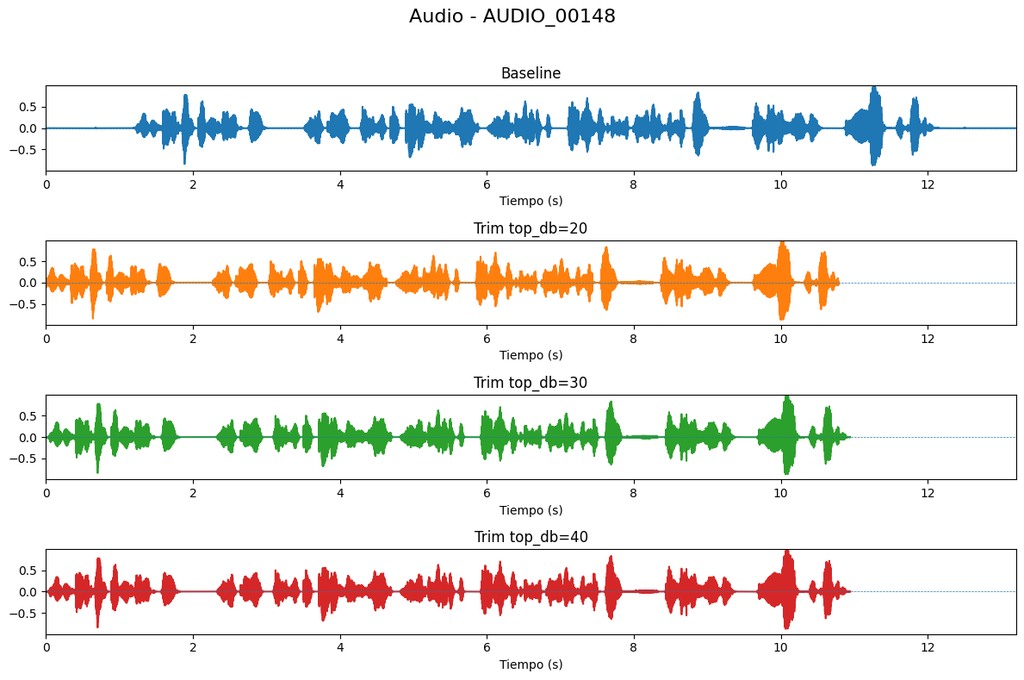

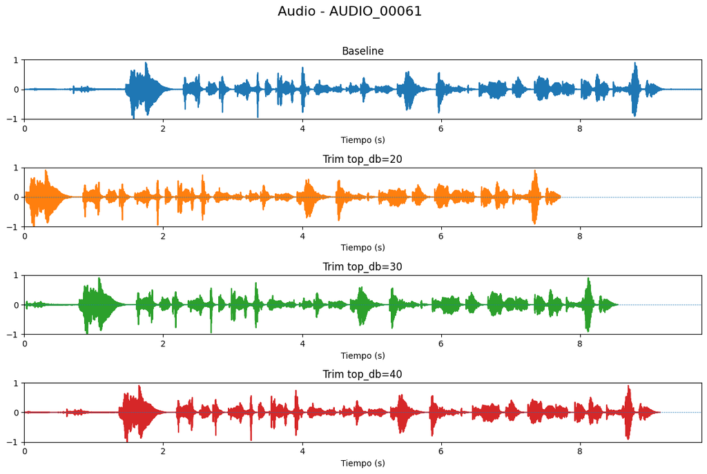

```python
# Comparación visual entre señal original y versiones con trimming

if len(selected_trim_ids) == 0:
    print("No hay audios para visualización de trimming.")

else:

    for audio_id in sampled_ids:

        # Señal base
        base = next(item["y"] for item in baseline_dataset if item["audio_id"] == audio_id)

        # Señales recortadas
        trims = {
            f"Trim top_db={top_db}":
            next(item["y"] for item in trim_results[top_db] if item["audio_id"] == audio_id)
            for top_db in top_db_values
        }

        signals = {
            "Baseline": base,
            **trims
        }

        plt.figure(figsize=(12, 8))
        plt.suptitle(f"Audio - {audio_id}", fontsize=16)

        max_time = len(base) / sr
        y_max = max(np.max(np.abs(y)) for y in signals.values())

        colors = plt.cm.tab10(range(len(signals)))

        for i, ((label, y), color) in enumerate(zip(signals.items(), colors), start=1):

            time_axis = np.arange(len(y)) / sr

            plt.subplot(len(signals), 1, i)
            plt.plot(time_axis, y, color=color)

            plt.xlim(0, max_time)
            plt.ylim(-y_max, y_max)

            plt.axhline(0, linestyle='--', linewidth=0.5)
            plt.title(label)
            plt.xlabel("Tiempo (s)")

        plt.tight_layout(rect=[0, 0, 1, 0.96])
        plt.show()
```

###### 6.2.1.1.3 Escucha (cualitativo)

```python
# Reproducción de señales para evaluación cualitativa del trimming

# Control: si no hay audios, no ejecutar
if len(selected_trim_ids) == 0:
    print("No hay audios para reproducción de trimming.")

else:

    for audio_id in sampled_ids:

        # Señal base
        base = next(item["y"] for item in baseline_dataset if item["audio_id"] == audio_id)

        # Frecuencia de muestreo
        sr = next(item["sr"] for item in baseline_dataset if item["audio_id"] == audio_id)

        # Señales tras trimming
        trims = {
            f"Trim top_db={top_db}":
            next(
                (item["y"] for item in trim_results[top_db] if item["audio_id"] == audio_id),
                None
            )
            for top_db in top_db_values
        }

        # Filtrar posibles valores None
        trims = {k: v for k, v in trims.items() if v is not None}

        # Si no hay señales válidas, se omite
        if len(trims) == 0:
            continue

        # Diccionario final
        signals = {
            "Baseline": base,
            **trims
        }

        # Información del audio
        duration_base = len(base) / sr

        print(f"\n========================")
        print(f"Audio - {audio_id} (duración: {round(duration_base, 2)}s)")
        print(f"========================\n")

        # Reproducción
        for label, y in signals.items():
            duration = len(y) / sr
            print(f"{label} (duración: {round(duration, 2)}s)")
            display(Audio(y, rate=sr))
```

```
========================
Audio - AUDIO_00148 (duración: 13.2s)
========================

Baseline (duración: 13.2s)
```

[interactive chart not shown]

```
Trim top_db=20 (duración: 10.78s)
```

[interactive chart not shown]

```
Trim top_db=30 (duración: 10.94s)
```

[interactive chart not shown]

```
Trim top_db=40 (duración: 10.94s)
```

[interactive chart not shown]

```
========================
Audio - AUDIO_00061 (duración: 9.75s)
========================

Baseline (duración: 9.75s)
```

[interactive chart not shown]

```
Trim top_db=20 (duración: 7.71s)
```

[interactive chart not shown]

```
Trim top_db=30 (duración: 8.54s)
```

[interactive chart not shown]

```
Trim top_db=40 (duración: 9.15s)
```

[interactive chart not shown]

Desde el punto de vista cualitativo, la configuración con `top_db=20` resulta la más efectiva en los casos analizados, al eliminar de forma clara los silencios en los extremos y generar una señal más compacta. En los ejemplos evaluados, no se aprecian pérdidas perceptibles de información relevante ni degradación audible del discurso.

##### 6.2.1.2 Conclusiones del *trim*

A partir de la comparación realizada, se observa que valores bajos de `top_db` producen un recorte más agresivo, eliminando una mayor proporción de señal en los extremos, mientras que valores más elevados generan un comportamiento más conservador, manteniendo gran parte de los silencios originales.

El análisis visual confirma que el recorte se concentra en regiones de baja energía situadas en los extremos, siendo más pronunciado cuanto menor es el valor de `top_db`. Por su parte, la evaluación auditiva muestra que, en los ejemplos analizados, la configuración de 20 dB elimina de forma efectiva los silencios sin introducir degradación perceptible ni pérdida de información relevante.

En base a estos resultados, se selecciona `top_db=20` como valor óptimo en este caso, al proporcionar la mayor reducción de regiones no informativas manteniendo la integridad de la señal de voz.

#### 6.2.2 *Trim* + *Padding*

En este apartado se evalúa la incorporación de un margen de silencio artificial en los extremos de la señal tras la aplicación del trim, con el objetivo de compensar la posible pérdida de contexto temporal generada por el recorte de silencios. Esta operación se introduce como una etapa posterior y complementaria al *trimming*, aplicándose únicamente sobre aquellas señales que han sido previamente modificadas.

Se establece un valor de 300 ms de forma empírica, como un compromiso entre la eliminación efectiva de segmentos no informativos y la conservación de suficiente contexto temporal, evitando introducir silencios excesivos que puedan afectar a la eficiencia del procesamiento. Este valor permite suavizar los límites de la señal sin alterar de forma significativa su duración global.

El objetivo de esta operación es evitar cortes bruscos al inicio y al final del audio, proporcionando un contexto temporal adicional que puede resultar beneficioso para el sistema ASR, especialmente en la correcta delimitación de los segmentos de voz. De este modo, se mejora la estabilidad de la señal en sus extremos, reduciendo el riesgo de pérdida de información relevante asociada a transiciones suaves en el habla.

```python
# Aplicación de padding tras trim

# Configuración del pipeline
SELECTED_TOP_DB = 20
PADDING_MS = 300
TARGET_SR = 16000

# Conversión de milisegundos a muestras
padding_samples = int((PADDING_MS / 1000) * TARGET_SR)

trim_pad_dataset = []

# Control: si no hay audios, no ejecutar
if len(selected_trim_ids) == 0:
    print("No hay audios para visualización de trimming.")

else:

    processed_count = 0

    for item in trim_results[SELECTED_TOP_DB]:

        y = item["y"]
        sr = item["sr"]

        # Generación de silencio (padding)
        pad = np.zeros(padding_samples)

        # Aplicación de padding al inicio y al final
        y_pad = np.concatenate([pad, y, pad])

        trim_pad_dataset.append({
            "audio_id": item["audio_id"],
            "y": y_pad,
            "sr": sr
        })

        processed_count += 1

    # Resumen
    print("=== Trim + Padding ===")
    print(f"Audios procesados: {processed_count}")
```

```
=== Trim + Padding ===
Audios procesados: 20
```

##### 6.2.2.1 Evaluación de *trim* + *padding*

En este subapartado se evalúa el efecto de la combinación de *trimming* con la adición de *padding* en los extremos de la señal, con el objetivo de analizar su impacto sobre la duración y la estructura temporal del audio.

El análisis se realiza sobre una muestra representativa de audios, combinando métricas cuantitativas, inspección visual y evaluación auditiva.

El objetivo es determinar si la incorporación de *padding* permite mejorar la estabilidad de la señal en los extremos sin comprometer la reducción de silencios obtenida en la fase de recorte.

###### 6.2.2.1.1 Métricas (cuantitativo)

```python
# Selección de una muestra de audios para comparar baseline, trimming y padding

NUM_SAMPLES = 2

# Semilla para reproducibilidad
random.seed(42)

# Selección de audios donde se aplica trimming (y padding)
selected_trim_ids = set(df_metrics[df_metrics["apply_trim"]]["audio_id"])

# Control: si no hay audios, no ejecutar
if len(selected_trim_ids) == 0:
    print("No hay audios para comparar trim + padding.")

else:

    # Selección de muestra sobre audios relevantes
    sampled_ids = random.sample(list(selected_trim_ids), min(NUM_SAMPLES, len(selected_trim_ids)))

    rows = []

    for audio_id in sampled_ids:

        # Señal base
        base = next(item["y"] for item in baseline_dataset if item["audio_id"] == audio_id)

        # Señal tras trimming
        trim = next(
            (item["y"] for item in trim_results[SELECTED_TOP_DB] if item["audio_id"] == audio_id),
            None
        )

        # Señal tras trim + padding
        trim_pad = next(
            (item["y"] for item in trim_pad_dataset if item["audio_id"] == audio_id),
            None
        )

        # Si falta alguna etapa, saltamos
        if trim is None or trim_pad is None:
            continue

        # Frecuencia de muestreo
        sr = next(item["sr"] for item in baseline_dataset if item["audio_id"] == audio_id)

        # Duración baseline
        duration_base = len(base) / sr

        # Duración tras trimming
        duration_trim = len(trim) / sr
        reduction_trim = (1 - len(trim) / len(base)) * 100

        # Duración tras trimming + padding
        duration_trim_pad = len(trim_pad) / sr
        variation_pad = (len(trim_pad) - len(base)) / len(base) * 100

        # Registro de resultados
        rows.append({
            "audio_id": audio_id,
            "baseline_sec": round(duration_base, 2),
            "trim_sec": round(duration_trim, 2),
            "trim_reduction_%": round(reduction_trim, 2),
            "trim_pad_sec": round(duration_trim_pad, 2),
            "pad_variation_%": round(variation_pad, 2)
        })

    # Conversión a DataFrame
    df_metrics_trim_pad = pd.DataFrame(rows)

    # Visualización
    display(df_metrics_trim_pad)
```

|  | audio_id | baseline_sec | trim_sec | trim_reduction_% | trim_pad_sec | pad_variation_% |
| --- | --- | --- | --- | --- | --- | --- |
| 0 | AUDIO_00148 | 13.20 | 10.78 | 18.33 | 11.38 | -13.78 |
| 1 | AUDIO_00061 | 9.75 | 7.71 | 20.89 | 8.31 | -14.73 |

###### 6.2.2.1.2 Señal (visual)

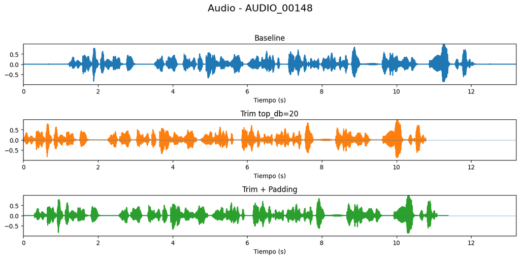

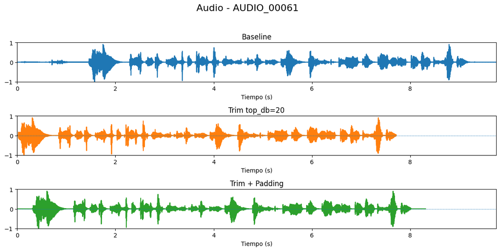

```python
# Comparación visual entre señal original, trimming y trimming + padding

# Control: si no hay audios, no ejecutar
if len(selected_trim_ids) == 0:
    print("No hay audios para visualización de trim + padding.")

else:

    for audio_id in sampled_ids:

        # Señal base
        base = next(item["y"] for item in baseline_dataset if item["audio_id"] == audio_id)

        # Señal tras trimming
        trim = next(
            (item["y"] for item in trim_results[SELECTED_TOP_DB] if item["audio_id"] == audio_id),
            None
        )

        # Señal tras trimming + padding
        trim_pad = next(
            (item["y"] for item in trim_pad_dataset if item["audio_id"] == audio_id),
            None
        )

        # Si falta alguna señal, se omite el audio
        if trim is None or trim_pad is None:
            continue

        # Diccionario de señales a representar
        signals = {
            "Baseline": base,
            f"Trim top_db={SELECTED_TOP_DB}": trim,
            "Trim + Padding": trim_pad
        }

        # Inicialización de la figura
        plt.figure(figsize=(12, 6))
        plt.suptitle(f"Audio - {audio_id}", fontsize=16)

        # Definición de límites comunes
        max_time = len(base) / sr
        y_max = max(np.max(np.abs(y)) for y in signals.values())

        # Selección de colores
        colors = plt.cm.tab10(range(len(signals)))

        # Representación de cada señal
        for i, ((label, y), color) in enumerate(zip(signals.items(), colors), start=1):

            # Eje temporal en segundos
            time_axis = np.arange(len(y)) / sr

            plt.subplot(len(signals), 1, i)
            plt.plot(time_axis, y, color=color)

            plt.xlim(0, max_time)
            plt.ylim(-y_max, y_max)

            plt.axhline(0, linestyle='--', linewidth=0.5)
            plt.title(label)
            plt.xlabel("Tiempo (s)")

        # Ajuste del layout
        plt.tight_layout(rect=[0, 0, 1, 0.95])
        plt.show()
```

El análisis visual permite observar cómo el *padding* introduce pequeñas regiones de silencio en los extremos de la señal recortada, suavizando la transición entre ausencia de señal y comienzo de la voz. Frente al *trim* puro, donde el corte puede resultar más abrupto, la señal con *padding* presenta límites más progresivos, manteniendo la estructura temporal del audio sin reintroducir silencios prolongados.

###### 6.2.2.1.3 Escucha (cualitativo)

```python
# Reproducción de señales en distintas etapas del pipeline (baseline, trim, trim + padding)

# Control: si no hay audios, no ejecutar
if len(selected_trim_ids) == 0:
    print("No hay audios para reproducción de trim + padding.")

else:

    for audio_id in sampled_ids:

        # Señal base
        base = next(item["y"] for item in baseline_dataset if item["audio_id"] == audio_id)

        # Señal tras trimming
        trim = next(
            (item["y"] for item in trim_results[SELECTED_TOP_DB] if item["audio_id"] == audio_id),
            None
        )

        # Señal tras trimming + padding
        trim_pad = next(
            (item["y"] for item in trim_pad_dataset if item["audio_id"] == audio_id),
            None
        )

        # Si falta alguna señal, se omite el audio
        if trim is None or trim_pad is None:
            continue

        # Frecuencia de muestreo real
        sr = next(item["sr"] for item in baseline_dataset if item["audio_id"] == audio_id)

        # Diccionario de señales a reproducir
        signals = {
            "Baseline": base,
            f"Trim top_db={SELECTED_TOP_DB}": trim,
            "Trim + Padding": trim_pad
        }

        # Duración de la señal original
        duration_base = len(base) / sr

        print(f"\n===================================")
        print(f"Audio - {audio_id} (duración original: {round(duration_base, 2)}s)")
        print(f"===================================\n")

        # Reproducción de cada versión
        for label, y in signals.items():
            duration = len(y) / sr
            print(f"{label} (duración: {round(duration, 2)}s)")
            display(Audio(y, rate=sr))
```

```
===================================
Audio - AUDIO_00148 (duración original: 13.2s)
===================================

Baseline (duración: 13.2s)
```

[interactive chart not shown]

```
Trim top_db=20 (duración: 10.78s)
```

[interactive chart not shown]

```
Trim + Padding (duración: 11.38s)
```

[interactive chart not shown]

```
===================================
Audio - AUDIO_00061 (duración original: 9.75s)
===================================

Baseline (duración: 9.75s)
```

[interactive chart not shown]

```
Trim top_db=20 (duración: 7.71s)
```

[interactive chart not shown]

```
Trim + Padding (duración: 8.31s)
```

[interactive chart not shown]

Desde el punto de vista perceptivo, las diferencias entre la señal recortada (`top_db=20`) y la versión con *trim* + *padding* son sutiles, dado que el *trimming* ya no eliminaba información relevante en los ejemplos analizados. No obstante, la incorporación de *padding* introduce una ligera mejora en la transición en los extremos, evitando posibles cortes secos y aportando un pequeño margen de seguridad. Este comportamiento resulta especialmente útil como mecanismo preventivo, garantizando que, en escenarios más exigentes, no se produzca una pérdida inadvertida de información en los límites de la señal.

##### 6.2.2.2 Conclusiones del *trim* + *padding*

La incorporación de *padding* tras el *trimming* mantiene la reducción efectiva de regiones no informativas, introduciendo únicamente un ajuste leve en la duración final de la señal. Su principal contribución se concentra en los extremos del audio, suavizando las transiciones y evitando cortes abruptos.

Este comportamiento permite obtener una señal más estable para el procesamiento posterior, sin alterar de forma significativa la eficiencia del recorte.

#### 6.2.3 Conclusiones generales de la eliminación de regiones no informativas

El análisis conjunto de las estrategias evaluadas permite identificar que el *trimming* constituye una técnica eficaz para la eliminación de silencios en los extremos, logrando una reducción significativa de la duración de los audios sin afectar al contenido principal de la señal.

No obstante, se observa que el recorte directo puede generar transiciones abruptas en los límites del audio en determinados casos. La incorporación de *padding* permite corregir este comportamiento, introduciendo un margen adicional que estabiliza los extremos de la señal sin comprometer la reducción obtenida.

Desde una perspectiva global, ambas técnicas presentan un comportamiento complementario: el *trimming* actúa como mecanismo principal de eliminación de regiones no informativas, mientras que el *padding* funciona como un ajuste estructural orientado a mejorar la consistencia de la señal resultante.

En base a estos resultados, se establece como configuración final la aplicación conjunta de *trimming* con `top_db=20` seguida de *padding*, al proporcionar el mejor equilibrio entre reducción de información irrelevante y estabilidad de la señal para su posterior procesamiento en el sistema ASR.

### 6.3 Filtrado de la señal

En este bloque se evalúan distintas técnicas de filtrado orientadas a mejorar la calidad de la señal en entornos reales, caracterizados por la presencia de ruido de fondo y variabilidad en las condiciones de grabación.

A diferencia de las etapas anteriores, centradas en la estructura temporal del audio, aquí el objetivo es actuar sobre el contenido espectral de la señal, analizando el impacto de diferentes estrategias sobre la inteligibilidad y estabilidad del audio.

Las técnicas se evalúan de forma independiente, aplicándose únicamente sobre aquellos audios en los que se ha identificado su necesidad mediante los indicadores definidos previamente. Este enfoque permite evitar el sobreprocesamiento y analizar de forma aislada el efecto de cada transformación.

#### 6.3.1 Reducción de ruido (*Denoise*)

En este subapartado se evalúa la aplicación de técnicas de reducción de ruido sobre la señal, utilizando distintos niveles de intensidad del filtrado. La operación se aplica de forma selectiva sobre los audios en los que se ha detectado una elevada presencia de ruido, evitando su uso indiscriminado.

El objetivo es analizar el impacto del filtrado sobre la señal de voz, evaluando el equilibrio entre la eliminación de componentes no deseadas y la posible degradación del contenido relevante.

```python
# Evaluación del impacto de distintos niveles de reducción de ruido (denoise)

# Valores de intensidad de denoise a evaluar
denoise_levels = [0.5, 0.7, 0.9]

# Diccionario para almacenar los resultados por configuración
denoise_results = {}

# Selección de audios donde aplicar denoise
selected_denoise_ids = set(df_metrics[df_metrics["apply_denoise"]]["audio_id"])

# Control: si no hay audios, no ejecutar
if len(selected_denoise_ids) == 0:
    print("No hay audios candidatos a aplicar denoise.")

else:

    # Iteramos sobre cada nivel de denoise
    for level in denoise_levels:

        denoise_dataset = []

        # Aplicamos denoise SOLO a audios seleccionados
        for item in trim_pad_dataset:

            # Filtrado por flag
            if item["audio_id"] not in selected_denoise_ids:
                continue

            y = item["y"]
            sr = item["sr"]

            try:
                # Aplicación de reducción de ruido
                y_denoised = nr.reduce_noise(
                    y=y,
                    sr=sr,
                    prop_decrease=level
                )

                denoise_dataset.append({
                    "audio_id": item["audio_id"],
                    "y": y_denoised,
                    "sr": sr
                })

            except Exception as e:
                print(f"Error en denoise (audio {item['audio_id']}): {e}")

        # Almacenamos resultados para este nivel
        denoise_results[level] = denoise_dataset

        print(f"Denoise aplicado con prop_decrease = {level} sobre {len(denoise_dataset)} audios")
```

```
Denoise aplicado con prop_decrease = 0.5 sobre 14 audios
Denoise aplicado con prop_decrease = 0.7 sobre 14 audios
Denoise aplicado con prop_decrease = 0.9 sobre 14 audios
```

##### 6.3.1.1 Evaluación de *denoise*

En este subapartado se evalúa el impacto de la reducción de ruido sobre la señal de audio mediante la técnica de *spectral gating*, considerando distintos niveles de intensidad del filtrado.

El análisis se realiza sobre una muestra representativa de audios, comparando la señal original con las versiones procesadas. Se adopta un enfoque basado en métricas cuantitativas, análisis visual de la señal y evaluación cualitativa mediante escucha.

El objetivo es determinar el nivel de reducción de ruido que permite mejorar la limpieza de la señal sin afectar negativamente a la inteligibilidad del discurso.

###### 6.3.1.1.1 Métricas (cuantitativo)

```python
# Selección de una muestra de audios para evaluar el impacto del denoise

NUM_SAMPLES = 2

# Semilla para reproducibilidad
random.seed(42)

# Selección de audios donde aplicar denoise
selected_denoise_ids = set(df_metrics[df_metrics["apply_denoise"]]["audio_id"])

# Control: si no hay audios, no ejecutar
if len(selected_denoise_ids) == 0:
    print("No hay audios para evaluar denoise.")

else:

    # Selección de muestra
    sampled_ids = random.sample(list(selected_denoise_ids), min(NUM_SAMPLES, len(selected_denoise_ids)))

    rows = []

    for audio_id in sampled_ids:

        # Señal base SIEMPRE desde baseline
        base_item = next(item for item in baseline_dataset if item["audio_id"] == audio_id)
        y_base = base_item["y"]
        sr = base_item["sr"]

        # Aplicación condicional previa (ej: trim si corresponde)
        if df_metrics.loc[df_metrics["audio_id"] == audio_id, "apply_trim"].values[0]:
            y_base, _ = librosa.effects.trim(y_base, top_db=SELECTED_TOP_DB)

        # Energía RMS de referencia (entrada real al denoise)
        rms_base = np.sqrt(np.mean(y_base**2))

        for level in denoise_levels:

            try:
                # Aplicación de denoise
                y = nr.reduce_noise(
                    y=y_base,
                    sr=sr,
                    prop_decrease=level
                )

                # Energía RMS tras denoise
                rms = np.sqrt(np.mean(y**2))

                # Variación relativa de energía
                variation = (rms - rms_base) / rms_base * 100 if rms_base > 0 else 0.0

                rows.append({
                    "audio_id": audio_id,
                    "config": f"denoise_{level}",
                    "rms_baseline": round(rms_base, 4),
                    "rms": round(rms, 4),
                    "variation_energy_%": round(variation, 2)
                })

            except Exception as e:
                print(f"Error en denoise (Audio - {audio_id}): {e}")

    # Conversión a DataFrame
    df_metrics_denoise = pd.DataFrame(rows)

    display(df_metrics_denoise)
```

|  | audio_id | config | rms_baseline | rms | variation_energy_% |
| --- | --- | --- | --- | --- | --- |
| 0 | AUDIO_00155 | denoise_0.5 | 0.1201 | 0.0852 | -29.090000 |
| 1 | AUDIO_00155 | denoise_0.7 | 0.1201 | 0.0723 | -39.799999 |
| 2 | AUDIO_00155 | denoise_0.9 | 0.1201 | 0.0607 | -49.459999 |
| 3 | AUDIO_00182 | denoise_0.5 | 0.1190 | 0.0837 | -29.670000 |
| 4 | AUDIO_00182 | denoise_0.7 | 0.1190 | 0.0702 | -41.009998 |
| 5 | AUDIO_00182 | denoise_0.9 | 0.1190 | 0.0574 | -51.730000 |

Este comportamiento es consistente en todos los audios evaluados, reflejando que el proceso de *denoising* actúa de forma global sobre la señal, reduciendo tanto componentes de ruido como parte de la energía asociada a la voz.

###### 6.3.1.1.2 Señal (visual)

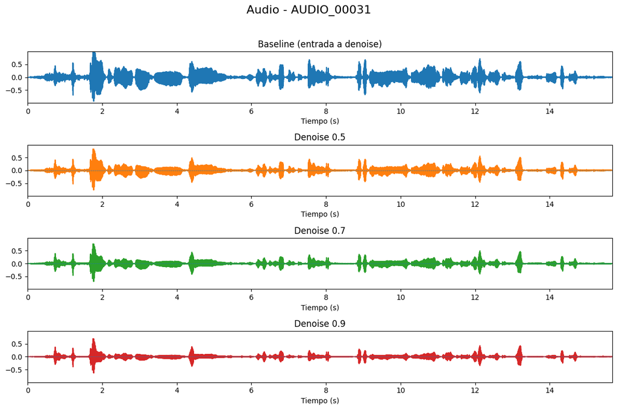

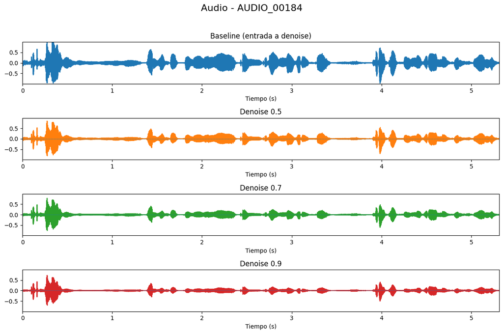

```python
# Comparación visual del impacto del denoise sobre la señal

# Control: si no hay audios, no ejecutar
if len(selected_denoise_ids) == 0:
    print("No hay audios para visualización de denoise.")

else:

    # Selección de muestra
    sampled_ids = random.sample(list(selected_denoise_ids), min(NUM_SAMPLES, len(selected_denoise_ids)))

    for audio_id in sampled_ids:

        # Señal base desde baseline
        base_item = next(item for item in baseline_dataset if item["audio_id"] == audio_id)
        y_base = base_item["y"]
        sr = base_item["sr"]

        # Aplicación condicional previa (trim si corresponde)
        if df_metrics.loc[df_metrics["audio_id"] == audio_id, "apply_trim"].values[0]:
            y_base, _ = librosa.effects.trim(y_base, top_db=SELECTED_TOP_DB)

        # Generación de señales con distintos niveles de denoise
        denoises = {}

        for level in denoise_levels:

            # Aplicación directa de denoise (sin depender de resultados previos)
            try:
                y_denoised = nr.reduce_noise(
                    y=y_base,
                    sr=sr,
                    prop_decrease=level
                )
                denoises[f"Denoise {level}"] = y_denoised

            except Exception as e:
                print(f"Error en denoise (Audio - {audio_id}, nivel {level}): {e}")

        # Si no hay señales generadas, informar y continuar
        if len(denoises) == 0:
            print(f"No se pudo generar denoise para el Audio - {audio_id}")
            continue

        # Diccionario final de señales
        signals = {
            "Baseline (entrada a denoise)": y_base,
            **denoises
        }

        # Inicialización de la figura
        plt.figure(figsize=(12, 8))
        plt.suptitle(f"Audio - {audio_id}", fontsize=16)

        # Límites comunes
        max_time = len(y_base) / sr
        y_max = max(np.max(np.abs(y)) for y in signals.values())

        colors = plt.cm.tab10(range(len(signals)))

        # Representación
        for i, ((label, y), color) in enumerate(zip(signals.items(), colors), start=1):

            # Eje temporal en segundos
            time_axis = np.arange(len(y)) / sr

            plt.subplot(len(signals), 1, i)
            plt.plot(time_axis, y, color=color)

            plt.xlim(0, max_time)
            plt.ylim(-y_max, y_max)

            plt.axhline(0, linestyle='--', linewidth=0.5)
            plt.title(label)
            plt.xlabel("Tiempo (s)")

        plt.tight_layout(rect=[0, 0, 1, 0.96])
        plt.show()
```

El análisis visual confirma la tendencia observada en las métricas. A medida que aumenta el nivel de reducción de ruido, la señal presenta una menor densidad de componentes de baja amplitud, dando lugar a una forma de onda más limpia y simplificada.

En niveles intermedios, la estructura principal de la señal se mantiene claramente identificable, mientras que en configuraciones más agresivas se observa una pérdida progresiva de detalle, especialmente en regiones de baja energía, donde la señal tiende a aplanarse.

###### 6.3.1.1.3 Escucha (cualitativo)

```python
# Reproducción de señales para evaluación cualitativa del denoise

# Control: si no hay audios, no ejecutar
if len(selected_denoise_ids) == 0:
    print("No hay audios para reproducción de denoise.")

else:

    # Selección de muestra
    sampled_ids = random.sample(list(selected_denoise_ids), min(NUM_SAMPLES, len(selected_denoise_ids)))

    for audio_id in sampled_ids:

        # Señal base desde baseline
        base_item = next(item for item in baseline_dataset if item["audio_id"] == audio_id)
        y_base = base_item["y"]
        sr = base_item["sr"]

        # Aplicación condicional previa (trim si corresponde)
        if df_metrics.loc[df_metrics["audio_id"] == audio_id, "apply_trim"].values[0]:
            y_base, _ = librosa.effects.trim(y_base, top_db=SELECTED_TOP_DB)

        # Generación de señales con distintos niveles de denoise
        denoises = {}

        for level in denoise_levels:
            try:
                y_denoised = nr.reduce_noise(
                    y=y_base,
                    sr=sr,
                    prop_decrease=level
                )
                denoises[f"Denoise {level}"] = y_denoised
            except Exception as e:
                print(f"Error en denoise (Audio - {audio_id}, nivel {level}): {e}")

        # Si no hay señales generadas, se omite
        if len(denoises) == 0:
            continue

        # Diccionario de señales a reproducir
        signals = {
            "Baseline (entrada a denoise)": y_base,
            **denoises
        }

        print(f"\n========================")
        print(f"Audio - {audio_id}")
        print(f"========================\n")

        # Reproducción de cada señal
        for label, y in signals.items():
            duration = len(y) / sr
            print(f"{label} (duración: {round(duration, 2)}s)")
            display(Audio(y, rate=sr))
```

```
========================
Audio - AUDIO_00103
========================

Baseline (entrada a denoise) (duración: 7.72s)
```

[interactive chart not shown]

```
Denoise 0.5 (duración: 7.72s)
```

[interactive chart not shown]

```
Denoise 0.7 (duración: 7.72s)
```

[interactive chart not shown]

```
Denoise 0.9 (duración: 7.72s)
```

[interactive chart not shown]

```
========================
Audio - AUDIO_00015
========================

Baseline (entrada a denoise) (duración: 12.05s)
```

[interactive chart not shown]

```
Denoise 0.5 (duración: 12.05s)
```

[interactive chart not shown]

```
Denoise 0.7 (duración: 12.05s)
```

[interactive chart not shown]

```
Denoise 0.9 (duración: 12.05s)
```

[interactive chart not shown]

Desde el punto de vista perceptivo, los niveles bajos (0.5) apenas introducen cambios apreciables, manteniendo el ruido de fondo en gran medida presente. En configuraciones intermedias (0.7), se percibe una mejora clara en la limpieza de la señal, sin comprometer la inteligibilidad del discurso.

Por el contrario, valores elevados (0.9) generan una reducción excesiva, afectando a la naturalidad de la voz y eliminando componentes relevantes, lo que se traduce en una degradación audible en determinados fragmentos.

##### 6.3.1.2 Conclusiones de la reducción de ruido

El proceso de reducción de ruido presenta un comportamiento controlado y progresivo, con una disminución clara de la energía de la señal a medida que se incrementa la intensidad del filtrado. Sin embargo, esta reducción no discrimina completamente entre ruido y señal útil, lo que introduce un compromiso entre limpieza y preservación de la información.

La evaluación conjunta permite identificar que valores intermedios ofrecen el mejor equilibrio operativo, al reducir el ruido de forma efectiva sin afectar de manera significativa a la inteligibilidad de la señal.

En base a estos resultados, se establece un nivel de reducción de ruido de **0.7** como configuración óptima para su integración en el pipeline, al proporcionar una mejora perceptible en la calidad de la señal manteniendo la integridad del contenido de voz.

#### 6.3.2 Filtro paso alto (*high-pass*)

En este apartado se aplica un filtro paso alto sobre la señal de audio con el objetivo de atenuar las componentes de baja frecuencia asociadas a ruido de fondo, como viento, vibraciones o ruido de maquinaria. Estas componentes, aunque no siempre perceptibles de forma evidente, pueden afectar a la estabilidad de la señal y a su interpretación por parte de los sistemas de reconocimiento automático del habla.

El análisis se centra en evaluar el impacto de distintos valores de frecuencia de corte sobre la señal, comparando los resultados con la señal de referencia (*baseline*) mediante métricas cuantitativas, visualización y evaluación auditiva. Este enfoque permite identificar en qué medida el filtrado contribuye a mejorar la calidad de la señal sin introducir distorsiones relevantes.

El objetivo es determinar si la eliminación de estas componentes mejora la calidad de la señal sin afectar de forma significativa al contenido de voz, optimizando su adecuación para sistemas ASR. Para ello, el filtrado se aplica de forma selectiva únicamente sobre aquellos audios en los que se ha identificado la presencia de ruido de baja frecuencia, evaluando distintos valores de frecuencia de corte para analizar su efecto y seleccionar la configuración más adecuada dentro del *pipeline*.

```python
# Evaluación del impacto de distintos cortes de filtro paso alto sobre la señal

# Definición del filtro paso alto (Butterworth de orden 5)
def highpass_filter(y, sr, cutoff):
    b, a = butter(5, cutoff / (sr / 2), btype='high')
    return filtfilt(b, a, y)

# Frecuencias de corte a evaluar
cutoffs = [50, 100, 150, 200]

# Diccionario para almacenar los resultados por configuración
highpass_results = {}

# Selección de audios donde aplicar high-pass
selected_highpass_ids = set(df_metrics[df_metrics["apply_highpass"]]["audio_id"])

# Control: si no hay audios, no ejecutar
if len(selected_highpass_ids) == 0:
    print("No hay audios candidatos a aplicar high-pass.")

else:

    # Aplicación del filtro para cada valor de cutoff
    for cutoff in cutoffs:

        hp_dataset = []

        for item in baseline_dataset:

            # Filtrado por flag
            if item["audio_id"] not in selected_highpass_ids:
                continue

            y = item["y"]
            sr = item["sr"]

            # Aplicación condicional previa (trim si corresponde)
            if df_metrics.loc[df_metrics["audio_id"] == item["audio_id"], "apply_trim"].values[0]:
                y, _ = librosa.effects.trim(y, top_db=SELECTED_TOP_DB)

            try:
                # Aplicación del filtro paso alto
                y_hp = highpass_filter(y, sr, cutoff)

                hp_dataset.append({
                    "audio_id": item["audio_id"],
                    "y": y_hp,
                    "sr": sr
                })

            except Exception as e:
                print(f"Error en high-pass (audio {item['audio_id']}): {e}")

        # Almacenamiento de resultados para este cutoff
        highpass_results[cutoff] = hp_dataset

        print(f"High-pass aplicado con cutoff={cutoff} Hz sobre {len(hp_dataset)} audios")
```

```
High-pass aplicado con cutoff=50 Hz sobre 114 audios
High-pass aplicado con cutoff=100 Hz sobre 114 audios
High-pass aplicado con cutoff=150 Hz sobre 114 audios
High-pass aplicado con cutoff=200 Hz sobre 114 audios
```

##### 6.3.2.1 Evaluación del filtro paso alto

En este subapartado se evalúa el efecto de la aplicación de un filtro paso alto sobre la señal de audio, considerando distintos valores de frecuencia de corte.

La evaluación se apoya en un enfoque comparativo basado en métricas cuantitativas, análisis visual de la señal y validación cualitativa mediante escucha.

El objetivo es determinar si la eliminación de componentes de baja frecuencia contribuye a mejorar la calidad de la señal sin introducir degradación perceptible en el contenido de voz.

###### 6.3.2.1.1 Métricas (cuantitativo)

```python
# Selección de una muestra de audios para analizar el efecto del filtro sobre la energía
NUM_SAMPLES = 2

# Fijamos semilla para garantizar reproducibilidad
random.seed(42)

# Selección de audios donde aplicar high-pass
selected_highpass_ids = set(df_metrics[df_metrics["apply_highpass"]]["audio_id"])

# Control: si no hay audios, no ejecutar
if len(selected_highpass_ids) == 0:
    print("No hay audios para evaluar high-pass.")

else:

    # Selección de muestra sobre audios relevantes
    sampled_ids = random.sample(list(selected_highpass_ids), min(NUM_SAMPLES, len(selected_highpass_ids)))

    rows = []

    for audio_id in sampled_ids:

        # Señal base (desde baseline)
        base_item = next(item for item in baseline_dataset if item["audio_id"] == audio_id)
        base = base_item["y"]
        sr = base_item["sr"]

        # Aplicación condicional previa (trim si corresponde)
        if df_metrics.loc[df_metrics["audio_id"] == audio_id, "apply_trim"].values[0]:
            base, _ = librosa.effects.trim(base, top_db=SELECTED_TOP_DB)

        # Cálculo de energía RMS de referencia
        rms_base = np.sqrt(np.mean(base**2))

        for cutoff in cutoffs:

            # Señal tras aplicar high-pass (búsqueda segura)
            y = next(
                (item["y"] for item in highpass_results[cutoff] if item["audio_id"] == audio_id),
                None
            )

            # Si no existe señal, se omite
            if y is None:
                continue

            # Energía RMS tras filtrado
            rms = np.sqrt(np.mean(y**2))

            # Variación relativa de energía (controlando división por cero)
            if rms_base > 0:
                variation = (1 - rms / rms_base) * 100
            else:
                variation = 0.0

            # Registro de resultados
            rows.append({
                "audio_id": audio_id,
                "config": f"highpass_{cutoff}",
                "rms_baseline": round(rms_base, 4),
                "rms": round(rms, 4),
                "variation_energy_%": round(variation, 2)
            })

# Conversión a DataFrame para análisis estructurado
df_metrics_hp = pd.DataFrame(rows)

# Visualización de resultados
display(df_metrics_hp)
```

|  | audio_id | config | rms_baseline | rms | variation_energy_% |
| --- | --- | --- | --- | --- | --- |
| 0 | AUDIO_00056 | highpass_50 | 0.1119 | 0.1118 | 0.04 |
| 1 | AUDIO_00056 | highpass_100 | 0.1119 | 0.1113 | 0.49 |
| 2 | AUDIO_00056 | highpass_150 | 0.1119 | 0.1101 | 1.61 |
| 3 | AUDIO_00056 | highpass_200 | 0.1119 | 0.1071 | 4.23 |
| 4 | AUDIO_00195 | highpass_50 | 0.0783 | 0.0783 | 0.00 |
| 5 | AUDIO_00195 | highpass_100 | 0.0783 | 0.0781 | 0.21 |
| 6 | AUDIO_00195 | highpass_150 | 0.0783 | 0.0753 | 3.78 |
| 7 | AUDIO_00195 | highpass_200 | 0.0783 | 0.0697 | 10.92 |

El análisis cuantitativo muestra que la aplicación del filtro paso alto introduce variaciones muy reducidas en el nivel RMS de la señal. En los casos analizados, estas variaciones oscilan entre aproximadamente 0% y 11%, siendo prácticamente despreciables en frecuencias de corte bajas (50–100 Hz) y aumentando de forma progresiva a partir de 150 Hz.

Este comportamiento indica que la mayor parte de la energía de la señal se concentra en frecuencias superiores al rango eliminado, lo que sugiere una presencia limitada de ruido de baja frecuencia en los audios.

###### 6.3.2.1.2 Señal (visual)

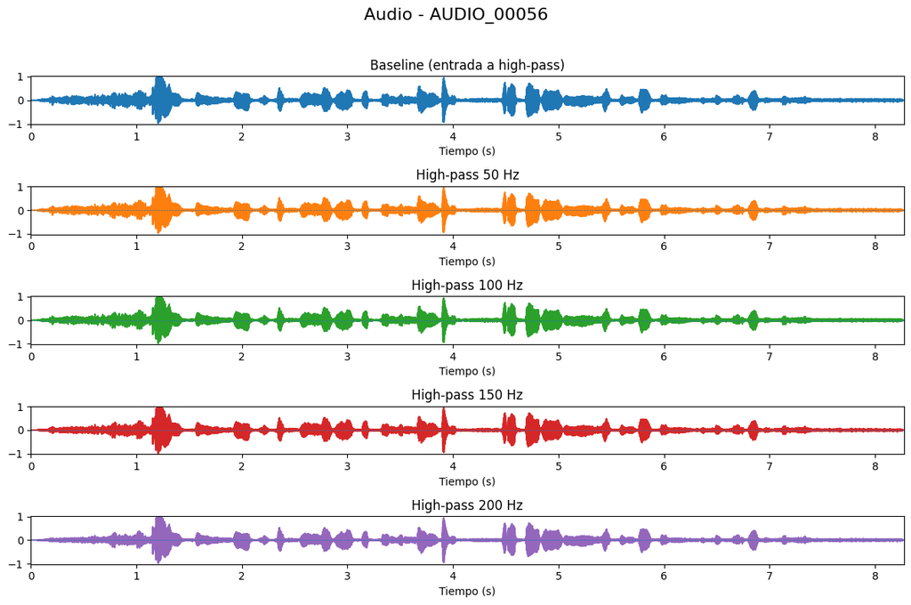

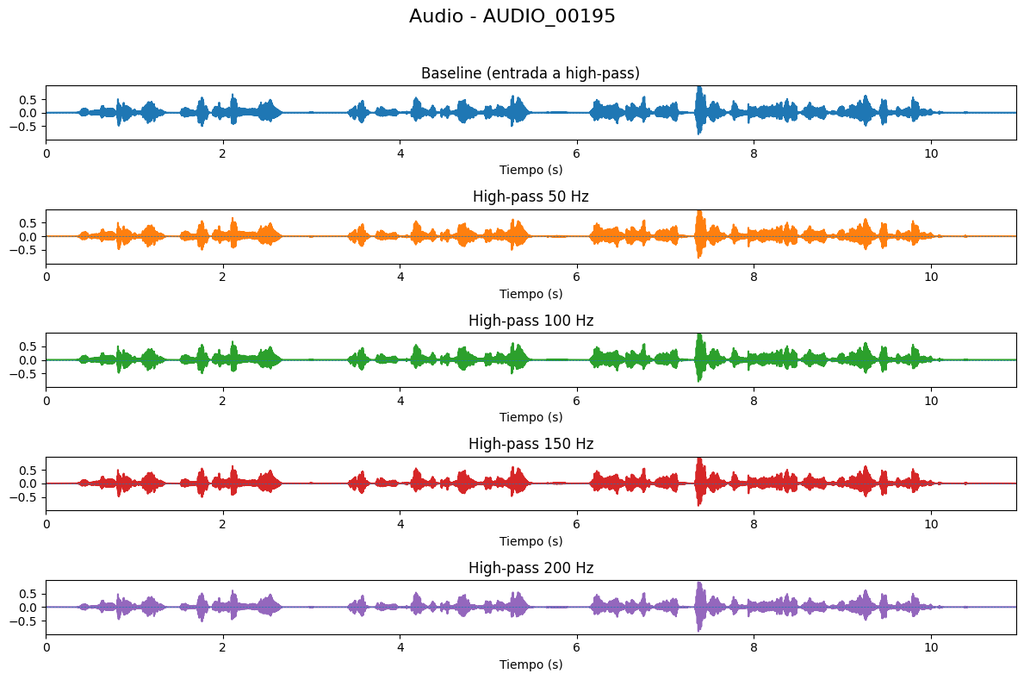

```python
# Comparación visual del efecto del filtro paso alto sobre la señal

# Control: si no hay audios, no ejecutar
if len(selected_highpass_ids) == 0:
    print("No hay audios para visualización de high-pass.")

else:

    for audio_id in sampled_ids:

        # Señal base (desde baseline)
        base_item = next(item for item in baseline_dataset if item["audio_id"] == audio_id)
        base = base_item["y"]
        sr = base_item["sr"]

        # Aplicación condicional previa (trim si corresponde)
        if df_metrics.loc[df_metrics["audio_id"] == audio_id, "apply_trim"].values[0]:
            base, _ = librosa.effects.trim(base, top_db=SELECTED_TOP_DB)

        # Generación de señales filtradas para cada cutoff
        highpasses = {}

        for cutoff in cutoffs:

            y = next(
                (item["y"] for item in highpass_results[cutoff] if item["audio_id"] == audio_id),
                None
            )

            if y is not None:
                highpasses[f"High-pass {cutoff} Hz"] = y

        # Si no hay señales filtradas, se omite
        if len(highpasses) == 0:
            continue

        # Diccionario de señales a representar
        signals = {
            "Baseline (entrada a high-pass)": base,
            **highpasses
        }

        # Inicialización de la figura
        plt.figure(figsize=(12, 8))
        plt.suptitle(f"Audio - {audio_id}", fontsize=16)

        # Límites comunes para permitir comparación coherente
        max_time = len(base) / sr
        y_max = max(np.max(np.abs(y)) for y in signals.values())

        # Configuración de subplots
        n_plots = len(signals)
        colors = plt.cm.tab10(range(n_plots))

        # Representación de cada señal
        for i, ((label, y), color) in enumerate(zip(signals.items(), colors), start=1):

            # Eje temporal en segundos
            time_axis = np.arange(len(y)) / sr

            plt.subplot(n_plots, 1, i)
            plt.plot(time_axis, y, color=color)

            plt.xlim(0, max_time)
            plt.ylim(-y_max, y_max)
            plt.axhline(0, linestyle='--', linewidth=0.5)

            plt.title(label)
            plt.xlabel("Tiempo (s)")

        # Ajuste final de la visualización
        plt.tight_layout(rect=[0, 0, 1, 0.96])
        plt.show()
```

El análisis visual confirma que el filtrado paso alto no produce modificaciones significativas en la forma global de la señal. En la mayoría de los casos, la estructura temporal se mantiene prácticamente inalterada, lo que explica la baja variación observada en las métricas.

No obstante, en configuraciones más agresivas (150–200 Hz) se aprecian ligeras modificaciones en determinados picos de la señal, especialmente en regiones concretas, lo que sugiere una eliminación más intensa de componentes de baja frecuencia que puede empezar a afectar a la señal útil.

###### 6.3.2.1.3 Escucha (cualitativo)

```python
# Reproducción de señales para evaluación cualitativa del impacto del filtro paso alto

# Control: si no hay audios, no ejecutar
if len(selected_highpass_ids) == 0:
    print("No hay audios para reproducción de high-pass.")

else:

    for audio_id in sampled_ids:

        # Señal base (desde baseline)
        base_item = next(item for item in baseline_dataset if item["audio_id"] == audio_id)
        base = base_item["y"]
        sr = base_item["sr"]

        # Aplicación condicional previa (trim si corresponde)
        if df_metrics.loc[df_metrics["audio_id"] == audio_id, "apply_trim"].values[0]:
            base, _ = librosa.effects.trim(base, top_db=SELECTED_TOP_DB)

        # Generación de señales filtradas
        highpasses = {}

        for cutoff in cutoffs:

            y = next(
                (item["y"] for item in highpass_results[cutoff] if item["audio_id"] == audio_id),
                None
            )

            if y is not None:
                highpasses[f"High-pass {cutoff} Hz"] = y

        # Si no hay señales, se omite
        if len(highpasses) == 0:
            continue

        # Diccionario de señales a reproducir
        signals = {
            "Baseline (entrada a high-pass)": base,
            **highpasses
        }

        # Información general del audio
        duration_base = len(base) / sr

        print(f"\n========================")
        print(f"Audio - {audio_id} (duración original: {round(duration_base, 2)}s)")
        print(f"========================\n")

        # Reproducción de cada versión
        for label, y in signals.items():
            duration = len(y) / sr
            print(f"{label} (duración: {round(duration, 2)}s)")
            display(Audio(y, rate=sr))
```

```
========================
Audio - AUDIO_00056 (duración original: 8.28s)
========================

Baseline (entrada a high-pass) (duración: 8.28s)
```

[interactive chart not shown]

```
High-pass 50 Hz (duración: 8.28s)
```

[interactive chart not shown]

```
High-pass 100 Hz (duración: 8.28s)
```

[interactive chart not shown]

```
High-pass 150 Hz (duración: 8.28s)
```

[interactive chart not shown]

```
High-pass 200 Hz (duración: 8.28s)
```

[interactive chart not shown]

```
========================
Audio - AUDIO_00195 (duración original: 10.96s)
========================

Baseline (entrada a high-pass) (duración: 10.96s)
```

[interactive chart not shown]

```
High-pass 50 Hz (duración: 10.96s)
```

[interactive chart not shown]

```
High-pass 100 Hz (duración: 10.96s)
```

[interactive chart not shown]

```
High-pass 150 Hz (duración: 10.96s)
```

[interactive chart not shown]

```
High-pass 200 Hz (duración: 10.96s)
```

[interactive chart not shown]

Desde el punto de vista perceptivo, los efectos del filtrado son prácticamente imperceptibles en valores bajos (50–100 Hz), manteniéndose la calidad de la señal sin cambios apreciables.

Sin embargo, a partir de 150 Hz se comienza a percibir una ligera degradación en la voz, que se acentúa en 200 Hz, donde la señal pierde parte de su cuerpo y naturalidad, indicando que el filtrado está afectando ya a componentes relevantes del habla.

##### 6.3.2.2 Conclusiones del filtro paso alto

El filtro paso alto presenta un impacto limitado sobre la señal en el conjunto de datos analizado, lo que sugiere una baja presencia de ruido de baja frecuencia en los audios. Las métricas y el análisis visual confirman que el filtrado en rangos bajos no altera significativamente la señal, mientras que configuraciones más agresivas introducen una reducción adicional de energía sin aportar mejoras claras.

La evaluación cualitativa refuerza este comportamiento, evidenciando que valores elevados de frecuencia de corte pueden afectar a la calidad percibida de la voz.

En base a estos resultados, se selecciona una frecuencia de corte de **100 Hz** como configuración adecuada, al mantener la integridad de la señal y permitir una eliminación moderada de posibles componentes de baja frecuencia sin introducir degradación perceptible.

#### 6.3.3 Conclusiones de filtrado

El análisis conjunto de las técnicas de filtrado pone de manifiesto comportamientos diferenciados en función del tipo de transformación aplicada. Mientras que la reducción de ruido introduce una modificación significativa de la señal, con impacto directo en la energía y en la percepción auditiva, el filtrado paso alto presenta un efecto mucho más limitado en el conjunto de datos analizado.

Las técnicas han sido evaluadas de forma individual para caracterizar su comportamiento aislado. No obstante, en el *pipeline* final su aplicación se realiza de forma condicional y combinada en función de los *flags* definidos, permitiendo aprovechar el efecto complementario de ambas transformaciones cuando las condiciones de la señal lo requieren.

En particular, la reducción de ruido se configura como la técnica principal de filtrado, al proporcionar una mejora perceptible en la limpieza de la señal en niveles intermedios. Sin embargo, su aplicación no está exenta de limitaciones: aunque perceptivamente el audio puede resultar más limpio, la eliminación espectral puede introducir inconsistencias en determinadas bandas de frecuencia. Este comportamiento, documentado en la literatura sobre técnicas de *denoising*, puede afectar negativamente a modelos de reconocimiento automático del habla, como Whisper, que dependen de la coherencia espectral de la señal.

Este efecto ha sido contrastado experimentalmente en el *Notebook* 2 mediante la evaluación con métricas WER, donde se observa que una reducción de ruido excesiva puede degradar el rendimiento del sistema, incluso cuando la señal resulta más limpia para el oído humano.

Por su parte, el filtro paso alto actúa como un mecanismo complementario, orientado a la eliminación de componentes de muy baja frecuencia asociados a ruido de fondo (como viento o vibraciones). Su impacto sobre la señal es reducido, pero contribuye a estabilizar la entrada sin introducir degradaciones perceptibles cuando se emplean valores moderados.

En base a este análisis, se establece el uso de **reducción de ruido con intensidad 0.7** como técnica principal de filtrado, complementada con un **filtro paso alto de 100 Hz**, ambos aplicados de forma selectiva dentro del *pipeline* en función de las características de la señal.

### 6.4 Normalización de amplitud (*RMS normalization*)

En este apartado se aplica una normalización de amplitud sobre la señal resultante del pipeline previamente definido, con el objetivo de reducir la variabilidad en la energía media entre audios y proporcionar una entrada más consistente al sistema de reconocimiento automático del habla (ASR).

A diferencia de etapas anteriores, esta transformación se aplica de forma condicional, únicamente sobre aquellos audios identificados como de baja energía mediante las métricas definidas previamente. De este modo, se evita alterar señales que ya presentan niveles adecuados, manteniendo un enfoque conservador alineado con el principio de no sobreprocesamiento.

La normalización se aborda como un refinamiento final de la señal, permitiendo corregir diferencias de ganancia derivadas de las condiciones de grabación sin modificar la estructura temporal ni el contenido espectral relevante.

Existen distintos enfoques para la normalización de la señal, siendo los más habituales:

- **Peak normalization**, que ajusta la amplitud máxima de la señal
- **RMS normalization**, que ajusta la energía media de la señal

En este trabajo se prioriza el uso de *RMS normalization*, ya que proporciona un control más estable sobre la energía global de la señal, evitando situaciones en las que picos aislados condicionen el nivel de normalización. Este comportamiento resulta especialmente adecuado en entornos reales, donde la dinámica de los audios puede ser altamente variable.

La evaluación de esta técnica se realiza comparando la señal antes y después de la normalización mediante un enfoque combinado: análisis cuantitativo de métricas energéticas, inspección visual de la señal y evaluación cualitativa mediante escucha.

El objetivo es mejorar la consistencia de la señal de entrada al sistema ASR, garantizando niveles de energía homogéneos sin introducir distorsión ni degradar el contenido de voz.

```python
# Evaluación del impacto de distintos niveles de normalización RMS

# Valores objetivo de energía RMS a analizar
RMS_TARGETS = [0.05, 0.1, 0.2]

# Diccionario para almacenar los resultados por configuración
normalized_results = {}

# Selección de audios donde aplicar normalización RMS
selected_rms_ids = set(df_metrics[df_metrics["apply_rms"]]["audio_id"])

# Control: si no hay audios, no ejecutar
if len(selected_rms_ids) == 0:
    print("No hay audios candidatos a aplicar normalización RMS.")

else:

    # Aplicación de normalización para cada nivel objetivo
    for target in RMS_TARGETS:

        norm_dataset = []

        for item in baseline_dataset:

            # Filtrado por flag → solo audios con baja energía
            if item["audio_id"] not in selected_rms_ids:
                continue

            y = item["y"]
            sr = item["sr"]

            # Aplicación condicional previa (trim si corresponde)
            if df_metrics.loc[df_metrics["audio_id"] == item["audio_id"], "apply_trim"].values[0]:
                y, _ = librosa.effects.trim(y, top_db=SELECTED_TOP_DB)

            # Cálculo de energía RMS actual
            rms_current = np.sqrt(np.mean(y**2))

            # Cálculo de la ganancia necesaria (evitando división por cero)
            if rms_current > 0:
                gain = target / rms_current
                y_norm = y * gain
            else:
                y_norm = y

            # Almacenamiento del resultado normalizado
            norm_dataset.append({
                "audio_id": item["audio_id"],
                "y": y_norm,
                "sr": sr,
                "rms_target": target
            })

        normalized_results[target] = norm_dataset

        print(f"Normalización aplicada con RMS objetivo = {target} sobre {len(norm_dataset)} audios")
```

```
Normalización aplicada con RMS objetivo = 0.05 sobre 1 audios
Normalización aplicada con RMS objetivo = 0.1 sobre 1 audios
Normalización aplicada con RMS objetivo = 0.2 sobre 1 audios
```

#### 6.4.1 Evaluación de la normalización RMS

En este subapartado se evalúa el impacto de la normalización de amplitud sobre la señal de audio, comparando distintas configuraciones de energía RMS objetivo.

El análisis se realiza sobre una muestra representativa de audios seleccionados, permitiendo observar el comportamiento de la señal antes y después de la normalización. Para ello, se adopta un enfoque comparativo basado en métricas cuantitativas, inspección visual de la señal y evaluación cualitativa mediante escucha.

El objetivo es determinar qué nivel de normalización permite homogenizar el volumen de los audios sin introducir efectos no deseados, como distorsión o pérdida de información relevante, seleccionando así la configuración más adecuada para su integración en el *pipeline* final.

##### 6.4.1.1 Métricas (cuantitativo)

```python
# Selección de una muestra de audios para analizar el efecto de la normalización RMS
NUM_SAMPLES = 2

# Fijamos semilla para garantizar reproducibilidad
random.seed(42)

# Selección de audios donde aplicar RMS
selected_rms_ids = set(df_metrics[df_metrics["apply_rms"]]["audio_id"])

# Control: si no hay audios, no ejecutar
if len(selected_rms_ids) == 0:
    print("No hay audios para análisis de normalización RMS.")

else:

    # Selección de muestra sobre audios relevantes
    sampled_ids = random.sample(list(selected_rms_ids), min(NUM_SAMPLES, len(selected_rms_ids)))

    rows = []

    for audio_id in sampled_ids:

        # Señal base sin normalizar (desde baseline)
        base_item = next(item for item in baseline_dataset if item["audio_id"] == audio_id)
        base = base_item["y"]
        sr = base_item["sr"]

        # Aplicación condicional previa (trim si corresponde)
        if df_metrics.loc[df_metrics["audio_id"] == audio_id, "apply_trim"].values[0]:
            base, _ = librosa.effects.trim(base, top_db=SELECTED_TOP_DB)

        # Métricas de referencia
        rms_base = np.sqrt(np.mean(base**2))
        peak_base = np.max(np.abs(base))

        for target in RMS_TARGETS:

            # Señal normalizada (búsqueda segura)
            y = next(
                (item["y"] for item in normalized_results[target] if item["audio_id"] == audio_id),
                None
            )

            # Si no existe, se omite
            if y is None:
                continue

            # Cálculo de métricas
            rms = np.sqrt(np.mean(y**2))
            peak = np.max(np.abs(y))

            # Ganancia aplicada respecto a la señal original
            gain = target / rms_base if rms_base > 0 else 0

            # Crest factor: relación entre pico y energía RMS
            crest = peak / rms if rms > 0 else 0

            # Detección de clipping
            clipping = np.sum(np.abs(y) > 1.0)

            # Registro de resultados
            rows.append({
                "audio_id": audio_id,
                "config": f"rms_{target}",
                "rms_original": round(rms_base, 4),
                "rms_result": round(rms, 4),
                "gain": round(gain, 2),
                "peak": round(peak, 4),
                "crest_factor": round(crest, 2),
                "clipping_samples": int(clipping)
            })

# Conversión a DataFrame
df_metrics_rms = pd.DataFrame(rows)

# Visualización
display(df_metrics_rms)
```

|  | audio_id | config | rms_original | rms_result | gain | peak | crest_factor | clipping_samples |
| --- | --- | --- | --- | --- | --- | --- | --- | --- |
| 0 | AUDIO_00055 | rms_0.05 | 0.0953 | 0.05 | 0.52 | 0.5247 | 10.49 | 0 |
| 1 | AUDIO_00055 | rms_0.1 | 0.0953 | 0.10 | 1.05 | 1.0494 | 10.49 | 5 |
| 2 | AUDIO_00055 | rms_0.2 | 0.0953 | 0.20 | 2.10 | 2.0988 | 10.49 | 462 |

El análisis cuantitativo muestra que la normalización RMS ajusta de forma directa el nivel de energía de la señal, incrementando progresivamente la amplitud a medida que aumenta el valor objetivo. Este comportamiento se refleja en el factor de ganancia aplicado, que alcanza valores superiores a 2 en configuraciones más agresivas.

Sin embargo, este incremento de amplitud tiene un impacto relevante en el rango dinámico de la señal. En particular, se observa la aparición de clipping en valores elevados (RMS = 0.2), con un número significativo de muestras saturadas, lo que indica una pérdida de integridad en la señal.

En niveles intermedios (RMS = 0.1), el ajuste de energía se mantiene dentro de rangos aceptables, con una aparición limitada de saturación.

##### 6.4.1.2 Señal (visual)

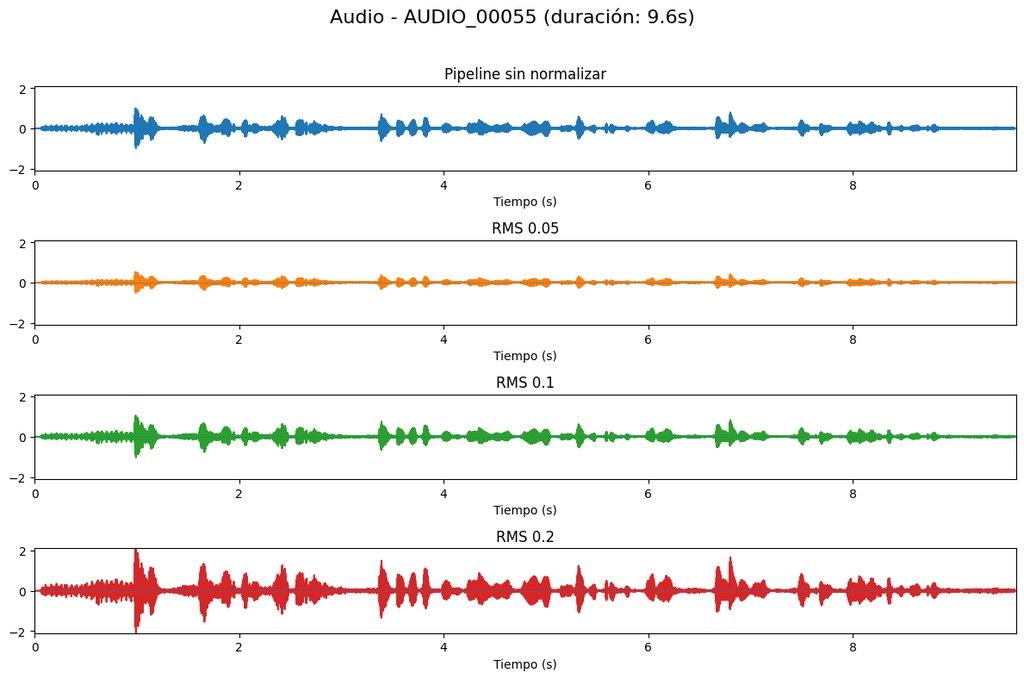

```python
# Comparación visual del efecto de la normalización RMS

# Control: si no hay audios, no ejecutar
if len(selected_rms_ids) == 0:
    print("No hay audios para visualización de normalización RMS.")

else:

    for audio_id in sampled_ids:

        # Señal base desde baseline
        base_item = next(item for item in baseline_dataset if item["audio_id"] == audio_id)
        base = base_item["y"]
        sr = base_item["sr"]

        # Aplicación condicional previa (trim si corresponde)
        if df_metrics.loc[df_metrics["audio_id"] == audio_id, "apply_trim"].values[0]:
            base, _ = librosa.effects.trim(base, top_db=SELECTED_TOP_DB)

        # Generación de señales normalizadas (búsqueda segura)
        norms = {}

        for target in RMS_TARGETS:

            y = next(
                (item["y"] for item in normalized_results[target] if item["audio_id"] == audio_id),
                None
            )

            if y is not None:
                norms[f"RMS {target}"] = y

        # Si no hay señales, se omite
        if len(norms) == 0:
            continue

        # Señales a representar
        signals = {
            "Pipeline sin normalizar": base,
            **norms
        }

        # Duración de referencia
        duration_base = len(base) / sr

        plt.figure(figsize=(12, 8))
        plt.suptitle(f"Audio - {audio_id} (duración: {round(duration_base, 2)}s)", fontsize=16)

        # Escala global coherente para comparación
        max_time = len(base) / sr
        y_max = max(np.max(np.abs(y)) for y in signals.values())

        colors = plt.cm.tab10(range(len(signals)))

        for i, ((label, y), color) in enumerate(zip(signals.items(), colors), start=1):

            # Eje temporal en segundos
            time_axis = np.arange(len(y)) / sr

            plt.subplot(len(signals), 1, i)
            plt.plot(time_axis, y, color=color)

            plt.xlim(0, max_time)
            plt.ylim(-y_max, y_max)

            plt.axhline(0, linestyle='--', linewidth=0.5)
            plt.title(label)
            plt.xlabel("Tiempo (s)")

        plt.tight_layout(rect=[0, 0, 1, 0.96])
        plt.show()
```

El análisis visual confirma el efecto de escalado de la señal. A medida que aumenta el valor objetivo de RMS, la amplitud de la señal crece de forma proporcional, incrementando la ocupación del rango dinámico.

En configuraciones elevadas, la señal presenta picos más pronunciados que alcanzan los límites de representación, evidenciando fenómenos de saturación. En valores intermedios, la señal mantiene una forma consistente sin distorsiones visibles significativas.

##### 6.4.1.3 Escucha (cualitativo)

```python
# Reproducción de señales para evaluación cualitativa del impacto de la normalización RMS

# Control: si no hay audios, no ejecutar
if len(selected_rms_ids) == 0:
    print("No hay audios para reproducción de normalización RMS.")

else:

    for audio_id in sampled_ids:

        # Señal base desde baseline
        base_item = next(item for item in baseline_dataset if item["audio_id"] == audio_id)
        base = base_item["y"]
        sr = base_item["sr"]

        # Aplicación condicional previa (trim si corresponde)
        if df_metrics.loc[df_metrics["audio_id"] == audio_id, "apply_trim"].values[0]:
            base, _ = librosa.effects.trim(base, top_db=SELECTED_TOP_DB)

        # Generación de señales normalizadas
        norms = {}

        for target in RMS_TARGETS:

            y = next(
                (item["y"] for item in normalized_results[target] if item["audio_id"] == audio_id),
                None
            )

            if y is not None:
                norms[f"RMS {target}"] = y

        # Si no hay señales, se omite
        if len(norms) == 0:
            continue

        # Señales a reproducir
        signals = {
            "Pipeline sin normalizar": base,
            **norms
        }

        duration_base = len(base) / sr

        print(f"\n========================")
        print(f"Audio - {audio_id} (duración: {round(duration_base, 2)}s)")
        print(f"========================\n")

        for label, y in signals.items():
            duration = len(y) / sr
            print(f"{label} (duración: {round(duration, 2)}s)")
            display(Audio(y, rate=sr))
```

```
========================
Audio - AUDIO_00055 (duración: 9.6s)
========================

Pipeline sin normalizar (duración: 9.6s)
```

[interactive chart not shown]

```
RMS 0.05 (duración: 9.6s)
```

[interactive chart not shown]

```
RMS 0.1 (duración: 9.6s)
```

[interactive chart not shown]

```
RMS 0.2 (duración: 9.6s)
```

[interactive chart not shown]

Desde el punto de vista perceptivo, las diferencias entre configuraciones son poco apreciables en condiciones normales de escucha, especialmente entre valores bajos e intermedios. No obstante, en configuraciones más agresivas (RMS = 0.2), pueden aparecer ligeras distorsiones asociadas a la saturación de la señal, aunque no siempre resultan evidentes en todos los fragmentos.

#### 6.4.2 Conclusiones de la normalización RMS

La normalización RMS permite homogeneizar el nivel de energía entre audios, facilitando una entrada más consistente al sistema de reconocimiento. Sin embargo, su aplicación introduce un compromiso entre amplificación de la señal y preservación del rango dinámico.

Los resultados muestran que valores elevados pueden provocar saturación y degradación de la señal, mientras que valores bajos tienen un impacto limitado. En este contexto, configuraciones intermedias ofrecen un equilibrio adecuado, permitiendo aumentar la energía sin introducir distorsiones significativas.

En base a este análisis, se selecciona un valor de **RMS = 0.1** como configuración óptima para su integración en el *pipeline*, al proporcionar una normalización efectiva sin comprometer la calidad de la señal.

### 6.5 Segmentación mediante *Voice Activity Detection* (VAD)

En este apartado se aborda la segmentación de la señal mediante técnicas de detección de actividad de voz (*Voice Activity Detection*, VAD), con el objetivo de eliminar regiones internas no informativas y reducir la duración efectiva del audio.

A diferencia del *trimming*, que actúa sobre los extremos de la señal, el VAD permite identificar silencios o regiones de baja energía distribuidas a lo largo del audio, lo que resulta especialmente relevante en grabaciones de larga duración o con pausas prolongadas.

Su aplicación se plantea de forma condicional, restringiéndose a aquellos audios que presentan una duración elevada y una proporción significativa de silencio, según las métricas previamente definidas. Esta decisión evita interferir en señales cortas donde la segmentación podría fragmentar el discurso y degradar el contexto lingüístico.

Dado que los modelos ASR modernos ya incorporan mecanismos internos de segmentación, el uso de VAD externo se evalúa como una optimización adicional cuyo impacto debe ser validado empíricamente.

El objetivo de esta sección es analizar si la eliminación controlada de regiones no informativas mejora la eficiencia del procesamiento sin comprometer la integridad del contenido de voz ni la calidad de la transcripción.

#### 6.5.1 VAD basado en energía (*librosa*)

En este subapartado se evalúa un enfoque clásico de segmentación basado en energía, utilizando funciones de `librosa` para identificar regiones de la señal con contenido acústico relevante.

Se definen distintas configuraciones con diferentes niveles de agresividad, controladas mediante parámetros como el umbral energético (`top_db`), la duración mínima de los segmentos y la incorporación de *padding* para evitar cortes abruptos. Este diseño permite analizar el impacto del VAD bajo distintos criterios de segmentación.

La aplicación se realiza de forma selectiva sobre los audios identificados como candidatos, integrando además transformaciones previas del *pipeline* (como *trimming*) para garantizar coherencia en el flujo de procesamiento.

```python
# Definición de configuraciones VAD basadas en energía (no modelo profundo)
# Se evalúan tres niveles de agresividad para controlar el recorte de silencios

VAD_CONFIGS = {
    "agresivo": {
        "top_db": 20,           # umbral más bajo → detecta más silencio → recorte más agresivo
        "min_silence_ms": 400,  # elimina segmentos muy cortos
        "padding_ms": 200       # añade contexto alrededor de la voz
    },
    "equilibrado": {
        "top_db": 25,
        "min_silence_ms": 300,
        "padding_ms": 150
    },
    "conservador": {
        "top_db": 30,           # umbral más alto → menos eliminación de señal
        "min_silence_ms": 300,
        "padding_ms": 150
    }
}

# Diccionario para almacenar resultados por configuración
vad_results = {}

# Selección de audios donde aplicar VAD
selected_vad_ids = set(df_metrics[df_metrics["needs_vad"]]["audio_id"])

# Control: si no hay audios, no ejecutar
if len(selected_vad_ids) == 0:
    print("No hay audios candidatos a aplicar VAD.")

else:

    # Evaluación de cada configuración
    for config_name, params in VAD_CONFIGS.items():

        vad_dataset = []

        vad_applied_count = 0
        vad_skipped_count = 0

        for item in baseline_dataset:

            audio_id = item["audio_id"]

            y = item["y"]
            sr = item["sr"]

            # Aplicación condicional previa (trim si corresponde)
            if df_metrics.loc[df_metrics["audio_id"] == audio_id, "apply_trim"].values[0]:
                y, _ = librosa.effects.trim(y, top_db=SELECTED_TOP_DB)

            # Aplicar VAD solo a audios seleccionados
            if audio_id in selected_vad_ids:

                # Conversión de parámetros a muestras
                min_silence_samples = int((params["min_silence_ms"] / 1000) * sr)
                padding_samples = int((params["padding_ms"] / 1000) * sr)

                # Detección de segmentos con energía significativa
                intervals = librosa.effects.split(
                    y,
                    top_db=params["top_db"],
                    frame_length=2048,
                    hop_length=512
                )

                segments = []

                for start, end in intervals:

                    # Eliminación de segmentos demasiado cortos
                    if (end - start) < min_silence_samples:
                        continue

                    # Aplicación de padding para no cortar palabras
                    start_pad = max(0, start - padding_samples)
                    end_pad = min(len(y), end + padding_samples)

                    segment = y[start_pad:end_pad]
                    segments.append(segment)

                # Caso crítico: si no hay segmentos válidos, conservar señal original
                if len(segments) == 0:
                    segments = [y]

                vad_dataset.append({
                    "audio_id": audio_id,
                    "segments": segments,
                    "sr": sr,
                    "vad_applied": True
                })

                vad_applied_count += 1

            else:
                # Audios no candidatos no se modifican
                vad_dataset.append({
                    "audio_id": audio_id,
                    "segments": [y],
                    "sr": sr,
                    "vad_applied": False
                })

                vad_skipped_count += 1

        # Almacenamiento del resultado para esta configuración
        vad_results[config_name] = vad_dataset

        # Resumen del comportamiento
        print(f"VAD aplicado con configuración {config_name} sobre {vad_applied_count} audios")
```

```
VAD aplicado con configuración agresivo sobre 13 audios
VAD aplicado con configuración equilibrado sobre 13 audios
VAD aplicado con configuración conservador sobre 13 audios
```

##### 6.5.1.1 Evaluación del VAD basado en energía

En este subapartado se evalúa el comportamiento de un sistema de detección de actividad de voz basado en umbrales de energía, analizando su capacidad para segmentar la señal en regiones de voz y silencio.

La evaluación se apoya en un enfoque comparativo basado en métricas cuantitativas, análisis visual de la señal y validación cualitativa mediante escucha.

El objetivo es determinar la eficacia del método en la eliminación de silencios sin comprometer la continuidad del discurso ni la integridad de la señal.

###### 6.5.1.1.1 Métricas (cuantitativo)

```python
# Selección de una muestra de audios para analizar el efecto del VAD basado en energía
NUM_SAMPLES = 2

# Fijamos semilla para garantizar reproducibilidad
random.seed(42)

# Selección de audios donde aplicar VAD
selected_vad_ids = set(df_metrics[df_metrics["needs_vad"]]["audio_id"])

# Verificación: si no hay candidatos, se detiene el análisis
if len(selected_vad_ids) == 0:
    print("No hay audios donde se haya aplicado VAD.")

else:

    # Selección aleatoria SOLO sobre audios válidos
    sampled_ids = random.sample(
        list(selected_vad_ids),
        min(NUM_SAMPLES, len(selected_vad_ids))
    )

    rows = []

    # Iteración por configuración de VAD
    for config_name, dataset in vad_results.items():

        for audio_id in sampled_ids:

            # Búsqueda del item correspondiente
            item = next(
                (x for x in dataset if x["audio_id"] == audio_id),
                None
            )

            # Si no existe o no se aplicó VAD, se omite
            if item is None or not item["vad_applied"]:
                continue

            # Señal base (sin VAD)
            base_item = next(
                x for x in baseline_dataset if x["audio_id"] == audio_id
            )

            base = base_item["y"]
            sr = base_item["sr"]

            # Aplicación condicional previa (trim si corresponde)
            if df_metrics.loc[df_metrics["audio_id"] == audio_id, "apply_trim"].values[0]:
                base, _ = librosa.effects.trim(base, top_db=SELECTED_TOP_DB)

            duration_base = len(base) / sr

            # Señal tras VAD
            segments = item["segments"]
            y_vad = np.concatenate(segments)

            duration_vad = len(y_vad) / sr

            # Reducción relativa de duración
            if duration_base > 0:
                reduction = (1 - duration_vad / duration_base) * 100
            else:
                reduction = 0.0

            rows.append({
                "audio_id": audio_id,
                "config": config_name,
                "duration_original": round(duration_base, 2),
                "duration_vad": round(duration_vad, 2),
                "reduction_%": round(reduction, 2),
                "num_segments": len(segments)
            })

    # Visualización de resultados
    if len(rows) > 0:
        df_vad = pd.DataFrame(rows)
        display(df_vad)
    else:
        print("No hay datos válidos tras el filtrado.")
```

|  | audio_id | config | duration_original | duration_vad | reduction_% | num_segments |
| --- | --- | --- | --- | --- | --- | --- |
| 0 | AUDIO_00125 | agresivo | 35.97 | 19.36 | 46.17 | 20 |
| 1 | AUDIO_00191 | agresivo | 141.50 | 94.08 | 33.51 | 82 |
| 2 | AUDIO_00125 | equilibrado | 35.97 | 28.46 | 20.88 | 30 |
| 3 | AUDIO_00191 | equilibrado | 141.50 | 123.20 | 12.94 | 109 |
| 4 | AUDIO_00125 | conservador | 35.97 | 32.07 | 10.83 | 30 |
| 5 | AUDIO_00191 | conservador | 141.50 | 127.81 | 9.68 | 91 |

El análisis cuantitativo muestra que el VAD basado en energía permite reducir de forma significativa la duración de los audios, alcanzando reducciones de hasta un 46% en configuraciones agresivas. Sin embargo, esta reducción va acompañada de un elevado número de segmentos generados, especialmente en audios largos, donde se superan los 80 fragmentos en algunos casos.

A medida que la configuración se vuelve más conservadora, la reducción de duración disminuye (en torno al 10–20%), pero el número de segmentos sigue siendo elevado, lo que indica una segmentación inestable y altamente fragmentada.

Estos resultados evidencian que la técnica prioriza la eliminación de energía sin considerar la coherencia temporal de la señal.

###### 6.5.1.1.2 Señal (visual)

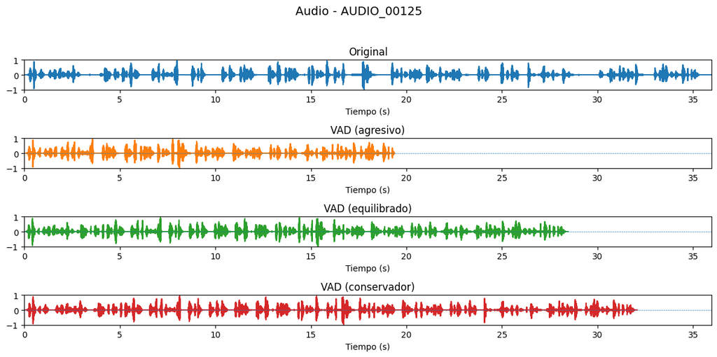

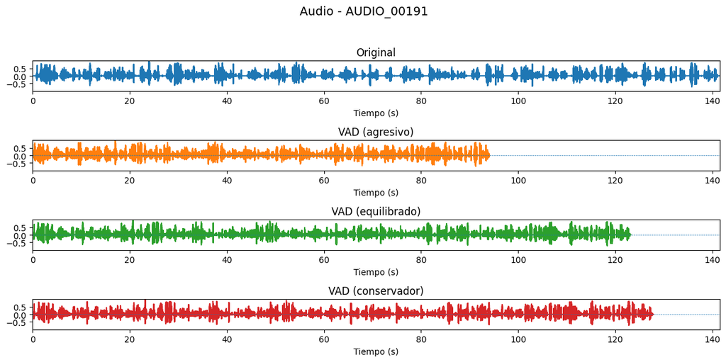

```python
# Comparación visual del efecto del VAD basado en energía

# Verificación básica
if len(selected_vad_ids) == 0:
    print("No hay audios donde se haya aplicado VAD.")

else:

    # Orden fijo de configuraciones para coherencia visual
    VAD_ORDER = ["agresivo", "equilibrado", "conservador"]

    # Iteramos sobre la muestra seleccionada
    for audio_id in sampled_ids:

        # Señal base (sin VAD)
        base_item = next(item for item in baseline_dataset if item["audio_id"] == audio_id)
        base = base_item["y"]
        sr = base_item["sr"]

        # Aplicación condicional previa (trim si corresponde)
        if df_metrics.loc[df_metrics["audio_id"] == audio_id, "apply_trim"].values[0]:
            base, _ = librosa.effects.trim(base, top_db=SELECTED_TOP_DB)

        # Selección de configuraciones donde realmente se aplica VAD
        valid_configs = []

        for config_name in VAD_ORDER:

            item = next(
                (x for x in vad_results[config_name] if x["audio_id"] == audio_id),
                None
            )

            if item is not None and item["vad_applied"]:
                valid_configs.append((config_name, item["segments"]))

        # Construcción de señales a visualizar
        signals = [("Original", base)] + [
            (
                f"VAD ({config_name})",
                np.concatenate(segments)
            )
            for config_name, segments in valid_configs
        ]

        # Inicialización de figura
        plt.figure(figsize=(12, 6))
        plt.suptitle(f"Audio - {audio_id}", fontsize=14)

        # Escala común para comparación correcta
        max_time = len(base) / sr
        y_max = max(np.max(np.abs(y)) for _, y in signals)

        colors = plt.cm.tab10(range(len(signals)))

        # Representación de cada señal
        for i, ((label, y), color) in enumerate(zip(signals, colors), start=1):

            time_axis = np.arange(len(y)) / sr

            plt.subplot(len(signals), 1, i)
            plt.plot(time_axis, y, color=color)
            plt.xlim(0, max_time)
            plt.ylim(-y_max, y_max)
            plt.axhline(0, linestyle='--', linewidth=0.5)
            plt.title(label)
            plt.xlabel("Tiempo (s)")

        plt.tight_layout(rect=[0, 0, 1, 0.95])
        plt.show()
```

El análisis visual muestra la reducción de las regiones de baja energía y la eliminación de segmentos de silencio, especialmente en configuraciones más agresivas. Sin embargo, la representación gráfica no permite identificar con precisión posibles cortes internos dentro del discurso ni evaluar la coherencia lingüística de los segmentos generados.

###### 6.5.1.1.3 Escucha (cualitativo)

```python
# Reproducción de señales para evaluación cualitativa del impacto del VAD basado en energía

# Verificación básica
if len(selected_vad_ids) == 0:
    print("No hay audios donde se haya aplicado VAD.")

else:

    # Iteramos sobre la muestra seleccionada
    for audio_id in sampled_ids:

        # Señal base (sin VAD)
        base_item = next(item for item in baseline_dataset if item["audio_id"] == audio_id)
        base = base_item["y"]
        sr = base_item["sr"]

        # Aplicación condicional previa (trim si corresponde)
        if df_metrics.loc[df_metrics["audio_id"] == audio_id, "apply_trim"].values[0]:
            base, _ = librosa.effects.trim(base, top_db=SELECTED_TOP_DB)

        # Selección de configuraciones donde realmente se aplica VAD
        valid_configs = []

        for config_name in vad_results:

            item = next(
                (x for x in vad_results[config_name] if x["audio_id"] == audio_id),
                None
            )

            if item is not None and item["vad_applied"]:
                valid_configs.append((config_name, item["segments"]))

        # Construcción de señales a reproducir
        signals = [("Original", base)] + [
            (
                f"VAD ({config_name})",
                np.concatenate(segments)
            )
            for config_name, segments in valid_configs
        ]

        # Separador visual
        print(f"\n========================")
        print(f"Audio - {audio_id}")
        print(f"========================\n")

        # Reproducción de cada señal
        for label, y in signals:
            duration = len(y) / sr
            print(f"{label} (duración: {round(duration, 2)}s)")
            display(Audio(y, rate=sr))
```

```
========================
Audio - AUDIO_00125
========================

Original (duración: 35.97s)
```

[interactive chart not shown]

```
VAD (agresivo) (duración: 19.36s)
```

[interactive chart not shown]

```
VAD (equilibrado) (duración: 28.46s)
```

[interactive chart not shown]

```
VAD (conservador) (duración: 32.07s)
```

[interactive chart not shown]

```
========================
Audio - AUDIO_00191
========================

Original (duración: 141.5s)
```

[interactive chart not shown]

```
VAD (agresivo) (duración: 94.08s)
```

[interactive chart not shown]

```
VAD (equilibrado) (duración: 123.2s)
```

[interactive chart not shown]

```
VAD (conservador) (duración: 127.81s)
```

[interactive chart not shown]

La evaluación auditiva pone de manifiesto que ninguna de las configuraciones resulta adecuada para su uso directo. Se observan cortes dentro de palabras, pérdida de información relevante y una fragmentación excesiva del discurso.

Las configuraciones más agresivas eliminan partes completas de la señal de voz, mientras que las más conservadoras reducen parcialmente este efecto sin llegar a resolverlo. Además, se detectan artefactos como repeticiones de sílabas o fragmentos, derivados de la concatenación de segmentos mal definidos.

Estos problemas afectan directamente a la inteligibilidad del audio, haciendo inviable su uso en sistemas de reconocimiento automático del habla.

##### 6.5.1.2 Conclusiones del VAD basado en energía

El VAD basado en energía presenta un comportamiento inestable en el conjunto de datos analizado. Aunque permite reducir la duración de la señal, esta reducción se realiza a costa de una segmentación excesivamente fragmentada, que introduce pérdidas de información y artefactos en la reconstrucción del audio.

La dependencia exclusiva de umbrales de energía limita su capacidad para discriminar entre silencio, ruido y señal de voz, especialmente en entornos no controlados, lo que explica los resultados observados.

En base a este análisis, se descarta el uso del VAD basado en energía dentro del *pipeline*, al comprometer la integridad de la señal y degradar significativamente su calidad para el procesamiento posterior.

#### 6.5.2 VAD basado en aprendizaje profundo

En este subapartado se evalúa un enfoque de segmentación basado en aprendizaje profundo mediante el modelo preentrenado *Silero* VAD, diseñado específicamente para la detección de actividad de voz en condiciones reales.

A diferencia de los métodos basados en energía, este tipo de modelos incorpora información contextual y patrones acústicos complejos, lo que permite una detección más precisa de las regiones de voz, incluso en presencia de ruido.

La aplicación se realiza bajo el mismo esquema condicional definido previamente, permitiendo una comparación directa con el enfoque clásico y evaluando su capacidad para mejorar la segmentación sin degradar la señal.

```python
# Carga del modelo preentrenado de VAD (Silero basado en PyTorch)
# Este modelo detecta automáticamente regiones con presencia de voz
model = load_silero_vad()

# Dataset de salida con segmentos detectados por VAD
silero_vad_dataset = []

# Contadores para análisis del comportamiento del modelo
vad_applied_count = 0
vad_skipped_count = 0

# Selección de audios donde aplicar VAD
selected_vad_ids = set(df_metrics[df_metrics["needs_vad"]]["audio_id"])

# Control: si no hay audios, no ejecutar
if len(selected_vad_ids) == 0:
    print("No hay audios candidatos a aplicar Silero VAD.")

else:

    # Iteración sobre el dataset base
    for item in baseline_dataset:

        audio_id = item["audio_id"]

        y = item["y"]
        sr = item["sr"]

        # Aplicación condicional previa (trim si corresponde)
        if df_metrics.loc[df_metrics["audio_id"] == audio_id, "apply_trim"].values[0]:
            y, _ = librosa.effects.trim(y, top_db=SELECTED_TOP_DB)

        # Aplicación de VAD únicamente a audios seleccionados
        if audio_id in selected_vad_ids:

            # Conversión de la señal a tensor de PyTorch (requisito del modelo)
            audio_tensor = torch.from_numpy(y).float()

            # Asegurar señal mono (el modelo espera una única dimensión)
            if audio_tensor.ndim > 1:
                audio_tensor = torch.mean(audio_tensor, dim=0)

            # Normalización del rango dinámico para estabilidad del modelo
            # Se garantiza que los valores estén en [-1, 1]
            if audio_tensor.abs().max() > 1:
                audio_tensor = audio_tensor / audio_tensor.abs().max()

            # Detección de intervalos de voz mediante el modelo Silero
            # Devuelve una lista de timestamps con inicio y fin de cada segmento
            speech_timestamps = get_speech_timestamps(
                audio_tensor,
                model,
                sampling_rate=sr
            )

            # Extracción de segmentos de audio correspondientes a las regiones detectadas
            segments = [
                y[ts["start"]:ts["end"]]
                for ts in speech_timestamps
            ]

            # Caso crítico: si no se detecta ningún segmento, se conserva la señal original
            if len(segments) == 0:
                segments = [y]

            # Almacenamiento del resultado
            silero_vad_dataset.append({
                "audio_id": audio_id,
                "segments": segments,
                "sr": sr,
                "vad_applied": True
            })

            vad_applied_count += 1

        else:
            # En audios no candidatos no se aplica VAD
            silero_vad_dataset.append({
                "audio_id": audio_id,
                "segments": [y],
                "sr": sr,
                "vad_applied": False
            })

            vad_skipped_count += 1

# Resumen del comportamiento del modelo
print(f"Silero VAD aplicado sobre {vad_applied_count} audios")
```

```
Silero VAD aplicado sobre 13 audios
```

##### 6.5.2.1 Evaluación del VAD basado en aprendizaje profundo

En este subapartado se evalúa el comportamiento de un sistema de detección de actividad de voz basado en aprendizaje profundo (*Silero* VAD), analizando su capacidad para segmentar la señal de forma robusta en entornos reales.

El análisis se realiza sobre una muestra representativa de audios, combinando métricas cuantitativas, inspección visual y evaluación auditiva.

El objetivo es determinar si este enfoque permite mejorar la segmentación de la señal respecto a métodos clásicos, preservando la continuidad del discurso y reduciendo de forma efectiva las regiones de silencio.

###### 6.5.2.1.1 Métricas (cuantitativo)

```python
# Selección de una muestra de audios para analizar el efecto del VAD basado en aprendizaje profundo (Silero)
NUM_SAMPLES = 5

# Fijamos semilla para garantizar reproducibilidad
random.seed(42)

# Selección de audios donde aplicar VAD
selected_vad_ids = set(df_metrics[df_metrics["needs_vad"]]["audio_id"])

# Verificación básica
if len(selected_vad_ids) == 0:
    print("No hay audios con Silero VAD aplicado.")

else:

    # Muestreo sobre audios válidos
    sampled_ids = random.sample(
        list(selected_vad_ids),
        min(NUM_SAMPLES, len(selected_vad_ids))
    )

    rows = []

    # Iteración sobre la muestra seleccionada
    for audio_id in sampled_ids:

        # Señal base (desde baseline)
        base_item = next(item for item in baseline_dataset if item["audio_id"] == audio_id)
        base = base_item["y"]
        sr = base_item["sr"]

        # Aplicación condicional previa (trim si corresponde)
        if df_metrics.loc[df_metrics["audio_id"] == audio_id, "apply_trim"].values[0]:
            base, _ = librosa.effects.trim(base, top_db=SELECTED_TOP_DB)

        # Señal tras VAD
        vad_item = next(
            (item for item in silero_vad_dataset if item["audio_id"] == audio_id),
            None
        )

        if vad_item is None or not vad_item["vad_applied"]:
            continue

        segments = vad_item["segments"]
        y_vad = np.concatenate(segments)

        # Duraciones
        duration_base = len(base) / sr
        duration_vad = len(y_vad) / sr

        # Reducción relativa
        reduction = (1 - duration_vad / duration_base) * 100 if duration_base > 0 else 0.0

        # Registro de métricas
        rows.append({
            "audio_id": audio_id,
            "duration_original": round(duration_base, 2),
            "duration_vad": round(duration_vad, 2),
            "reduction_%": round(reduction, 2),
            "num_segments": len(segments)
        })

    # Construcción y visualización del DataFrame
    if len(rows) > 0:
        df_silero = pd.DataFrame(rows)
        display(df_silero)
    else:
        print("No hay datos válidos tras el filtrado.")
```

|  | audio_id | duration_original | duration_vad | reduction_% | num_segments |
| --- | --- | --- | --- | --- | --- |
| 0 | AUDIO_00125 | 35.97 | 26.43 | 26.51 | 16 |
| 1 | AUDIO_00191 | 141.50 | 109.72 | 22.46 | 43 |
| 2 | AUDIO_00180 | 39.92 | 29.84 | 25.26 | 13 |
| 3 | AUDIO_00166 | 58.52 | 47.04 | 19.61 | 21 |
| 4 | AUDIO_00040 | 80.29 | 56.40 | 29.75 | 27 |

El VAD basado en aprendizaje profundo presenta reducciones de duración moderadas, situadas entre aproximadamente el 20% y el 30%, con un número de segmentos significativamente inferior al observado en el enfoque basado en energía.

Este comportamiento indica una segmentación más estable, evitando la fragmentación excesiva y manteniendo una estructura temporal más coherente, incluso en audios de larga duración.

###### 6.5.2.1.2 Señal (visual)

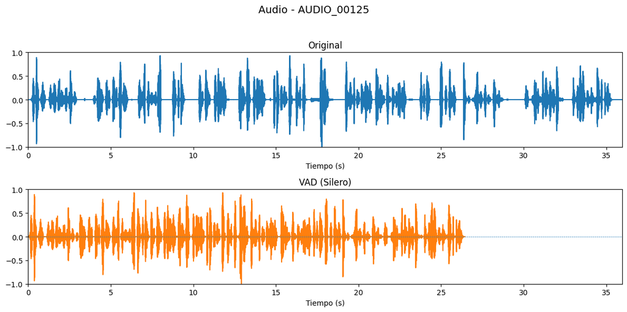

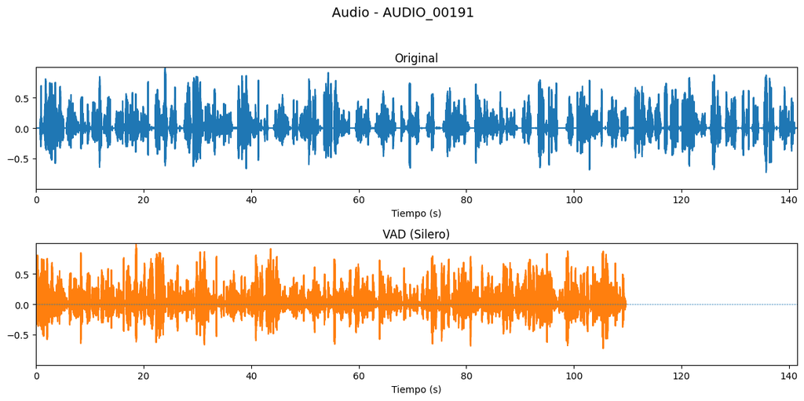

```python
# Comparación visual del efecto del VAD basado en aprendizaje profundo (Silero)

# Control: si no hay audios, no ejecutar
if len(selected_vad_ids) == 0:
    print("No hay audios con Silero VAD aplicado.")

else:

    # Visualización de señales sobre la misma muestra ya definida (sampled_ids)
    for audio_id in sampled_ids:

        # Señal base (desde baseline)
        base_item = next(item for item in baseline_dataset if item["audio_id"] == audio_id)
        base = base_item["y"]
        sr = base_item["sr"]

        # Aplicación condicional previa (trim si corresponde)
        if df_metrics.loc[df_metrics["audio_id"] == audio_id, "apply_trim"].values[0]:
            base, _ = librosa.effects.trim(base, top_db=SELECTED_TOP_DB)

        # Señal tras VAD (búsqueda segura por audio_id)
        vad_item = next(
            (item for item in silero_vad_dataset if item["audio_id"] == audio_id),
            None
        )

        # Si no existe o no se aplicó VAD, se omite
        if vad_item is None or not vad_item["vad_applied"]:
            continue

        segments = vad_item["segments"]
        y_vad = np.concatenate(segments)

        # Diccionario de señales a representar
        signals = [
            ("Original", base),
            ("VAD (Silero)", y_vad)
        ]

        # Inicialización de la figura
        plt.figure(figsize=(12, 6))
        plt.suptitle(f"Audio - {audio_id}", fontsize=14)

        # Escala común para comparación coherente
        max_time = len(base) / sr
        y_max = max(np.max(np.abs(y)) for _, y in signals)

        colors = plt.cm.tab10(range(len(signals)))

        # Representación de cada señal
        for i, ((label, y), color) in enumerate(zip(signals, colors), start=1):

            # Eje temporal en segundos
            time_axis = np.arange(len(y)) / sr

            plt.subplot(len(signals), 1, i)
            plt.plot(time_axis, y, color=color)
            plt.xlim(0, max_time)
            plt.ylim(-y_max, y_max)
            plt.axhline(0, linestyle='--', linewidth=0.5)
            plt.title(label)
            plt.xlabel("Tiempo (s)")

        plt.tight_layout(rect=[0, 0, 1, 0.95])
        plt.show()
```

El análisis visual muestra una reducción de la duración de la señal, asociada a la eliminación de regiones de baja energía. La señal resultante mantiene una estructura global continua, sin que se aprecien patrones evidentes de fragmentación a nivel macroscópico.

No obstante, la representación gráfica no permite evaluar con precisión la presencia de posibles cortes internos en el discurso ni la coherencia lingüística de los segmentos generados, por lo que estas características deben analizarse mediante evaluación auditiva.

###### 6.5.2.1.3 Escucha (cualitativo)

```python
# Reproducción de señales para evaluación cualitativa del impacto del VAD basado en aprendizaje profundo (Silero)

# Control: si no hay audios, no ejecutar
if len(selected_vad_ids) == 0:
    print("No hay audios con Silero VAD aplicado.")

else:

    # Reutilizamos la misma muestra (sampled_ids) definida previamente
    for audio_id in sampled_ids:

        # Señal base (desde baseline)
        base_item = next(item for item in baseline_dataset if item["audio_id"] == audio_id)
        base = base_item["y"]
        sr = base_item["sr"]

        # Aplicación condicional previa (trim si corresponde)
        if df_metrics.loc[df_metrics["audio_id"] == audio_id, "apply_trim"].values[0]:
            base, _ = librosa.effects.trim(base, top_db=SELECTED_TOP_DB)

        # Señal tras VAD (búsqueda segura por audio_id)
        vad_item = next(
            (item for item in silero_vad_dataset if item["audio_id"] == audio_id),
            None
        )

        # Si no existe o no se aplicó VAD, se omite
        if vad_item is None or not vad_item["vad_applied"]:
            continue

        segments = vad_item["segments"]
        y_vad = np.concatenate(segments)

        # Información contextual
        duration_base = len(base) / sr
        duration_vad = len(y_vad) / sr

        print(f"\n========================")
        print(f"Audio {audio_id}")
        print(f"Duración original: {round(duration_base, 2)}s")
        print(f"Duración VAD: {round(duration_vad, 2)}s")
        print(f"========================\n")

        print("Original")
        display(Audio(base, rate=sr))

        print("VAD (Silero)")
        display(Audio(y_vad, rate=sr))
```

```
========================
Audio AUDIO_00125
Duración original: 35.97s
Duración VAD: 26.43s
========================

Original
```

[interactive chart not shown]

```
VAD (Silero)
```

[interactive chart not shown]

```
========================
Audio AUDIO_00191
Duración original: 141.5s
Duración VAD: 109.72s
========================

Original
```

[interactive chart not shown]

```
VAD (Silero)
```

[interactive chart not shown]

La evaluación auditiva confirma el comportamiento observado en las métricas y en la señal. A diferencia del enfoque basado en energía, no se perciben cortes internos en palabras ni fragmentación del discurso, manteniéndose la continuidad natural del habla.

La reducción de duración es menor que en configuraciones agresivas del VAD clásico, pero se realiza de forma más selectiva, eliminando principalmente silencios reales sin afectar al contenido de voz. Este comportamiento garantiza la preservación de la inteligibilidad y evita artefactos como repeticiones o pérdidas de sílabas.

##### 6.5.2.2 Conclusiones del VAD basado en aprendizaje profundo

La aplicación de VAD basado en aprendizaje profundo mediante *Silero* muestra un comportamiento significativamente más robusto que el enfoque basado en energía. Mientras que el método clásico introduce fragmentación y pérdida de información, el modelo basado en aprendizaje profundo permite una segmentación más precisa y estable.

El modelo es capaz de identificar de forma fiable las regiones de voz, reduciendo la duración del audio sin comprometer la continuidad del discurso. Esta mejora se refleja tanto en el análisis visual como en la evaluación auditiva, donde se observa la ausencia de cortes internos y una preservación adecuada de la estructura temporal.

Aunque la reducción de duración es menor en comparación con configuraciones agresivas del VAD clásico, el resultado es más coherente y adecuado para su uso en sistemas ASR.

Adicionalmente, la aplicación de VAD permite reducir la longitud efectiva de los audios, lo que puede contribuir a optimizar el procesamiento posterior en términos de eficiencia temporal y almacenamiento, especialmente en escenarios con grandes volúmenes de datos. Este beneficio se introduce sin comprometer la integridad de la señal, al eliminar principalmente segmentos de silencio.

En base a estos resultados, se selecciona el VAD basado en *Silero* como técnica principal de segmentación para audios de larga duración dentro del *pipeline*, al proporcionar el mejor equilibrio entre reducción de silencios y preservación de la señal de voz.

## 7. Selección del *pipeline* final

La definición del *pipeline* final se ha realizado a partir del análisis experimental de las distintas transformaciones aplicadas sobre la señal, evaluando su impacto mediante métricas cuantitativas, análisis visual y evaluación auditiva.

En primer lugar, se establece una fase de estandarización que garantiza la compatibilidad con el sistema ASR, mediante la conversión a formato WAV, señal mono y frecuencia de muestreo de 16 kHz. Esta etapa permite trabajar con una entrada homogénea y reproducible.

En relación con el filtrado, se selecciona una reducción de ruido con intensidad **0.7**, al proporcionar el mejor equilibrio entre limpieza de la señal y preservación del contenido útil. El filtro paso alto, aunque presenta un impacto limitado en este conjunto de datos, se incorpora con una frecuencia de corte de **100 Hz** como mecanismo complementario para la atenuación de componentes de baja frecuencia.

Respecto a la normalización, se opta por un enfoque basado en RMS con un valor objetivo de **0.1**, que permite homogeneizar el nivel de energía entre audios sin introducir saturación ni distorsiones significativas.

En la etapa de segmentación, se descarta el uso de VAD basado en energía debido a los problemas de fragmentación y pérdida de información observados. En su lugar, se adopta un enfoque basado en aprendizaje profundo mediante Silero VAD, aplicado de forma selectiva en audios de mayor duración, al ofrecer una segmentación más estable y preservar la continuidad del discurso.

El *pipeline* resultante combina estas transformaciones de forma condicional en función de las características de cada audio, evitando la aplicación indiscriminada de procesamiento. Este enfoque permite mantener un equilibrio entre mejora de la señal y preservación de su estructura original.

Finalmente, esta configuración se considera provisional hasta su validación en la siguiente fase, donde se evaluará su impacto real sobre el rendimiento del sistema ASR mediante métricas objetivas como el *Word Error Rate* (WER).

## 8. Implementación y ejecución del *pipeline* final de procesamiento de audio

En este bloque se implementa y ejecuta el *pipeline* final de preprocesamiento de audio, integrando de forma coherente todas las transformaciones previamente analizadas y validadas de manera independiente.

A diferencia de los apartados anteriores, centrados en la evaluación aislada de cada técnica, en esta fase se construye un flujo completo de procesamiento que aplica dichas transformaciones de forma condicional y adaptativa, en función de las características específicas de cada señal.

Este enfoque permite trasladar los resultados experimentales a un entorno operativo, donde el objetivo no es únicamente optimizar cada técnica de forma individual, sino garantizar un comportamiento global consistente, eficiente y reproducible.

Asimismo, la implementación se diseña bajo criterios de modularidad y trazabilidad, facilitando su mantenimiento, extensión e integración en etapas posteriores del sistema, como el módulo de transcripción automática (ASR).

### 8.1 Inicialización del entorno y gestión de rutas

En primer lugar, se define un mecanismo flexible para la gestión de rutas del proyecto, permitiendo localizar automáticamente la estructura de directorios y configurar las carpetas de entrada y salida. Este enfoque facilita la portabilidad del *pipeline*, evitando dependencias rígidas de entorno y permitiendo adaptar fácilmente la organización de datos sin modificar la lógica de procesamiento.

```python
# Define las rutas del proyecto y permite configurar nombres de carpetas
# El usuario puede modificar los nombres o rutas base sin afectar al pipeline
def configure_paths(
    base_data_dir: str = "data",
    audio_dir_name: str = "audio",
    raw_folder: str = "raw",
    standardized_folder: str = "standardized",
    processed_folder: str = "processed"
) -> dict:

    project_root = Path.cwd()

    # Detectar raíz del proyecto
    while not (project_root / base_data_dir).exists():
        if project_root.parent == project_root:
            raise FileNotFoundError("No se encontró la carpeta 'data'")
        project_root = project_root.parent

    data_dir = project_root / base_data_dir
    audio_dir = data_dir / audio_dir_name

    raw_audio_dir = audio_dir / raw_folder
    standardized_audio_dir = audio_dir / standardized_folder
    processed_audio_dir = audio_dir / processed_folder

    # Crear carpetas necesarias (excepto raw)
    standardized_audio_dir.mkdir(parents=True, exist_ok=True)
    processed_audio_dir.mkdir(parents=True, exist_ok=True)

    # Validación de entrada crítica
    if not raw_audio_dir.exists():
        raise FileNotFoundError(f"No existe la carpeta de entrada: {raw_audio_dir}")

    return {
        "project_root": project_root,
        "data_dir": data_dir,
        "audio_dir": audio_dir,
        "raw_audio_dir": raw_audio_dir,
        "standardized_audio_dir": standardized_audio_dir,
        "processed_audio_dir": processed_audio_dir
    }
```

### 8.2 Implementación de funciones del *pipeline* de preprocesamiento

A continuación, se implementan las distintas funciones que componen el *pipeline* de preprocesamiento. Cada función aborda una etapa específica del flujo de transformación de la señal, manteniendo una separación clara de responsabilidades.

Este diseño modular no solo facilita la comprensión y mantenimiento del sistema, sino que permite **aislar el efecto de cada transformación**, favoreciendo su validación individual y la reproducibilidad de los resultados obtenidos durante la fase experimental.

#### 8.2.1 Carga del *dataset* y preparación de metadatos

En esta fase se realiza la carga de los audios originales desde el sistema de almacenamiento, filtrando únicamente aquellos formatos válidos para su procesamiento. Posteriormente, se extraen metadatos básicos de cada archivo, como frecuencia de muestreo, número de canales y duración, que permiten caracterizar la señal. A partir de esta información, se generan indicadores (*flags*) que determinan las transformaciones necesarias para adaptar cada audio al formato objetivo requerido por el sistema ASR.

##### 8.2.1.1 Carga del conjunto de audios

Se realiza la carga de los archivos de audio desde el directorio de entrada, filtrando únicamente aquellos que presentan formatos válidos para su procesamiento. Esta etapa permite construir una representación inicial ligera del conjunto de datos, basada exclusivamente en las rutas de los archivos, facilitando su posterior tratamiento dentro del *pipeline*.

```python
# Carga los audios desde el directorio de entrada, filtrando únicamente formatos válidos
# Devuelve una lista de diccionarios con la ruta de cada audio
def load_audio_dataset(
    raw_audio_dir: Path,
    valid_extensions: set[str] = {".wav", ".mp3", ".m4a", ".flac", ".ogg"}
) -> list[dict]:

    # Filtrado de archivos de audio válidos
    audio_files = [
        f for f in raw_audio_dir.iterdir()
        if f.is_file() and f.suffix.lower() in valid_extensions
    ]

    # Verificación de existencia de audios
    if len(audio_files) == 0:
        raise FileNotFoundError("No se han encontrado audios válidos en el directorio")

    # Construcción del dataset (estructura ligera basada en rutas)
    return [{"path": f} for f in audio_files]
```

##### 8.2.1.2 Extracción de metadatos y generación de indicadores de preprocesamiento

Una vez cargados los audios, se procede a la extracción de metadatos básicos que permiten caracterizar cada señal, incluyendo frecuencia de muestreo, número de canales y duración. A partir de esta información, se generan indicadores (*flags*) que determinan las transformaciones necesarias para adaptar cada audio al formato objetivo requerido por el sistema de reconocimiento automático del habla (ASR). La frecuencia de muestreo objetivo se fija en 16 kHz, garantizando la coherencia con los requisitos del modelo y evitando configuraciones inconsistentes en el *pipeline*.

```python
# Extrae metadatos básicos y define flags necesarios para el pipeline ASR
# Asume configuración fija: audio final en WAV, mono, 16 kHz
def prepare_audio_metadata(audio_dataset: list[dict]) -> list[dict]:

    TARGET_SR = 16000

    for item in audio_dataset:

        audio_path = item["path"]

        try:
            # Extracción de metadatos mediante lectura directa
            info = sf.info(audio_path)

            sample_rate = info.samplerate
            num_channels = info.channels
            duration_sec = info.duration

        except Exception:
            # Fallback mediante carga con pydub para formatos no soportados
            audio = AudioSegment.from_file(audio_path)

            sample_rate = audio.frame_rate
            num_channels = audio.channels
            duration_sec = len(audio) / 1000

        # Registro de metadatos
        item["sample_rate"] = sample_rate
        item["num_channels"] = num_channels
        item["duration_sec"] = duration_sec

        # Generación de flags de transformación
        item["needs_resample"] = sample_rate != TARGET_SR
        item["needs_mono"] = num_channels > 1
        item["needs_conversion"] = audio_path.suffix.lower() != ".wav"

        # Clasificación básica por duración
        if duration_sec < 1:
            item["quality_flag"] = "too_short"
        elif duration_sec > 60:
            item["quality_flag"] = "too_long"
        else:
            item["quality_flag"] = "ok"

    return audio_dataset
```

#### 8.2.2 Estandarización del formato de audio

Una vez caracterizados los audios, se procede a su estandarización, transformando todos los archivos a un formato homogéneo (WAV, mono, 16 kHz). Este paso garantiza la compatibilidad con los modelos de reconocimiento automático del habla (ASR) y reduce la variabilidad asociada a diferencias en codificación, número de canales o frecuencia de muestreo. Asimismo, los audios estandarizados se almacenan en disco, permitiendo su reutilización en etapas posteriores sin necesidad de repetir este proceso.

```python
# Estandariza los audios al formato requerido por ASR (WAV, mono, 16 kHz)
# Guarda los audios en disco y añade la ruta estandarizada al dataset
def standardize_audio_dataset(audio_dataset: list[dict], output_dir: Path) -> list[dict]:

    TARGET_SR = 16000

    for item in audio_dataset:

        input_path = item["path"]
        output_path = output_dir / f"{input_path.stem}.wav"

        try:
            # Carga universal con pydub (soporta todos los formatos)
            audio = AudioSegment.from_file(input_path)

            # Conversión uniforme
            audio = audio.set_channels(1).set_frame_rate(TARGET_SR)

            # Conversión a numpy (int16 → float32 normalizado)
            samples = np.array(audio.get_array_of_samples())
            y = samples.astype(np.float32) / (2 ** 15)

            # Normalización final consistente (por pico)
            max_val = np.max(np.abs(y))
            if max_val > 0:
                y = y / max_val

            # Guardado en formato estándar
            sf.write(output_path, y, TARGET_SR)

            # Registro de la ruta estandarizada
            item["standardized_path"] = output_path

        except Exception as e:
            print(f"Error en estandarización: {input_path.name} -> {e}")

    return audio_dataset


# Carga los audios estandarizados en memoria para su procesamiento posterior
# Devuelve una lista con la señal y frecuencia de muestreo de cada audio
def load_standardized_audio(audio_dataset: list[dict]) -> list[dict]:

    dataset = []

    for item in audio_dataset:
        try:
            y, sr = sf.read(item["standardized_path"])

            dataset.append({
                "audio_id": item["path"].stem,
                "y": y.astype(np.float32),
                "sr": sr
            })

        except Exception as e:
            print(f"Error cargando {item['standardized_path'].name}: {e}")

    return dataset
```

#### 8.2.3 Análisis de calidad de señal y lógica adaptativa del *pipeline*

En esta fase se implementa el mecanismo de decisión del *pipeline*, basado en la caracterización cuantitativa de la señal. A partir de las métricas acústicas calculadas, se define una lógica adaptativa que permite seleccionar automáticamente las transformaciones más adecuadas para cada audio, optimizando el preprocesamiento en función de sus características reales.

Este mecanismo constituye el núcleo del *pipeline*, al introducir un cambio de enfoque desde un procesamiento uniforme hacia un modelo adaptativo, en el que las decisiones no se basan en reglas fijas, sino en la información extraída directamente de la señal.

De este modo, se evita la aplicación indiscriminada de transformaciones, reduciendo el riesgo de degradación y garantizando que cada operación responda a una necesidad justificada. Este planteamiento permite alinear el comportamiento del sistema con las condiciones reales de captura, caracterizadas por una alta variabilidad en la calidad y estructura de los audios.

##### 8.2.3.1 Cálculo de métricas de calidad de señal

Se extraen un conjunto de métricas acústicas que permiten describir cuantitativamente la señal de audio. Estas incluyen medidas de energía (RMS), proporción de silencio, silencio en extremos, tasa de cruces por cero (*ZCR*) y variabilidad energética. Este conjunto de indicadores proporciona una base objetiva para evaluar la calidad de la señal y fundamentar las decisiones posteriores del *pipeline*.

```python
# Extrae métricas acústicas relevantes de la señal para su caracterización cuantitativa
def compute_audio_quality_metrics(audio_dataset: list[dict]) -> list[dict]:

    results = []

    for item in audio_dataset:

        y = item["y"]
        sr = item["sr"]

        if len(y) == 0:
            results.append({
                "audio_id": item["audio_id"],
                "duration_sec": 0,
                "rms": 0,
                "silence_ratio": 1.0,
                "silence_edges_ratio": 1.0,
                "zcr_mean": 0,
                "energy_var": 0
            })
            continue

        # Duración
        duration_sec = len(y) / sr

        # RMS
        rms = np.sqrt(np.mean(y**2))

        # ZCR
        zcr = librosa.feature.zero_crossing_rate(y)
        zcr_mean = np.mean(zcr)

        # Energía por frames
        frame_length = 2048
        hop_length = 512

        energy = np.array([
            np.sum(np.abs(y[i:i+frame_length])**2)
            for i in range(0, len(y), hop_length)
        ])

        energy_var = np.var(energy) if len(energy) > 0 else 0

        # Umbral de silencio
        threshold = 0.01 * np.max(energy) if len(energy) > 0 else 0
        silence_mask = energy < threshold

        # Silencio global
        silence_ratio = np.sum(silence_mask) / len(energy) if len(energy) > 0 else 1.0

        # Silencio en extremos
        start_silence = 0
        for val in silence_mask:
            if val:
                start_silence += 1
            else:
                break

        end_silence = 0
        for val in silence_mask[::-1]:
            if val:
                end_silence += 1
            else:
                break

        silence_edges_ratio = (start_silence + end_silence) / len(energy) if len(energy) > 0 else 1.0

        results.append({
            "audio_id": item["audio_id"],
            "duration_sec": round(duration_sec, 2),
            "rms": round(rms, 5),
            "silence_ratio": round(silence_ratio, 3),
            "silence_edges_ratio": round(silence_edges_ratio, 3),
            "zcr_mean": round(zcr_mean, 5),
            "energy_var": round(energy_var, 5)
        })

    return results
```

##### 8.2.3.2 Construcción del conjunto estructurado de métricas

A partir de las métricas calculadas, se construye una representación estructurada en forma de *DataFrame*, que facilita su análisis, manipulación y uso en la lógica de decisión. Esta estructura permite operar de forma eficiente sobre el conjunto de audios y aplicar reglas de procesamiento de manera consistente y reproducible.

```python
# Construye un DataFrame estructurado a partir de las métricas calculadas
def compute_metrics_dataframe(baseline_dataset: list[dict]) -> pd.DataFrame:

    metrics_results = compute_audio_quality_metrics(baseline_dataset)
    df_metrics = pd.DataFrame(metrics_results)

    return df_metrics
```

##### 8.2.3.3 Implementación de la lógica de decisión del pipeline adaptativo

Se define la lógica de decisión del *pipeline* mediante un enfoque híbrido que combina umbrales estadísticos, basados en percentiles del conjunto de datos, con límites absolutos definidos empíricamente. A partir de estos criterios, se generan *flags* que determinan de forma explícita las transformaciones a aplicar sobre cada audio, estableciendo un comportamiento adaptativo que permite ajustar el procesamiento en función de las características específicas de la señal.

```python
# Define la lógica de decisión del pipeline mediante umbrales híbridos y reglas condicionales
def generate_processing_flags(df_metrics: pd.DataFrame) -> pd.DataFrame:

    # Percentiles
    p_low_rms = df_metrics["rms"].quantile(0.10)
    p_high_silence = df_metrics["silence_ratio"].quantile(0.90)
    p_high_silence_edges = df_metrics["silence_edges_ratio"].quantile(0.90)
    p_high_zcr = df_metrics["zcr_mean"].quantile(0.90)
    p_high_energy = df_metrics["energy_var"].quantile(0.90)

    # Flags
    df_metrics["low_energy"] = (
        (df_metrics["rms"] < p_low_rms) |
        (df_metrics["rms"] < 0.09)
    )

    df_metrics["high_silence"] = (
        (df_metrics["silence_ratio"] > p_high_silence) |
        (df_metrics["silence_ratio"] > 0.30)
    )

    df_metrics["high_silence_edges"] = (
        (df_metrics["silence_edges_ratio"] > p_high_silence_edges) |
        (df_metrics["silence_edges_ratio"] > 0.18)
    )

    df_metrics["high_zcr"] = (
        (df_metrics["zcr_mean"] > p_high_zcr) |
        (df_metrics["zcr_mean"] > 0.11)
    )

    df_metrics["high_energy_var"] = (
        (df_metrics["energy_var"] > p_high_energy) |
        (df_metrics["energy_var"] > 2000)
    )

    # Decisiones
    df_metrics["skip_processing"] = df_metrics["high_energy_var"]

    df_metrics["apply_highpass"] = ~df_metrics["high_energy_var"]

    df_metrics["apply_denoise"] = (
        df_metrics["high_zcr"] &
        ~df_metrics["low_energy"] &
        ~df_metrics["high_energy_var"]
    )

    df_metrics["apply_rms"] = (
        df_metrics["low_energy"] &
        ~df_metrics["high_zcr"] &
        ~df_metrics["high_energy_var"]
    )

    df_metrics["needs_vad"] = (
        df_metrics["high_silence"] &
        (df_metrics["duration_sec"] > 30)
    )

    df_metrics["apply_trim"] = (
        df_metrics["high_silence_edges"] &
        ~df_metrics["needs_vad"] &
        ~df_metrics["high_energy_var"]
    )

    return df_metrics
```

#### 8.2.4 Procesamiento temporal y filtrado de la señal

En esta etapa se aplican transformaciones sobre la señal temporal orientadas a mejorar su calidad y adecuarla al procesamiento posterior. Estas técnicas se implementan de forma independiente, permitiendo su aplicación selectiva dentro del *pipeline* adaptativo en función de las características de cada audio.

##### 8.2.4.1 Eliminación de silencios en extremos y preservación de contexto (trim + padding)

Se aplica una eliminación de silencios en los extremos de la señal mediante técnicas de *trimming*, con el objetivo de eliminar segmentos no informativos que no aportan contenido útil al proceso de reconocimiento. Para evitar la pérdida de contexto temporal relevante, se añade posteriormente un margen de seguridad mediante *padding*, preservando así la estructura de la señal en los límites y garantizando una entrada más estable para el modelo *ASR*.

```python
# Aplica eliminación de silencios en los extremos (trim) y añade padding para preservar contexto
def apply_trim_and_padding(y: np.ndarray, sr: int, top_db: int = 20, padding_ms: int = 300) -> np.ndarray:

    # Eliminación de silencios en extremos según umbral energético
    y_trim, _ = librosa.effects.trim(y, top_db=top_db)

    # Conversión del padding de milisegundos a número de muestras
    padding_samples = int((padding_ms / 1000) * sr)

    # Generación de padding con valores nulos
    pad = np.zeros(padding_samples, dtype=np.float32)

    # Concatenación del padding al inicio y al final de la señal recortada
    y_final = np.concatenate([pad, y_trim, pad])

    return y_final
```

##### 8.2.4.2 Filtrado paso alto (*high-pass filtering*)

Se aplica un filtrado paso alto con el objetivo de atenuar componentes de baja frecuencia presentes en la señal, como ruido ambiental o interferencias de origen físico. Este proceso permite mejorar la relación señal-ruido en el rango de frecuencias relevantes para el habla, facilitando una representación más limpia de la señal y contribuyendo a un mejor rendimiento en etapas posteriores.

```python
# Aplica un filtro paso alto para eliminar componentes de baja frecuencia
def apply_highpass(y: np.ndarray, sr: int, cutoff: int = 100, order: int = 5) -> np.ndarray:

    # Diseño del filtro Butterworth normalizado a la frecuencia de Nyquist
    b, a = butter(order, cutoff / (sr / 2), btype='high')

    # Aplicación del filtro con fase cero para evitar distorsión temporal
    y_filtered = filtfilt(b, a, y)

    return y_filtered
```

##### 8.2.4.3 Reducción de ruido (*denoising*)

Se aplica una técnica de reducción de ruido basada en estimación espectral, orientada a eliminar componentes no deseados presentes en la señal sin afectar significativamente al contenido informativo. Este proceso resulta especialmente relevante en entornos no controlados, donde la señal puede estar contaminada por ruido de fondo, permitiendo obtener una representación más clara y adecuada para el procesamiento por modelos de reconocimiento automático del habla.

```python
# Aplica reducción de ruido sobre la señal de audio
def apply_denoise(y: np.ndarray, sr: int, denoise_strength: float = 0.7) -> np.ndarray:

    # Reducción de ruido mediante estimación espectral
    y_denoised = nr.reduce_noise(
        y=y,
        sr=sr,
        prop_decrease=denoise_strength
    )

    return y_denoised
```

#### 8.2.5 Normalización de amplitud

Se aplica una normalización de la señal basada en el valor RMS (*Root Mean Square*) con el objetivo de homogeneizar el nivel de energía entre audios. Este proceso permite reducir la variabilidad en la amplitud de las señales, evitando que diferencias de volumen introduzcan sesgos en el procesamiento posterior. La normalización se aplica de forma selectiva dentro del *pipeline* adaptativo, únicamente en aquellos casos en los que la señal presenta baja energía y no evidencia presencia significativa de ruido, garantizando así que el ajuste no degrade la calidad de la información acústica.

```python
# Aplica normalización RMS para homogeneizar el nivel de energía de la señal
def apply_rms_normalization(y: np.ndarray, target_rms: float = 0.1) -> np.ndarray:

    # Cálculo del nivel RMS actual de la señal
    rms = np.sqrt(np.mean(y**2))

    # Ajuste de la señal al nivel RMS objetivo si es mayor que cero
    if rms > 0:
        y = y * (target_rms / rms)

    return y
```

#### 8.2.6 Segmentación mediante VAD

En esta fase se aplica un modelo de detección de actividad de voz (*Voice Activity Detection*, VAD) basado en aprendizaje profundo, con el objetivo de identificar segmentos de la señal que contienen información relevante y eliminar silencios internos. Esta técnica se aplica de forma selectiva en aquellos audios donde se detecta una presencia significativa de pausas o silencios estructurales. Tras la detección, los segmentos de voz se concatenan directamente para reconstruir una señal continua, integrándose este proceso de forma inmediata dentro del flujo de procesamiento, sin necesidad de etapas adicionales.

```python
# Aplica VAD basado en aprendizaje profundo (Silero) para eliminar silencios internos
def apply_silero_vad(audio_dataset: list[dict]) -> list[dict]:

    model = load_silero_vad()
    output = []

    for item in audio_dataset:

        # Aseguramos que el array es contiguo en memoria (evita error de PyTorch)
        y = np.ascontiguousarray(item["y"])

        audio_tensor = torch.from_numpy(y).float()

        # Normalización para estabilidad del modelo
        if audio_tensor.abs().max() > 1:
            audio_tensor = audio_tensor / audio_tensor.abs().max()

        # Detección de segmentos de voz
        timestamps = get_speech_timestamps(
            audio_tensor,
            model,
            sampling_rate=item["sr"]
        )

        segments = [
            y[t["start"]:t["end"]]
            for t in timestamps
        ]

        # Control de caso sin detecciones → se mantiene señal original
        if len(segments) == 0:
            segments = [y]
            vad_applied = False
        else:
            vad_applied = True

        output.append({
            "audio_id": item["audio_id"],
            "segments": segments,
            "vad_applied": vad_applied,
            "sr": item["sr"]
        })

    return output
```

#### 8.2.7 Aplicación condicional de técnicas de preprocesamiento

En esta fase se ejecuta el *pipeline* de preprocesamiento siguiendo un enfoque adaptativo, en el que cada audio es sometido únicamente a las transformaciones previamente determinadas mediante la lógica de decisión basada en métricas de calidad de señal. Este mecanismo permite ajustar el procesamiento a las características específicas de cada señal, evitando la aplicación indiscriminada de técnicas que podrían resultar innecesarias o incluso perjudiciales.

La aplicación de las transformaciones se realiza de forma secuencial e integrada, incluyendo operaciones como filtrado paso alto, reducción de ruido, normalización de amplitud, eliminación de silencios en extremos y segmentación mediante VAD, en función de los indicadores asociados a cada audio. De este modo, se construye un flujo de procesamiento coherente que combina múltiples técnicas sin perder el control sobre su impacto individual.

Este enfoque permite mitigar uno de los principales riesgos en *pipelines* de audio: el sobreprocesamiento. La acumulación no controlada de transformaciones puede introducir artefactos, alterar la estructura temporal de la señal o degradar el contenido relevante para el reconocimiento del habla. Frente a ello, la ejecución condicional garantiza que cada técnica se aplique únicamente cuando existe evidencia cuantitativa que justifique su uso, alineando el comportamiento del pipeline con un criterio fundamentado en datos y no en reglas heurísticas fijas.

Como resultado, se obtiene un sistema de preprocesamiento más robusto, eficiente y adaptable a escenarios reales, donde la variabilidad de las condiciones de captura exige un tratamiento diferencial de la señal.

```python
# Aplica el pipeline de preprocesamiento de forma adaptativa según los flags calculados
# Cada audio recibe únicamente las transformaciones necesarias en función de sus características
def process_audio_pipeline(baseline_dataset: list[dict], df_metrics: pd.DataFrame) -> list[dict]:

    output = []

    # Crear mapa de flags por audio_id para acceso rápido
    flags_map = {
        row["audio_id"]: row
        for _, row in df_metrics.iterrows()
    }

    for item in baseline_dataset:

        audio_id = item["audio_id"]
        y = item["y"]
        sr = item["sr"]

        flags = flags_map[audio_id]

        # =========================
        # NO PROCESAR
        # =========================
        if flags["skip_processing"]:
            output.append(item)
            continue

        current = {
            "audio_id": audio_id,
            "y": y,
            "sr": sr
        }

        # =========================
        # HIGH-PASS (base)
        # =========================
        if flags["apply_highpass"]:
            current["y"] = apply_highpass(current["y"], current["sr"])

        # =========================
        # DENOISE
        # =========================
        if flags["apply_denoise"]:
            current["y"] = apply_denoise(current["y"], current["sr"])

        # =========================
        # NORMALIZACIÓN RMS
        # =========================
        if flags["apply_rms"]:
            current["y"] = apply_rms_normalization(current["y"], target_rms=0.1)

        # =========================
        # TRIMMING (con padding)
        # =========================
        if flags["apply_trim"]:
            current["y"] = apply_trim_and_padding(current["y"], current["sr"], top_db=30, padding_ms=300)

        # =========================
        # VAD
        # =========================
        if flags["needs_vad"]:

            vad_result = apply_silero_vad([current])[0]

            # Reconstrucción directa tras VAD
            if vad_result["vad_applied"]:
                current["y"] = np.concatenate(vad_result["segments"])

        output.append(current)

    return output
```

#### 8.2.8 Persistencia de los audios finales

Finalmente, los audios procesados se almacenan en disco en el directorio de salida definido, independientemente de las transformaciones aplicadas en cada caso. Esta etapa permite disponer de un conjunto homogéneo de audios preparados para su uso en fases posteriores del sistema, como la transcripción automática o el análisis semántico. Asimismo, el almacenamiento sistemático de los resultados garantiza la trazabilidad y reproducibilidad del flujo de preprocesamiento, facilitando su validación y reutilización en distintos contextos.

```python
def save_audio_dataset(audio_dataset: list[dict], output_dir: Path) -> None:

    # Crear directorio si no existe
    output_dir.mkdir(parents=True, exist_ok=True)

    saved = 0
    errors = 0

    for item in audio_dataset:

        audio_id = item.get("audio_id")
        y = item.get("y")
        sr = item.get("sr")

        # Validación mínima
        if y is None or sr is None:
            print(f"[ERROR] Datos inválidos en {audio_id}")
            errors += 1
            continue

        try:
            # Asegurar tipo correcto
            y = np.asarray(y, dtype=np.float32)

            # Guardado
            output_path = output_dir / f"{audio_id}.wav"
            sf.write(output_path, y, sr)

            saved += 1

        except Exception as e:
            print(f"[ERROR] Guardando {audio_id}: {e}")
            errors += 1

    print(f"\nGuardados correctamente: {saved}")
    print(f"Errores: {errors}")
```

### 8.3 Ejecución del *pipeline* adaptativo

Una vez definidas todas las funciones, se ejecuta el pipeline completo de forma secuencial. Este bloque coordina la aplicación ordenada de cada etapa sobre el conjunto de audios, desde su carga inicial hasta la generación de los archivos finales procesados. La estructura lineal del flujo facilita la comprensión del proceso global y permite verificar de forma clara la transformación progresiva de la señal a lo largo del pipeline.

En esta implementación se asume que el orden de los elementos en los datasets intermedios se mantiene constante a lo largo del flujo de procesamiento, lo que permite establecer una correspondencia directa entre las señales de audio y sus metadatos asociados. Esta decisión simplifica el diseño del pipeline en un contexto experimental. No obstante, en un entorno productivo, esta asociación debería realizarse mediante identificadores únicos que garanticen la trazabilidad y la robustez del sistema ante posibles desalineaciones.

Este diseño responde a un entorno experimental controlado, donde se prioriza la claridad del flujo y la validación de resultados. En escenarios productivos, sería necesario incorporar mecanismos adicionales de gestión de errores, paralelización y procesamiento incremental para garantizar la escalabilidad del sistema.

```python
print("Inicializando pipeline...")

# Inicialización del entorno y carga de rutas del proyecto
paths = configure_paths()
print("Rutas configuradas correctamente")

# Carga de los audios originales desde el directorio de entrada
audio_dataset = load_audio_dataset(paths["raw_audio_dir"])
print(f"Audios encontrados: {len(audio_dataset)}")

# Extracción de metadatos básicos
audio_dataset = prepare_audio_metadata(audio_dataset)

# Conversión de los audios al formato requerido por ASR (WAV, mono, 16 kHz)
print("Estandarizando audios...")
audio_dataset = standardize_audio_dataset(
    audio_dataset,
    paths["standardized_audio_dir"]
)
print(f"Audios estandarizados: {len(audio_dataset)}")

# Carga de los audios estandarizados para su procesamiento en memoria
print("Cargando audios en memoria...")
baseline_dataset = load_standardized_audio(audio_dataset)
print(f"Audios cargados en memoria: {len(baseline_dataset)}")

# Cálculo de métricas sobre la señal baseline
print("Calculando métricas de calidad de señal...")
df_metrics = compute_metrics_dataframe(baseline_dataset)

# Generación de flags y lógica adaptativa
print("Generando flags y decisiones de procesamiento...")
df_metrics = generate_processing_flags(df_metrics)

# Aplicación del pipeline de forma condicional por audio
print("Aplicando pipeline adaptativo...")
final_dataset = process_audio_pipeline(baseline_dataset, df_metrics)
print(f"Audios procesados: {len(final_dataset)}")

# Almacenamiento final de los audios procesados
print("Guardando audios finales...")
save_audio_dataset(
    final_dataset,
    paths["processed_audio_dir"]
)
print(f"Audios guardados: {len(final_dataset)}")

print("Pipeline completado correctamente")
```

```
Inicializando pipeline...
Rutas configuradas correctamente
Audios encontrados: 200
Estandarizando audios...
Audios estandarizados: 200
Cargando audios en memoria...
Audios cargados en memoria: 200
Calculando métricas de calidad de señal...
Generando flags y decisiones de procesamiento...
Aplicando pipeline adaptativo...
Audios procesados: 200
Guardando audios finales...

Guardados correctamente: 200
Errores: 0
Audios guardados: 200
Pipeline completado correctamente
```

### 8.4 Validación del *pipeline* de preprocesamiento

En este apartado se realiza una validación estructural del comportamiento del *pipeline*, verificando que las transformaciones se aplican exclusivamente cuando lo indican los *flags* generados en la fase de decisión.

El análisis se centra en comprobar dos aspectos fundamentales: por un lado, que los audios marcados como no procesables permanecen invariantes, garantizando que no se introducen modificaciones innecesarias; y por otro, que los audios candidatos a procesamiento presentan cambios efectivos en la señal, evidenciando la correcta aplicación de las transformaciones.

Este proceso permite validar la coherencia interna del *pipeline* y detectar posibles inconsistencias entre la lógica de decisión y su ejecución, asegurando la integridad del flujo antes de su integración en el sistema completo.

```python
# Inicializamos lista para almacenar resultados de validación
checks = []

# Creamos un mapa de acceso rápido a los flags por audio_id
flags_map = {
    row["audio_id"]: row
    for _, row in df_metrics.iterrows()
}

# Recorremos los audios originales (baseline) y los finales procesados
for base, final in zip(baseline_dataset, final_dataset):

    audio_id = base["audio_id"]
    flags = flags_map[audio_id]

    # Determinamos si el audio debía ser procesado según la lógica adaptativa
    processed = not flags["skip_processing"]

    # Comprobamos si la duración se ha mantenido
    same_duration = len(base["y"]) == len(final["y"])

    # Solo comparamos la señal si tienen la misma longitud
    if same_duration:
        same_signal = np.allclose(base["y"], final["y"])
    else:
        same_signal = False

    # Registramos resultados de validación
    checks.append({
        "audio_id": audio_id,
        "processed": processed,
        "signal_equal": same_signal,
        "duration_equal": same_duration
    })

# Convertimos los resultados a DataFrame para análisis estructurado
df_checks = pd.DataFrame(checks)

# Mostramos una muestra aleatoria para inspección rápida
print("=== Validación del pipeline adaptativo ===")
display(df_checks.sample(n=min(5, len(df_checks)), random_state=42))


# ==================================
# Resumen de decisiones del pipeline
# ==================================
print("\n=== Resumen de decisiones ===")

print(f"Total audios: {len(df_metrics)}")
print(f"Sin procesamiento: {df_metrics['skip_processing'].sum()}")
print(f"High-pass: {df_metrics['apply_highpass'].sum()}")
print(f"Denoise: {df_metrics['apply_denoise'].sum()}")
print(f"Normalización RMS: {df_metrics['apply_rms'].sum()}")
print(f"Trimming: {df_metrics['apply_trim'].sum()}")
print(f"VAD: {df_metrics['needs_vad'].sum()}")


# ==============================
# Validación de transformaciones
# ==============================
print("\n=== Validación de transformaciones ===")

# Audios no procesados que permanecen iguales
unchanged = df_checks[~df_checks["processed"]]["signal_equal"].sum()
total_unchanged = len(df_checks[~df_checks["processed"]])

print(f"Audios no procesados sin cambios: {unchanged} / {total_unchanged}")

# Audios procesados que han sido modificados
changed = (~df_checks[df_checks["processed"]]["signal_equal"]).sum()
total_changed = len(df_checks[df_checks["processed"]])

print(f"Audios procesados modificados: {changed} / {total_changed}")
```

```
=== Validación del pipeline adaptativo ===
```

|  | audio_id | processed | signal_equal | duration_equal |
| --- | --- | --- | --- | --- |
| 95 | AUDIO_00096 | True | False | True |
| 15 | AUDIO_00016 | False | True | True |
| 30 | AUDIO_00031 | True | False | True |
| 158 | AUDIO_00159 | True | False | True |
| 128 | AUDIO_00129 | True | False | False |

```
=== Resumen de decisiones ===
Total audios: 200
Sin procesamiento: 86
High-pass: 114
Denoise: 47
Normalización RMS: 1
Trimming: 20
VAD: 13

=== Validación de transformaciones ===
Audios no procesados sin cambios: 86 / 86
Audios procesados modificados: 114 / 114
```

La validación del *pipeline* confirma que las decisiones de procesamiento se aplican correctamente en función de los *flags* definidos. Del total de 200 audios, 86 no requieren procesamiento, manteniéndose idénticos a la señal original, mientras que los 114 restantes son modificados conforme a las transformaciones establecidas.

La verificación muestra que todos los audios no procesados conservan exactamente la misma señal, mientras que los audios procesados presentan modificaciones coherentes con las operaciones aplicadas. Esto confirma la correcta implementación del enfoque adaptativo.

En cuanto a la distribución de transformaciones, se observa que el filtrado paso alto actúa como operación base en los audios procesados, mientras que técnicas más específicas como *denoise*, *trimming* o VAD se aplican de forma selectiva en función de las características de la señal. La normalización RMS presenta una baja activación, lo que indica que la mayoría de los audios ya se encuentran dentro de rangos energéticos adecuados.

Estos resultados validan que el *pipeline* no aplica transformaciones de forma indiscriminada, sino que adapta el procesamiento a cada audio, cumpliendo el objetivo de minimizar intervenciones innecesarias y preservar la integridad de la señal.

## 9. Conclusiones

El desarrollo de este *pipeline* de preprocesamiento ha permitido definir un flujo completo orientado a la preparación de audios reales para sistemas de reconocimiento automático del habla. A lo largo del proceso se han evaluado de forma sistemática distintas técnicas, analizando su impacto mediante métricas cuantitativas, inspección visual y evaluación auditiva.

Los resultados obtenidos muestran que no todas las transformaciones aportan mejoras reales en este contexto. Técnicas como el *trimming* permiten eliminar de forma eficaz regiones no informativas, especialmente cuando se combinan con *padding* para preservar la estabilidad en los extremos de la señal. En el ámbito del filtrado, la reducción de ruido presenta un impacto relevante cuando se aplica con intensidad moderada, mientras que el filtro paso alto actúa como una mejora complementaria con efecto limitado en este conjunto de datos.

Por otro lado, la normalización RMS permite homogeneizar el nivel de energía entre audios sin introducir distorsiones cuando se emplean valores adecuados. En contraste, el VAD basado en energía ha demostrado ser inadecuado en escenarios reales, introduciendo fragmentación y pérdida de información. Este comportamiento ha sido corregido mediante el uso de un enfoque basado en aprendizaje profundo (*Silero* VAD), que permite una segmentación más robusta y coherente.

De forma global, el *pipeline* resultante se caracteriza por un enfoque adaptativo, en el que las transformaciones se aplican únicamente cuando son necesarias. Este diseño permite evitar el sobreprocesamiento, preservando la integridad de la señal y ajustando el tratamiento a las características específicas de cada audio.

No obstante, este análisis se centra en la validación estructural y perceptiva del preprocesamiento, por lo que no implica necesariamente una mejora directa en el rendimiento del sistema ASR. La evaluación final del impacto del pipeline se realizará en el siguiente *notebook* (speech_to_text_asr.ipynb), mediante métricas objetivas como el *Word Error Rate* (WER) y el *Character Error Rate* (CER), que permitirán validar su contribución real al proceso de transcripción.